# What Is This Thing Called Science.Chalmers2013.4e

[figure not shown]

艾伦·查尔默斯是悉尼大学的兼职副教授，他自1971年起在该校任教，最初在哲学学院，1987年起在科学史与科学哲学研究中心任教，该研究中心由他一手创建。查尔默斯1939年出生于英国布里斯托尔，1961年毕业于布里斯托尔大学物理系，1964年获得曼彻斯特大学物理学硕士学位。他曾任教两年，教授物理学和科学史，之后重返伦敦大学攻读全日制学位，并于1971年获得科学史与科学哲学博士学位。1997年，他当选为人文科学院院士，并于2000年至2010年担任弗林德斯大学哲学系访问学者。

Alan Chalmers is Adjunct Associate Professor at the University of Sydney, where he taught from 1971, first in the School of Philosophy, and from 1987 in the Unit for the History and Philosophy of Science, which he was instrumental in setting up. Born in Bristol, England, in 1939, he graduated in physics at the University of Bristol in 1961, and received an MSc in physics from the University of Manchester in 1964. He taught physics and the history of science for two years before returning to full-time study at the University of London, where he received his PhD in history and philosophy of science in 1971. He was elected a Fellow of the Academy of Humanities in 1997 and was a Visiting Scholar in the Philosophy Department at Flinders University from 2000 to 2010.

[figure not shown]

像所有年轻人一样，我立志成为一名……

‘Like all young men I set out to be a

真是天才，幸好笑声化解了尴尬。

genius, but mercifully laughter intervened.’

克莉娅·劳伦斯·杜雷尔

Clea Lawrence Durrell

内容

Contents

第一版序言

Preface to the first edition

第二版序言

Preface to the second edition

第三版序言

Preface to the third edition

第四版序言

Preface to the fourth edition

介绍

Introduction

1. 科学是从经验事实中获得的知识

1. Science as knowledge derived from the facts of experience

一种被广泛接受的科学常识观点

A widely held commonsense view of science

眼见为实

Seeing is believing

视觉体验并非完全由所观看的物体决定。

Visual experiences not determined solely by the object viewed

以陈述形式表达的可观察事实

Observable facts expressed as statements

为什么事实应该先于理论？

Why should facts precede theory?

观察陈述的可靠性

The fallibility of observation statements

延伸阅读

Further reading

2. 观察作为一种实际干预手段

2. Observation as practical intervention

观察：被动且私密，还是主动且公开？

Observation: passive and private or active and public?

伽利略和木星的卫星

Galileo and the moons of Jupiter

可观察的事实客观但易出错

Observable facts objective but fallible

延伸阅读

Further reading

3. 实验

3. Experiment

不仅是事实，而且是相关的事实

Not just facts but relevant facts

实验结果的产生和更新

The production and updating of experimental results

转变科学的实验基础：历史实例

Transforming the experimental base of science: historical examples

实验是科学的充分基础

Experiment as an adequate basis for science

延伸阅读

Further reading

4. 从事实中推导出理论：归纳法

4. Deriving theories from the facts: induction

介绍

Introduction

婴儿逻辑

Baby logic

科学定律可以从事实中推导出来吗？

Can scientific laws be derived from the facts?

好的归纳论证应具备哪些要素？

What constitutes a good inductive argument?

归纳主义的进一步问题

Further problems with inductivism

归纳主义的吸引力

The appeal of inductivism

延伸阅读

Further reading

5. 引入证伪主义

5. Introducing falsificationism

介绍

Introduction

支持证伪主义的一个逻辑论点

A logical point in favour of falsificationism

可证伪性作为理论的标准

Falsifiability as a criterion for theories

可证伪程度、清晰度和精确度

Degree of falsifiability, clarity and precision

伪证主义与进步

Falsificationism and progress

延伸阅读

Further reading

6. 精密的证伪主义、新颖的预测与科学的发展

6. Sophisticated falsificationism, novel predictions and the growth of science

可证伪性的相对程度而非绝对程度

Relative rather than absolute degrees of falsifiability

提高可证伪性和临时修改

Increasing falsifiability and ad hoc modifications

在证伪主义科学理论中，证实

Confirmation in the falsificationist account of science

大胆、新颖和背景知识

Boldness, novelty and background knowledge

对证实论的归纳主义观点和证伪主义观点的比较

Comparison of the inductivist and falsificationist view of confirmation

证伪主义相对于归纳主义的优势

Advantages of falsificationism over inductivism

延伸阅读

Further reading

7.证伪主义的局限性

7. The limitations of falsificationism

逻辑情境引发的问题

Problems stemming from the logical situation

从历史角度来看，证伪主义是不充分的

Falsificationism inadequate on historical grounds

哥白尼革命

The Copernican Revolution

证伪主义划界标准的不足之处及波普尔的回应

Inadequacies of the falsificationist demarcation criterion and Popper’s response

延伸阅读

Further reading

8. 作为结构的理论 I：库恩的范式

8. Theories as structures I: Kuhn’s paradigms

理论作为结构

Theories as structures

托马斯·库恩简介

Introducing Thomas Kuhn

范式与常规科学

Paradigms and normal science

危机与革命

Crisis and revolution

常规科学与革命的功能

The function of normal science and revolutions

库恩科学论述的优点

The merits of Kuhn’s account of science

库恩对通过革命实现进步的矛盾态度

Kuhn’s ambivalence on progress through revolutions

客观知识

Objective knowledge

延伸阅读

Further reading

9. 作为结构的理论 II：研究纲领

9. Theories as structures II: research programs

伊姆雷·拉卡托斯介绍

Introducing Imre Lakatos

拉卡托斯的研究项目

Lakatos’s research programs

项目内的方法论及项目比较

Methodology within a program and the comparison of programs

新颖的预测

Novel predictions

用历史数据检验该方法论

Testing the methodology against history

拉卡托斯方法论的问题

Problems with Lakatos’s methodology

延伸阅读

Further reading

10. 费耶阿本德的无政府主义科学理论

10. Feyerabend’s anarchistic theory of science

故事梗概

The story so far

费耶阿本德反对该方法

Feyerabend’s case against method

费耶阿本德对自由的倡导

Feyerabend’s advocacy of freedom

对费耶阿本德个人主义的批判

Critique of Feyerabend’s individualism

延伸阅读

Further reading

11. 方法论的改进

11. Methodical changes in method

反对普遍方法

Against universal method

用于肉眼观测数据的望远镜：标准的改变

Telescopic for naked-eye data: a change in standards

理论、方法和标准的逐步改变

Piecemeal change of theory, method and standards

轻松愉快的插曲

A light-hearted interlude

延伸阅读

Further reading

12.贝叶斯方法

12. The Bayesian approach

介绍

Introduction

贝叶斯定理

Bayes’ theorem

主观贝叶斯主义

Subjective Bayesianism

贝叶斯公式的应用

Applications of the Bayesian formula

对主观贝叶斯主义的批判

Critique of subjective Bayesianism

延伸阅读

Further reading

13. 新实验主义

13. The new experimentalism

介绍

Introduction

尝试用自己的生命方式进行实验

Experiment with life of its own

Deborah Mayo 谈严酷的实验性测试

Deborah Mayo on severe experimental testing

从错误中学习并引发革命

Learning from error and triggering revolutions

新实验主义的视角

The new experimentalism in perspective

附录：理论与实验的完美结合

Appendix: happy meetings of theory and experiment

延伸阅读

Further reading

14. 为什么世人要遵守法律？

14. Why should the world obey laws?

介绍

Introduction

法律作为规律

Laws as regularities

法律作为权力或性情的表征

Laws as characterisations of powers or dispositions

热力学和守恒定律

Thermodynamic and conservation laws

延伸阅读

Further reading

15. 现实主义与反现实主义

15. Realism and anti-realism

介绍

Introduction

全球反现实主义：语言、真理与现实

Global anti-realism: language, truth and reality

反现实主义

Anti-realism

一些常见的反对意见和反实在论的回应

Some standard objections and the anti-realist response

科学实在论和推测实在论

Scientific realism and conjectural realism

理想化

Idealisation

非代表性现实主义或结构现实主义

Unrepresentative realism or structural realism

延伸阅读

Further reading

16. 第三版后记

16. Epilogue to the third edition

延伸阅读

Further reading

17. 后记

17. Postscript

介绍

Introduction

通过巧合论证来证实

Confirmation by arguments from coincidence

原子哲学知识与原子科学知识之争

Philosophical versus scientific knowledge of atoms

独立证据与“观察的理论依赖性”：佩兰关于布朗运动的实验

Independent evidence and the ‘theory-dependence of observation’: Perrin’s experiments on Brownian motion

理论的划分：十九世纪化学中的原子论

Partitioning of theories: atomism in nineteenth-century chemistry

现实主义与反现实主义之争

Realism versus anti-realism again

已被充分证实的理论永远不会被彻底否定。

Strongly confirmed theories are never completely discarded

我们所拥有的只有近似的真相。

Approximate truth is all we have

现实层次

Levels of reality

延伸阅读

Further reading

笔记

Notes

参考书目

Bibliography

姓名索引

Index of names

第一版序言

Preface to the first edition

本书旨在以简洁明了的方式，对现代科学本质观进行入门介绍。在教授科学哲学课程时，无论是面向哲学专业的本科生，还是面向希望了解最新科学理论的科研人员，我都越来越意识到，目前并没有一本合适的书，甚至几本书，可以推荐给初学者。关于现代科学本质观，唯一可用的资料来源是原始文献。然而，这些原始文献对初学者来说往往过于深奥，而且数量庞大，难以让所有学生都能轻松获取。当然，对于那些希望认真研究这一主题的人来说，本书并不能完全替代原始文献，但我希望它能提供一个实用且易于理解的起点，而这在其他情况下是不存在的。

This book is intended to be a simple, clear and elementary introduction to modern views about the nature of science. When teaching philosophy of science, either to philosophy undergraduates or to scientists wishing to become familiar with recent theories about science, I have become increasingly aware that there is no suitable single book, or even a small number of books, that one can recommend to the beginner. The only sources on the modern views that are available are the original ones. Many of these are too difficult for beginners, and in any case they are too numerous to be made easily available to a large number of students. This book will be no substitute for the original sources for anyone wishing to pursue the topic seriously, of course, but I hope it will provide a useful and easily accessible starting point that does not otherwise exist.

我原本打算让讨论保持简洁，事实证明，在本书大约三分之二的篇幅里，这个目标基本实现了。当我写到那个阶段，开始批判现代观点时，我惊讶地发现：首先，我比预想的更不认同这些观点；其次，我的批判逐渐勾勒出一个相当连贯的替代方案。这个替代方案在本书的后几章中有所概述。我乐于看到，本书的后半部分不仅总结了当前关于科学本质的观点，也概述了下一代观点。

My intention of keeping the discussion simple proved to be reasonably realistic for about two-thirds of the book. By the time I had reached that stage and had begun to criticise the modern views, I found, to my surprise, first, that I disagreed with those views more than I had thought and, second, that from my criticism a fairly coherent alternative was emerging. That alternative is sketched in the latter chapters of the book. It would be pleasant for me to think that the second half of this book contains not only summaries of current views on the nature of science but also a summary of the next view.

我对科学史和科学哲学的专业兴趣始于伦敦，当时的学术氛围深受卡尔·波普尔教授的影响。本书的内容充分体现了我对波普尔教授及其著作、讲座和研讨会，以及已故的伊姆雷·拉卡托斯教授的感激之情。本书前半部分的结构很大程度上借鉴了拉卡托斯关于研究纲领方法论的精彩文章。波普尔学派的一个显著特点是，它要求学者明确自己感兴趣的问题，并以简洁明了的方式表达自己的观点。虽然我在这方面深受波普尔和拉卡托斯的影响，但我简洁清晰的表达能力主要源于我与海因茨·波斯特教授的互动。在切尔西学院科学史与科学哲学系攻读博士学位期间，波斯特教授是我的导师。我始终无法摆脱一种不安的感觉，担心他会把这本书还给我，并要求我重写他看不懂的部分。我在伦敦的同事中，我尤其要感谢他们，他们当时大多还是学生，其中，现任教于印第安纳大学的诺雷塔·科尔特格（Noretta Koertge）给予了我极大的帮助。

My professional interest in history and philosophy of science began in London, in a climate that was dominated by the views of Professor Karl Popper. My debt to him, his writings, his lectures and his seminars, and also to the late Professor Imre Lakatos, must be very evident from the contents of this book. The form of the first half of it owes much to Lakatos’s brilliant article on the methodology of research programs. A noteworthy feature of the Popperian school was the pressure it put on one to be clear about the problem one was interested in and to express one’s views on it in a simple and straightforward way. Although I owe much to the example of Popper and Lakatos in this respect, any ability that I have to express myself simply and clearly stems mostly from my interaction with Professor Heinz Post, who was my supervisor at Chelsea College while I was working on my doctorial thesis in the Department of History and Philosophy of Science there. I cannot rid myself of an uneasy feeling that his copy of this book will be returned to me along with the demand that I rewrite the bits he does not understand. Of my colleagues in London to whom I owe a special debt, most of them students at the time, Noretta Koertge, now at Indiana University, helped me considerably.

我之前提到波普尔学派是一个学派，然而直到我从伦敦来到悉尼，我才真正意识到自己之前身处其中的程度。令我惊讶的是，我发现一些受维特根斯坦、奎因或马克思影响的哲学家认为波普尔在许多问题上都大错特错，甚至有人认为他的观点极其危险。我认为我从这段经历中获益匪浅。其中一点是，正如本书后半部分所论证的，波普尔在一些重要问题上的确是错误的。然而，这并不改变波普尔学派的进路远胜于我所接触过的大多数哲学系所采用的进路这一事实。

I referred above to the Popperian school as a school, and yet it was not until I came to Sydney from London that I fully realised the extent to which I had been in a school. I found, to my surprise, that there were philosophers influenced by Wittgenstein or Quine or Marx who thought that Popper was quite wrong on many issues, and some who even thought that his views were positively dangerous. I think I have learnt much from that experience. One of the things that I have learnt is that on a number of major issues Popper is indeed wrong, as is argued in the latter portions of this book. However, this does not alter the fact that the Popperian approach is infinitely better than the approach adopted in most philosophy departments that I have encountered.

我非常感谢悉尼的朋友们，是他们让我从沉睡中醒来。我这么说并非暗示我接受他们的观点而非波普尔的观点。他们比我更清楚这一点。但我实在没时间去理会那些关于框架不可通约的晦涩废话（波普尔主义者们肯定会对此竖起耳朵），因此，我不得不承认并反驳悉尼的同事和对手们的观点，这让我得以理解他们观点的优势以及我自身观点的不足。我希望在此特别提及让·柯索伊斯和沃尔·苏奇廷不会冒犯到任何人。

I owe much to my friends in Sydney who have helped to waken me from my slumber. I do not wish to imply by this that I accept their views rather than Popperian ones. They know better than that. But since I have no time for obscurantist nonsense about the incommensurability of frameworks (here Popperians prick up their ears), the extent to which I have been forced to acknowledge and counter the views of my Sydney colleagues and adversaries has led me to understand the strengths of their views and the weaknesses of my own. I hope I will not upset anyone by singling out Jean Curthoys and Wal Suchting for special mention here.

幸运且细心的读者会在本书中发现从弗拉基米尔·纳博科夫那里偷来的奇怪比喻，并意识到我应该向他表示感谢（或道歉）。

Lucky and attentive readers will detect in this book the odd metaphor stolen from Vladimir Nabokov, and will realise that I owe him some ackowledgment (or apology).

最后，我要向那些不在乎这本书、不会读这本书，以及在我写作期间不得不忍受我的朋友们致以亲切的问候。

I conclude with a warm ‘hello’ to those friends who don’t care about the book, who won’t read the book, and who had to put up with me while I wrote it.

艾伦·查尔默斯

Alan Chalmers

悉尼，1976年

Sydney, 1976

第二版序言

Preface to the second edition

从本书第一版的反响来看，前八章作为“对现代科学本质观点的简明、清晰、基础的介绍”相当出色。但似乎也普遍认为后四章未能达到这一目标。因此，在本次修订扩充版中，我基本保留了前八章的内容，并用六章全新的章节替换了后四章。第一版后半部分的问题之一在于它不再简洁易懂。我力求使新章节保持简洁，但恐怕在处理最后两章的难题时，我并未完全做到。尽管我努力使讨论简明扼要，但我希望这不会使我的观点变得毫无争议。

Judging by responses to the first edition of this book it would seem that the first eight chapters of it function quite well as ‘a simple, clear and elementary introduction to modern views about the nature of science’. It also seems to be fairly universally agreed that the last four chapters fail to do so. Consequently, in this revised and extended edition I have left chapters 1–8 virtually unchanged and have replaced the last four chapters by six entirely new ones. One of the problems with the latter part of the first edition was that it ceased to be simple and elementary. I have tried to keep my new chapters simple, although I fear I have not entirely succeeded when dealing with the difficult issues of the final two chapters. Although I have tried to keep the discussion simple, I hope I have not thereby become uncontroversial.

第一版后半部分的另一个问题是缺乏清晰度。尽管我仍然坚信，我当时摸索的大部分方向都是正确的，但我确实未能表达出一个连贯且论证充分的观点，正如我的批评者所指出的那样。这并非完全可以归咎于路易·阿尔都塞，他的观点在当时非常流行，而且在新版中仍然能感受到他的影响。我已经吸取了教训，今后会非常谨慎地避免过度受巴黎最新潮流的影响。

Another problem with the latter part of the first edition is lack of clarity. Although I remain convinced that most of what I was groping for there was on the right track, I certainly failed to express a coherent and well-argued position, as my critics have made clear. Not all of this can be blamed on Louis Althusser, whose views were very much in vogue at the time of writing, and whose influence can still be discerned to some extent in this new edition. I have learnt my lesson and in future will be very wary of being unduly influenced by the latest Paris fashions.

我的朋友特里·布莱克和丹尼斯·罗素让我相信，保罗·费耶阿本德的著作比我之前认为的更有价值。在新版中，我更加关注他的作品，并试图去伪存真，区分反方法论和达达主义。我也必须将重要的意义与“关于框架不可通约性的晦涩无稽之谈”区分开来。

My friends Terry Blake and Denise Russell have convinced me that there is more of importance in the writings of Paul Feyerabend than I was previously prepared to admit. I have given him more attention in this new edition and have tried to separate the wheat from the chaff, the anti-methodism from the dadaism. I have also been obliged to separate the important sense from ‘obscurantist nonsense about the incommensurability of frameworks’.

本书的修订得益于众多同事、评论家和来信者的批评指正。我在此不一一列举，但谨此致谢。

The revision of this book owes much to the criticism of numerous colleagues, reviewers and correspondents. I will not attempt to name them all, but acknowledge my debt and offer my thanks.

由于本书修订后采用了新的结局，封面上那只猫的原意已然丧失。然而，尽管它没有胡须，却似乎拥有相当数量的粉丝，因此我们保留了它，并请读者重新解读它那笑容的含义。

Since the revision of this book has resulted in a new ending, the original point of the cat on the cover has been lost. However, the cat does seem to have a considerable following, despite her lack of whiskers, so we have retained her, and merely ask readers to reinterpret her grin.

艾伦·查尔默斯

Alan Chalmers

悉尼，1981年

Sydney, 1981

第三版序言

Preface to the third edition

本版是对前一版的重大修订，原版章节几乎全部被修改，许多章节已被替换。此外，还新增了一些章节。做出这些改动是必要的，原因有二。首先，自本书初版出版以来的二十年间，我教授科学哲学入门课程，这使我能够更好地完成这项工作。其次，近一二十年来，科学哲学领域取得了重要的发展，任何入门教材都必须考虑到这些发展。

This edition represents a major reworking of the previous edition, in which very few of the original chapters have emerged unscathed and many have been replaced. There are also a number of new chapters. The changes were necessary for two reasons. First, the teaching of an introductory course in the philosophy of science that I have undertaken in the twenty years since first writing this book has taught me how to do the job better. Second, there have been important developments in the philosophy of science in the last decade or two that need to be taken account of in any introductory text.

目前，科学哲学领域一个颇具影响力的学派试图以贝叶斯定理（概率论中的一个定理）为基础构建科学理论。另一个趋势是“新实验主义”，它比以往更加关注实验在科学中的本质和作用。本书第12章和第13章分别对这两种思想流派进行了描述和评价。近期的研究，特别是南希·卡特赖特（Nancy Cartwright）的研究，凸显了科学中定律本质的问题，因此，新版新增了一章专门探讨这一主题，以及一章旨在紧跟科学现实主义和反现实主义解释之间争论的论述。

A currently influential school in the philosophy of science involves an attempt to erect an account of science on Bayes’ theorem, a theorem in the probability calculus. A second trend, ‘the new experimentalism’, involves paying more attention than hitherto to the nature and role of experiment in science. Chapters 12 and 13, respectively, contain a description and an appraisal of these schools of thought. Recent work, especially that of Nancy Cartwright, has brought to the fore questions about the nature of laws as they figure in science, so a chapter on this topic is included in this new edition, as is a chapter that aims to keep abreast of the debate between realist and anti-realist interpretations of science.

因此，尽管我并不声称已经找到了本书标题所提出问题的最终答案，但我努力跟上当代辩论的步伐，并力求以一种不那么晦涩难懂的方式向读者介绍相关内容。每章末尾都附有延伸阅读建议，对于那些希望更深入研究这些问题的人来说，这将是一个有用且最新的起点。

So while not pretending that I have arrived at the definitive answer to the question that forms the title of this book, I have endeavoured to keep abreast of the contemporary debate and to introduce the reader to it in a way that is not too technical. There are suggestions for further reading at the end of each chapter, which will be a useful and up-to-date starting point for those who wish to pursue these matters in greater depth.

我不会一一列举所有帮助我改进本书的同事和学生。1997年6月在悉尼举办的国际研讨会“科学究竟是什么？二十年后的反思”让我受益匪浅。我衷心感谢研讨会的赞助方：英国文化协会、昆士兰大学出版社、开放大学出版社、哈克特出版社和布姆出版社，以及所有出席并参与会议的同事和老朋友。这次研讨会极大地鼓舞了我的士气，也激励我着手进行重写本书这项艰巨的任务。大部分重写工作是在我担任麻省理工学院迪布纳科学史与技术史研究所研究员期间完成的，对此我深表感谢。我再也找不到比这更支持我的环境了，更有利于我集中精力工作。感谢张哈索克先生仔细阅读了书稿并提出了宝贵的意见。

I will not attempt to name all the colleagues and students from whom I have learnt how to improve this book. I learnt much at an international symposium held in Sydney in June 1997, ‘What Is This Thing Called Science? Twenty Years On’. I thank the sponsors of that symposium, The British Council, the University of Queensland Press, the Open University Press, Hackett Publishing Company and Uitgeverij Boom, and those colleagues and old friends who attended and participated in the proceedings. The event did much to boost my morale and gave me the incentive to undertake the major task that was involved in rewriting the text. Much of the rewriting was done while I was a Research Fellow at the Dibner Institute for the History of Science and Technology, MIT, for which I express my appreciation. I could not have hoped for a more supportive environment, and one more conducive to some concentrated work. I thank Hasok Chang for his careful reading of the manuscript and his helpful comments.

我已经搞不清楚这只猫到底在咧嘴笑什么了，但我似乎从中感受到了一种持续的赞许，这让人感到安心。

I have lost track of what the cat is meant to be grinning about, but I seem to detect a note of continuing approval, which is reassuring.

艾伦·查尔默斯

Alan Chalmers

马萨诸塞州剑桥，1998年

Cambridge, Mass., 1998

第四版序言

Preface to the fourth edition

自本书1976年首次出版以来，我曾两次修订此书，删去了我认为无益、错误或不够清晰的段落甚至整章内容，并根据相关文献的发展以及我自身思想的澄清，增添了新的段落或章节。鉴于此，我最近对第三版进行了批判性阅读。与我重新评估第一版和第二版时的情况不同，这次我并没有发现太多令我不满的地方。尽管如此，我仍然发现了一些可以进一步阐明和拓展书中关键主题的方法。这种重新思考的主要来源是我撰写《科学家的原子与哲人的石头：科学如何成功而哲学如何失败地获得原子知识》一书的过程。关于原子科学知识如何产生的历程，为阐明和支持我关于科学知识与其他知识类型区别的主要观点提供了丰富的例证。因此，我在第四版中加入了一篇附录，引用这些内容来帮助阐明科学的本质。

Since this book first appeared in 1976 I have twice seen fit to write a new edition of it, removing passages, or even whole chapters, that I found unhelpful, wrong-headed or insufficiently clear, and adding new passages or chapters drawing on developments in the literature as well as on clarifications of my own thoughts. With such an end in view, I recently subjected the third edition to a critical reading. I did not find much with which I was dissatisfied as had been the case with my reappraisal of the first and second editions. I did, nevertheless, discern ways in which key themes in the book could be clarified and extended. The main source for this rethinking was the work that went into the writing of my book The Scientist’s Atom and the Philosopher’s Stone: How Science Succeeded and Philosophy Failed to Gain Knowledge of Atoms. The story of how scientific knowledge of atoms became possible proves to be a ready source of examples to illustrate and support my main points concerning the distinctive character of scientific as opposed to other kinds of knowledge. Accordingly, I have included a Postscript in this fourth edition that draws on this material to help clarify what this thing called science is.

二十一世纪初的十年，我的学术之家是阿德莱德弗林德斯大学哲学系。我衷心感谢那里的同事们，特别是罗德尼·艾伦、乔治·库瓦利斯和格雷格·奥黑尔，感谢他们帮助我度过了这段富有成效的时光。在众多给予我帮助、支持和建设性批评的学者中，乌苏拉·克莱因、黛博拉·梅奥、艾伦·马斯格雷夫和约翰·诺顿尤其值得一提。2003年至2005年，我的研究工作得到了澳大利亚研究理事会的资助。我曾获得新西兰坎特伯雷大学和匹兹堡大学的研究奖学金，并在布里斯托大学哲学系进行了一个学期的学习。所有这些支持都对我帮助极大，我对此深表感激。桑德拉·格莱姆斯一直以来都给予我莫大的支持，我对此感激不尽，尽管她的贡献常常被低估。

My academic home for the first decade of the twenty-first century was the Philosophy Department at Flinders University in Adelaide. I thank my colleagues there, especially Rodney Allen, George Couvalis and Greg O’Hair, for helping to make that period productive. Of the many academics that have provided me with help, support and constructive criticism, Ursula Klein, Deborah Mayo, Alan Musgrave and John Norton deserve special mention. From 2003 to 2005 my work was supported by a grant from the Australian Research Council. I benefited from Research Fellowships at the University of Canterbury, New Zealand, and the University of Pittsburgh and from a semester in the Department of Philosophy at the University of Bristol. All of this support was very helpful and much appreciated. Sandra Grimes has been a constant and much appreciated and valued, if unduly acknowledged, support.

艾伦·查尔默斯

Alan Chalmers

悉尼，2012年

Sydney, 2012

介绍

Introduction

科学备受推崇。人们普遍认为科学及其方法具有某种特殊之处。将某些论断、推理或研究成果冠以“科学”之名，意在暗示其具有某种价值或特殊的可靠性。但科学究竟有何特别之处？这种号称能得出特别有价值或可靠结果的“科学方法”究竟是什么？本书旨在阐明并解答此类问题。

Science is highly esteemed. Apparently it is a widely held belief that there is something special about science and its methods. The naming of some claim or line of reasoning or piece of research ‘scientific’ is done in a way that is intended to imply some kind of merit or special kind of reliability. But what, if anything, is so special about science? What is this ‘scientific method’ that allegedly leads to especially meritorious or reliable results? This book is an attempt to elucidate and answer questions of that kind.

尽管有些人因为氢弹和污染等后果而对科学感到失望，但日常生活中仍有大量证据表明，科学备受推崇。广告经常宣称，某种产品经科学证明更白、更有效、更具性吸引力，或在某些方面优于竞争对手。这意在暗示这些说法特别有理有据，甚至无可辩驳。最近一则宣传基督教科学的报纸广告标题为“科学证明基督教圣经是真理”，并声称“如今连科学家自己都相信这一点”。这直接诉诸于科学和科学家的权威。我们不禁要问，这种权威的依据是什么？对科学的高度推崇不仅体现在日常生活和大众媒体中，在学术界也同样显而易见。许多研究领域如今都被其支持者称为科学，大概是为了暗示这些领域的方法与物理学或生物学等传统科学一样，具有坚实的基础和潜在的成效。政治学和社会科学如今已司空见惯。许多马克思主义者热衷于强调历史唯物主义是一门科学。此外，图书馆学、行政学、语言学、林学、乳品学、肉类与动物学以及殡葬学也都已出现在大学课程大纲中。关于“创造科学”地位的争论仍在继续。值得注意的是，辩论双方都假定存在某种特殊的“科学”范畴。他们的分歧在于创造科学是否符合科学的定义。

There is an abundance of evidence from everyday life that science is held in high regard, in spite of some disenchantment with science because of consequences for which some hold it responsible, such as hydrogen bombs and pollution. Advertisements frequently assert that a particular product has been scientifically shown to be whiter, more potent, more sexually appealing or in some way superior to rival products. This is intended to imply that the claims are particularly well founded and perhaps beyond dispute. A recent newspaper advertisement advocating Christian Science was headed ‘Science speaks and says the Christian Bible is provedly true’ and went on to tell us that ‘even the scientists themselves believe it these days’. Here we have a direct appeal to the authority of science and scientists. We might well ask what the basis for such authority is. The high regard for science is not restricted to everyday life and the popular media. It is evident in the scholarly and academic world too. Many areas of study are now described as sciences by their supporters, presumably in an effort to imply that the methods used are as firmly based and as potentially fruitful as in a traditional science such as physics or biology. Political science and social science are by now commonplace. Many Marxists are keen to insist that historical materialism is a science. In addition, Library Science, Administrative Science, Speech Science, Forest Science, Dairy Science, Meat and Animal Science and Mortuary Science have all made their appearance on university syllabuses.1 The debate about the status of ‘creation science’ is still active. It is noteworthy in this context that participants on both sides of the debate assume that there is some special category ‘science’. What they disagree about is whether creation science qualifies as a science or not.

许多所谓的社会科学或人文科学领域的学者都认同这样一种论点，大致如下：“过去三百年来物理学取得的巨大成功，被认为应归功于一种特殊方法——‘科学方法’的应用。因此，如果社会科学和人文科学想要效仿物理学的成功，就必须首先理解并阐述这种方法，然后再将其应用于社会科学和人文科学领域。”这种论点引出了两个根本性问题，即“这种被认为是物理学成功关键的科学方法究竟是什么？”以及“将物理学的这种方法移植到其他领域是否合理？”

Many in the so-called social or human sciences subscribe to a line of argument that runs roughly as follows. ‘The undoubted success of physics over the last three hundred years, it is assumed, is to be attributed to the application of a special method, “the scientific method”. Therefore, if the social and human sciences are to emulate the success of physics then that is to be achieved by first understanding and formulating this method and then applying it to the social and human sciences.’ Two fundamental questions are raised by this line of argument, namely, ‘what is this scientific method that is alleged to be the key to the success of physics?’ and ‘is it legitimate to transfer that method from physics and apply it elsewhere?’

这一切都凸显了这样一个事实：关于科学知识与其他知识类型的区别，以及科学方法的精确定义等问题，被视为至关重要且意义深远。然而，正如我们将看到的，回答这些问题绝非易事。或许，对这些问题答案的普遍直觉可以概括为：科学的特殊之处在于它源于事实，而非基于个人观点。这或许可以解释，尽管人们对查尔斯·狄更斯和D·H·劳伦斯的小说孰优孰劣可能持有不同意见，但在伽利略和爱因斯坦的相对论孰优孰劣的问题上，却不存在这种意见分歧。正是事实决定了爱因斯坦的创新优于以往的相对论观点，任何未能理解这一点的人都大错特错。

All this highlights the fact that questions concerning the distinctiveness of scientific knowledge, as opposed to other kinds of knowledge, and the exact identification of the scientific method are seen as fundamentally important and consequential. As we shall see, however, answering these questions is by no means straightforward. A fair attempt to capture widespread intuitions about the answers to them is encapsulated, perhaps, in the idea that what is so special about science is that it is derived from the facts, rather than being based on personal opinion. This maybe captures the idea that, whereas personal opinions may differ over the relative merits of the novels of Charles Dickens and D. H. Lawrence, there is no room for such variation of opinions on the relative merits of Galileo’s and Einstein’s theories of relativity. It is the facts that are presumed to determine the superiority of Einstein’s innovations over previous views on relativity, and anyone who fails to appreciate this is simply wrong.

我们稍后将看到，认为科学知识的显著特征在于其源于经验事实的观点，即便要被认可，也必须以谨慎且高度限定的形式加以认可。我们将遇到种种理由，质疑通过观察和实验获得的事实是否如传统假设的那样直接可靠。我们还将发现，即使假定这些事实的存在，也有充分的理由认为，科学知识既不能通过参照事实来最终证明，也不能最终证伪。支持这种怀疑论的部分论据基于对观察本质以及逻辑推理本质及其能力的分析。另一些论据则源于对科学史和当代科学实践的深入考察。现代科学理论和科学方法论发展的一个显著特征是，人们越来越重视科学史。对于许多科学哲学家来说，这带来的一个尴尬结果是，科学史上那些通常被认为是重大进步最具代表性的事件，无论是伽利略、牛顿、达尔文还是爱因斯坦的创新，都与标准的科学哲学描述相悖。

As well shall see, the idea that the distinctive feature of scientific knowledge is that it is derived from the facts of experience can only be sanctioned in a carefully and highly qualified form, if it is to be sanctioned at all. We will encounter reasons for doubting that facts acquired by observation and experiment are as straightforward and secure as has traditionally been assumed. We will also find that a strong case can be made for the claim that scientific knowledge can neither be conclusively proved nor conclusively disproved by reference to the facts, even if the availability of those facts is assumed. Some of the arguments to support this skepticism are based on an analysis of the nature of observation and on the nature of logical reasoning and its capabilities. Others stem from a close look at the history of science and contemporary scientific practice. It has been a feature of modern developments in theories of science and scientific method that increasing attention has been paid to the history of science. One of the embarrassing results of this for many philosophers of science is that those episodes in the history of science that are commonly regarded as most characteristic of major advances, whether they be the innovations of Galileo, Newton, Darwin or Einstein, do not match what standard philosophical accounts of science say they should be like.

人们逐渐意识到科学理论既不能被确凿地证实也不能被证伪，哲学家们的重构与科学的实际运作几乎毫无相似之处，于是便出现了一种反应：彻底放弃科学是一种遵循某种特殊方法的理性活动这一观念。正是这种反应促使哲学家保罗·费耶阿本德（1975）撰写了《反对方法：无政府主义知识论纲要》一书。根据对费耶阿本德后期著作最极端的解读，科学并不具备任何使其本质上优于其他知识类型（例如古代神话或巫术）的特殊属性。对科学的高度推崇被视为一种现代宗教，其作用类似于基督教在早期欧洲所扮演的角色。这种观点认为，对不同科学理论的选择最终取决于个人的主观价值观和意愿。

One reaction to the realisation that scientific theories cannot be conclusively proved or disproved and that the reconstructions of philosophers bear little resemblance to what actually goes on in science is to give up altogether the idea that science is a rational activity operating according to some special method. It is a reaction somewhat like this that led the philosopher Paul Feyerabend (1975) to write a book with the title Against Method: Outline of an Anarchistic Theory of Knowledge. According to the most extreme view that has been read into Feyerabend’s later writings, science has no special features that render it intrinsically superior to other kinds of knowledge such as ancient myths or voodoo. A high regard for science is seen as a modern religion, playing a similar role to that played by Christianity in Europe in earlier eras. It is suggested that the choices between scientific theories boil down to choices determined by the subjective values and wishes of individuals.

费耶阿本德对试图将科学理性化的尝试持怀疑态度，而从社会学或所谓的后现代主义视角出发的近来作家也持有类似的观点。

Feyerabend’s skepticism about attempts to rationalise science is shared by more recent authors from a sociological or so-called postmodernist perspective.

本书对这种应对传统科学理论和科学方法论难题的方式持保留态度。本书试图接受费耶阿本德等人提出的挑战中合理的观点，但同时又力求对科学进行阐述，以展现其独特性和特殊性，从而回应这些挑战。

This kind of response to the difficulties with traditional accounts of science and scientific method is resisted in this book. An attempt is made to accept what is valid in the challenges by Feyerabend and many others, but yet to give an account of science that captures its distinctive and special features in a way that can answer those challenges.

第一章

CHAPTER 1

科学是从经验事实中获得的知识。

Science as knowledge derived from the facts of experience

一种被广泛接受的科学常识观点

A widely held commonsense view of science

在引言中，我曾提出一个观点，即“科学源于事实”这一口号概括了人们对科学知识独特特征的一种普遍认知。本书前四章将对这一观点进行批判性审视。我们会发现，这句口号通常所隐含的许多内容都站不住脚。然而，我们也会发现，这句口号并非完全错误，我将尝试构建一个站得住脚的版本。

In the Introduction I ventured the suggestion that a popular conception of the distinctive feature of scientific knowledge is captured by the slogan ‘science is derived from the facts’. In the first four chapters of this book this view is subjected to a critical scrutiny. We will find that much of what is typically taken to be implied by the slogan cannot be defended. Nevertheless, we will find that the slogan is not entirely misguided and I will attempt to formulate a defensible version of it.

当人们声称科学的特殊之处在于它基于事实时，这些事实被假定为对世界的描述，可以通过谨慎、客观地运用感官直接证实。科学应当基于我们所见、所闻、所触，而非个人意见或臆测。如果对世界的观察以谨慎、客观的方式进行，那么由此确立的事实将构成科学可靠、客观的基础。此外，如果从这一事实基础推导出构成科学知识的规律和理论的推理是合理的，那么由此产生的知识本身也可以被认为是可靠且客观的。

When it is claimed that science is special because it is based on the facts, the facts are presumed to be claims about the world that can be directly established by a careful, unprejudiced use of the senses. Science is to be based on what we can see, hear and touch rather than on personal opinions or speculative imaginings. If observation of the world is carried out in a careful, unprejudiced way then the facts established in this way will constitute a secure, objective basis for science. If, further, the reasoning that takes us from this factual basis to the laws and theories that constitute scientific knowledge is sound, then the resulting knowledge can itself be taken to be securely established and objective.

以上论述概括了一个人们耳熟能详的故事，这个故事在大量的科学文献中都有所体现。JJ Davies（1968，第8页）在其关于科学方法的著作中写道：“科学是建立在事实之上的体系”，H.D. Anthony（1948，第145页）对此主题进行了详细阐述：

The above remarks are the bare bones of a familiar story that is reflected in a wide range of literature about science. ‘Science is a structure built upon facts’ writes J. J. Davies (1968, p. 8) in his book on the scientific method, a theme elaborated on by H. D. Anthony (1948, p. 145):

伽利略打破传统的并非他所做的观察和实验本身，而是他对它们的态度。对他而言，基于这些观察和实验的事实就是事实，而非与某种先入为主的观念挂钩……观察的事实或许符合，或许不符合公认的宇宙体系，但在伽利略看来，重要的是接受事实，并据此构建理论。

It was not so much the observations and experiments which Galileo made that caused the break with tradition as his attitude to them. For him, the facts based on them were taken as facts, and not related to some preconceived idea . . . The facts of observation might, or might not, fit into an acknowledged scheme of the universe, but the important thing, in Galileo’s opinion, was to accept the facts and build the theory to fit them.

安东尼在此不仅清晰地表达了科学知识建立在观察和实验所确立的事实之上的观点，而且还赋予了这一观点历史性的解读，而持此观点的人绝非孤例。一个颇具影响力的论断是，从历史事实的角度来看，现代科学诞生于十七世纪初，当时人们首次认真地采纳了将观察事实作为科学基础的策略。那些接受并利用这一科学起源叙事的人认为，在十七世纪之前，可观察的事实并未被认真对待，也未被视为知识的基础。相反，正如人们所熟知的那样，知识主要建立在权威之上，尤其是哲学家亚里士多德的权威和《圣经》的权威。只有当伽利略等新科学的先驱们以经验为依据挑战这种权威时，现代科学才成为可能。以下摘自 Rowbotham (1918 年，第 27-29 页) 的关于伽利略和比萨斜塔的常见故事的描述，很好地概括了这一观点。

Anthony here not only gives clear expression to the view that scientific knowledge is based on the facts established by observation and experiment, but also gives a historical twist to the idea, and he is by no means alone in this. An influential claim is that, as a matter of historical fact, modern science was born in the early seventeenth century when the strategy of taking the facts of observation seriously as the basis for science was first seriously adopted. It is held by those who embrace and exploit this story about the birth of science that, prior to the seventeenth century, the observable facts were not taken seriously as the foundation for knowledge. Rather, so the familiar story goes, knowledge was based largely on authority, especially the authority of the philosopher Aristotle and the authority of the Bible. It was only when this authority was challenged by an appeal to experience, by pioneers of the new science such as Galileo, that modern science became possible. The following account of the oft-told story of Galileo and the Leaning Tower of Pisa, taken from Rowbotham (1918, pp. 27–9), nicely captured the idea.

伽利略与大学教授们进行的第一次力量测试，与他研究物体下落运动规律有关。亚里士多德曾提出一个公认的公理：物体下落的速度取决于其重量，例如，一块两磅重的石头下落的速度是仅重一磅的石头的两倍，以此类推。似乎没有人质疑过这条规律的正确性，直到伽利略提出异议。他宣称，重量与此无关，而且……两个重量不同的物体……会同时落地。由于伽利略的说法遭到教授们的质疑，他决定公开验证。于是，他邀请全校师生前来观看他即将从比萨斜塔上进行的实验。在预定的那天清晨，伽利略在聚集的大学师生和市民的见证下，登上塔顶，他带着两个球，一个重一百磅，另一个重一磅。他小心翼翼地将两个球放在栏杆边缘，然后将它们一起滚动；人们看到它们均匀地落下，紧接着，随着一声巨响，它们同时撞击地面。古老的传说被证明是错误的，而现代科学，通过这位年轻的发现者，证明了它的观点。

Galileo’s first trial of strength with the university professors was connected with his researches into the laws of motion as illustrated by falling bodies. It was an accepted axiom of Aristotle that the speed of falling bodies was regulated by their respective weights: thus, a stone weighing two pounds would fall twice as quick as one weighing only a single pound and so on. No one seems to have questioned the correctness of this rule, until Galileo gave it his denial. He declared that weight had nothing to do with the matter, and that . . . two bodies of unequal weight . . . would reach the ground at the same moment. As Galileo’s statement was flouted by the body of professors, he determined to put it to a public test. So he invited the whole University to witness the experiment which he was about to perform from the leaning tower. On the morning of the day fixed, Galileo, in the presence of the assesmbled University and townsfolk, mounted to the top of the tower, carrying with him two balls, one weighing one hundred pounds and the other weighing one pound. Balancing the balls carefully on the edge of the parapet, he rolled them over together; they were seen to fall evenly, and the next instant, with a loud clang, they struck the ground together. The old tradition was false, and modern science, in the person of the young discoverer, had vindicated her position.

试图将我称之为科学共同观点——即科学知识来源于事实——形式化的两种思想流派分别是经验主义者和实证主义者。十七、十八世纪的英国经验主义者，尤其是约翰·洛克、乔治·贝克莱和大卫·休谟，认为所有知识都应来源于通过感官知觉植入心灵的观念。实证主义者对事实的本质有着更为宽泛、较少受心理学影响的观点，但他们与经验主义者一样，都认为知识应来源于经验事实。逻辑实证主义者，一个起源于20世纪20年代维也纳的哲学流派，继承了奥古斯特·孔德在十九世纪提出的实证主义，并试图将其形式化，他们尤其关注科学知识与事实之间关系的逻辑形式。经验主义和实证主义的共同观点是，科学知识应该在某种程度上来源于观察所得的事实。

Two schools of thought that involve attempts to formalise what I have called a common view of science, that scientific knowledge is derived from the fact, are the empiricists and the positivists. The British empiricists of the seventeenth and eighteenth centuries, notably John Locke, George Berkeley and David Hume, held that all knowledge should be derived from ideas implanted in the mind by way of sense perception. The positivists had a somewhat broader and less psychologically orientated view of what facts amount to, but shared the view of the empiricists that knowledge should be derived from the facts of experience. The logical positivists, a school of philosophy that originated in Vienna in the 1920s, took up the positivism that had been introduced by Auguste Comte in the nineteenth century and attempted to formalise it, paying close attention to the logical form of the relationship between scientific knowledge and the facts. Empiricism and positivism share the common view that scientific knowledge should in some way be derived from the facts arrived at by observation.

关于“科学源于事实”这一论断，还涉及另外两个截然不同的问题。其一是这些“事实”的性质，以及科学家如何获取它们。其二是构成我们知识的定律和理论，在获得事实之后，又是如何从中推导出来的。我们将依次探讨这两个问题，本章及接下来的两章将专门讨论科学据称赖以建立的事实的性质，而第四章则探讨科学知识如何被认为源于这些事实。

There are two other rather distinct issues involved in the claim that science is derived from the facts. One concerns the nature of these ‘facts’ and how scientists are meant to have access to them. The second concerns how the laws and theories that constitute our knowledge are derived from the facts once they have been obtained. We will investigate these two issues in turn, devoting this and the next two chapters to a discussion of the nature of the facts on which science is alleged to be based and chapter 4 to the question of how scientific knowledge might be thought to be derived from them.

在普遍观点中，关于科学事实的立场可以分为三个组成部分。它们是：

Three components of the stand on the facts assumed to be the basis of science in the common view can be distinguished. They are:

（a）事实通过感官直接传递给谨慎、公正的观察者。

(a) Facts are directly given to careful, unprejudiced observers via the senses.

（b）事实先于理论，并且独立于理论。

(b) Facts are prior to and independent of theory.

（c）事实构成科学知识的坚实可靠的基础。

(c) Facts constitute a firm and reliable foundation for scientific knowledge.

正如我们将看到的，这些说法都面临着诸多困难，充其量只能以高度限定的形式被接受。

As we shall see, each of these claims is faced with difficulties and, at best, can only be accepted in a highly qualified form.

眼见为实

Seeing is believing

部分原因是视觉是人类观察世界最广泛使用的感官，部分原因也是为了方便起见，我将把对观察的讨论限定在视觉领域。在大多数情况下，不难看出，本文提出的论点可以稍作修改，使其适用于其他感官。关于视觉的简单描述如下：人类用眼睛看东西。人眼最重要的组成部分是晶状体和视网膜，视网膜就像一块屏幕，晶状体将外部物体的图像成像在视网膜上。来自被观察物体的光线通过中间介质从物体到达晶状体。这些光线被晶状体的材料折射，最终聚焦在视网膜上，从而形成物体的图像。到目前为止，眼睛的工作原理与照相机类似。一个很大的区别在于最终图像的记录方式。视神经从视网膜延伸到大脑的中央皮层。这些视网膜细胞携带着光线照射到视网膜各个区域的信息。大脑对这些信息的记录，构成了人类观察者对物体的视觉感知。当然，这个简化的描述还可以添加许多细节，但以上内容已经概括了其基本原理。

Partly because the sense of sight is the sense most extensively used to observe the world, and partly for convenience, I will restrict my discussion of observation to the realm of seeing. In most cases, it will not be difficult to see how the argument presented could be re-cast so as to be applicable to the other senses. A simple account of seeing might run as follows. Humans see using their eyes. The most important components of the human eye are a lens and a retina, the latter acting as a screen on which images of objects external to the eye are formed by the lens. Rays of light from a viewed object pass from the object to the lens via the intervening medium. These rays are refracted by the material of the lens in such a way that they are brought to a focus on the retina, so forming an image of the object. Thus far, the functioning of the eye is analogous to that of a camera. A big difference is in the way the final image is recorded. Optic nerves pass from the retina to the central cortex of the brain. These carry information concerning the light striking the various regions of the retina. It is the recording of this information by the brain that constitutes the seeing of the object by the human observer. Of course, many details could be added to this simplified description, but the account offered captures the general idea.

上述关于视觉观察的描述强烈暗示了两点，而这两点也融入了常见的或经验主义的科学观点中。第一点是，人类观察者或多或少能够直接获取关于世界的某些事实的知识，因为这些信息会在视觉过程中被大脑记录下来。第二点是，两个正常的观察者从同一地点观察同一物体或场景时，会“看到”相同的东西。相同的光线组合会照射到每个观察者的眼睛，并由他们正常的眼球晶状体聚焦在他们正常的视网膜上，从而形成相似的图像。然后，相似的信息会通过他们正常的视神经传递到每个观察者的大脑，最终导致两个观察者看到相同的事物。在后续章节中，我们将看到为什么这种说法具有严重的误导性。

Two points are strongly suggested by the foregoing account of observation through the sense of sight that are incorporated into the common or empiricist view of science. The first is that a human observer has more or less direct access to knowledge of some facts about the world insofar as they are recorded by the brain in the act of seeing. The second is that two normal observers viewing the same object or scene from the same place will ‘see’ the same thing. An identical combination of light rays will strike the eyes of each observer, will be focused on their normal retinas by their normal eye lenses and give rise to similar images. Similar information will then travel to the brain of each observer via their normal optic nerves, resulting in the two observers seeing the same thing. In subsequent sections we will see why this kind of picture is seriously misleading.

视觉体验并非完全由所观看的物体决定。

Visual experiences not determined solely by the object viewed

最简单粗暴的观点认为，关于外部世界的事实直接通过视觉传递给我们。我们只需面对眼前的世界，记录所见之物即可。我只需观察眼前之物，就能确定桌上有一盏灯，或者我的铅笔是黄色的。正如我们所见，这种观点可以用眼睛的工作原理来佐证。如果仅此而已，那么所见之物将取决于被观察对象的性质，观察者面对同一场景时，视觉体验也应始终相同。然而，大量证据表明事实并非如此。两个正常的观察者在相同的物理环境下，从相同的位置观察同一物体，即使他们视网膜上的图像几乎完全相同，他们的视觉体验也未必相同。从某种重要意义上讲，两个观察者未必“看到”的是同一事物。正如N.R. Hanson（1958）所说，“视觉的奥秘远不止肉眼所见”。以下几个简单的例子可以说明这一点。

In its starkest form, the common view has it that facts about the external world are directly given to us through the sense of sight. All we need to do is confront the world before us and record what is there to be seen. I can establish that there is a lamp on my desk or that my pencil is yellow simply by noting what is before my eyes. Such a view can be backed up by a story about how the eye works, as we have seen. If this was all there was to it, then what is seen would be determined by the nature of what is looked at, and observers would always have the same visual experiences when confronting the same scene. However, there is plenty of evidence to indicate that this is simply not the case. Two normal observers viewing the same object from the same place under the same physical circumstances do not necessarily have identical visual experiences, even though the images on their respective retinas may be virtually identical. There is an important sense in which two observers need not ‘see’ the same thing. As N. R. Hanson (1958) has put it, ‘there is more to seeing than meets the eyeball’. Some simple examples will illustrate the point.

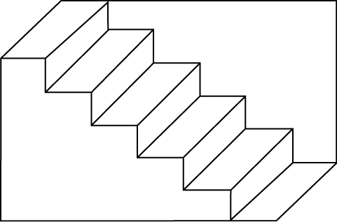

图 1

Figure 1

我们大多数人在初看图1时，都会看到一个楼梯，楼梯的上表面清晰可见。但这并非它唯一的呈现方式。同样，我们也可以轻松地将其视为一个楼梯，楼梯的下表面也清晰可见。此外，如果长时间观察这幅图，通常会发现所见景象会频繁且不由自主地在俯视视角和仰视视角之间切换。然而，由于观察者看到的始终是同一个物体，因此视网膜上的图像应该没有改变。这幅图究竟是呈现为俯视视角还是仰视视角，似乎取决于除观察者视网膜上的图像之外的其他因素。我猜想，本书的读者应该不会质疑我关于图1描绘的是楼梯的论断。然而，对一些非洲部落成员进行的实验结果表明，这些部落的文化中既没有用二维透视图描绘三维物体的习俗，也没有描绘楼梯的习俗，因此他们根本不会把图1视为楼梯。由此可见，个体在视觉过程中获得的感知体验并非完全由视网膜上的图像决定。汉森（1958，第一章）提供了一些更引人入胜的例子来说明这一点。

Most of us, when first looking at Figure 1, see the drawing of a staircase with the upper surface of the stairs visible. But this is not the only way in which it can be seen. It can without difficulty be seen as a staircase with the under surface of the stairs visible. Further, if one looks at the picture for some time, one generally finds that what one sees changes frequently, and involuntarily, from a staircase viewed from above to one viewed from below and back again. And yet it seems reasonable to suppose that, since it remains the same object viewed by the observer, the retinal images do not change. Whether the picture is seen as a staircase viewed from above or one viewed from below seems to depend on something other than the image on the retina of the viewer. I suspect that no reader of this book has questioned my claim that Figure 1 depicts a staircase. However, the results of experiments on members of African tribes whose culture does not include the custom of depicting three-dimensional objects by two-dimensional perspective drawings, nor staircases for that matter, indicate that members of those tribes would not see Figure 1 as a staircase at all. Again, it seems to follow that the perceptual experiences that individuals have in the act of seeing are not uniquely determined by the images on their retinas. Hanson (1958, chapter 1) contains some more captivating examples that illustrate this point.

另一个例子是儿童拼图游戏，游戏要求在一棵树的树叶图案中找出人脸。首先，观看者看到的，也就是他们主观感受到的，是一棵树，有树干、树枝和树叶。但一旦发现了人脸，情况就发生了变化。原本看到的树枝和树叶变成了人脸。同样，在解谜前后看到的都是同一个物体，而且可以推测，在解谜找到人脸的那一刻，观察者视网膜上的图像并没有改变。如果之后再看这幅画，已经解过一次谜题的观察者也能很快地看到人脸。看来，观察者的所见确实会受到其过往经验的影响。

Another instance is provided by a children’s picture puzzle that involves finding the drawing of a human face among the foliage in the drawing of a tree. Here, what is seen, that is, the subjective impressions experienced by a person viewing the drawing, at first corresponds to a tree, with trunk, branches and leaves. But this changes once the human face has been detected. What was once seen as branches and leaves is now seen as a human face. Again, the same physical object is viewed before and after the solution of the puzzle, and presumably the image on the observer’s retina does not change at the moment the puzzle is solved and the face found. If the picture is viewed at some later time, the face is readily and quickly seen by an observer who has already solved the puzzle once. It would seem that there is a sense in which what an observer sees is affected by his or her past experience.

有人可能会问：“这些人为的例子跟科学有什么关系？”对此，我们很容易就能从科学实践中找到例子来说明同样的观点，即观察者在观察物体或场景时所看到的、他们所经历的主观体验，并非仅仅由视网膜上的图像决定，还取决于观察者的经验、知识和预期。这一点隐含在一个不言而喻的认知中：在科学领域，人们必须学习如何成为一名合格的观察者。任何有过学习使用显微镜观察经历的人对此都深有体会。当初学者通过显微镜观察老师制作的玻片时，即使老师在同一台显微镜下观察同一张玻片时能够轻松辨认出相应的细胞结构，初学者也很难做到这一点。值得注意的是，在此背景下，显微镜学家一旦意识到应该观察什么，便能在适当的条件下观察到细胞分裂，而在此发现之前，这些细胞分裂过程却未被观察到。尽管我们现在知道，在许多通过显微镜观察的样本中，这些细胞分裂必然存在。迈克尔·波兰尼（Michael Polanyi，1973，第101页）描述了一名医学生在学习如何通过观察X光片进行诊断时，其感知体验的变化。

‘What’, it might well be suggested, ‘have these contrived examples got to do with science?’ In response, it is not difficult to produce examples from the practice of science that illustrate the same point, namely, that what observers see, the subjective experiences that they undergo, when viewing an object or scene is not determined solely by the images on their retinas but depends also on the experience, knowledge and expectations of the observer. The point is implicit in the uncontroversial realisation that one has to learn to be a competent observer in science. Anyone who has been through the experience of having to learn to see through a microscope will need no convincing of this. When the beginner looks at a slide prepared by an instructor through a microscope it is rare that the appropriate cell structures can be discerned, even though the instructor has no difficulty discerning them when looking at the same slide through the same microscope. It is significant to note, in this context, that microscopists found no great difficulty observing cells divide in suitably prepared circumstances once they were alert for what to look for, whereas prior to this discovery these cell divisions went unobserved, although we now know they must have been there to be observed in many of the samples examined through a microscope. Michael Polanyi (1973, p. 101) describes the changes in a medical student’s perceptual experience when he is taught to make a diagnosis by inspecting an X-ray picture.

想象一下，一位医学生正在学习肺部疾病的X光诊断课程。在昏暗的房间里，他看着贴在病人胸口的荧光屏上投射出的阴影，听着放射科医生用专业术语向助手们讲解这些阴影的重要特征。起初，这位学生完全摸不着头脑。因为他只能在胸部X光片上看到心脏和肋骨的阴影，以及它们之间零星的蛛网状斑点。专家们似乎在谈论他们想象中的事物；他根本看不懂他们在说什么。然而，几周后，他继续听讲，仔细观察着不断更新的不同病例的X光片，渐渐地，他开始有所领悟；他逐渐忘记了肋骨，开始看到肺部。最终，如果他坚持不懈地学习，一幅包含丰富细节的全景图将展现在他面前：生理变异和病理变化、瘢痕、慢性感染和急性疾病的迹象。他进入了一个全新的世界。他仍然只能看到专家们所看到内容的一小部分，但现在这些图片确实变得有意义了，而且大多数对图片的评论也变得有意义了。

Think of a medical student attending a course in the X-ray diagnosis of pulmonary diseases. He watches, in a darkened room, shadowy traces on a fluorescent screen placed against a patient’s chest, and hears the radiologist commenting to his assistants, in technical language, on the significant features of these shadows. At first, the student is completely puzzled. For he can see in the X-ray picture of a chest only the shadows of the heart and ribs, with a few spidery blotches between them. The experts seem to be romancing about figments of their imagination; he can see nothing that they are talking about. Then, as he goes on listening for a few weeks, looking carefully at ever-new pictures of different cases, a tentative understanding will dawn on him; he will gradually forget about the ribs and begin to see the lungs. And eventually, if he perseveres intelligently, a rich panorama of significant details will be revealed to him; of physiological variations and pathological changes, of scars, of chronic infections and signs of acute disease. He has entered a new world. He still sees only a fraction of what the experts can see, but the pictures are definitely making sense now and so do most of the comments made on them.

经验丰富的观察者和未经训练的新手在面对相同情境时，其感知体验并不相同。这与“感知是通过感官直接传递的”这一论断的字面理解相悖。

The experienced and skilled observer does not have perceptual experiences identical to those of the untrained novice when the two confront the same situation. This clashes with a literal understanding of the claim that perceptions are given in a straightforward way via the senses.

针对我提出的关于观察的观点，以及我所举的例子，一种常见的反驳是：观察者从同一地点观察同一场景，看到的是同一事物，但对所见之物的解读却各不相同。我对此持不同意见。就感知而言，观察者唯一能直接且即时接触的事物是其自身的经验。这些经验并非一成不变、独一无二，而是会随着观察者的知识和预期而变化。我承认，物理情境独有的，是观察者视网膜上的图像，但观察者与该图像之间并无直接的感知联系。当那些拥护普遍观点的人假定感知中存在某种独有的、可以被多种方式解读的东西时，他们实际上是在不加论证地假定，视网膜上的图像能够唯一地决定我们的感知经验，尽管有大量证据与之相悖。他们过度解读了相机的比喻。

A common response to the claim that I am making about observation, supported by the kinds of examples I have utilised, is that observers viewing the same scene from the same place see the same thing but interpret what they see differently. I wish to dispute this. As far as perception is concerned, the only things with which an observer has direct and immediate contact are his or her experiences. These experiences are not uniquely given and unchanging but vary with the knowledge and expectations possessed by the observer. What is uniquely given by the physical situation, I am prepared to admit, is the image on the retina of an observer, but an observer does not have direct perceptual contact with that image. When defenders of the common view assume that there is something unique given to us in perception that can be interpreted in various ways, they are assuming without argument, and in spite of much evidence to the contrary, that the images on our retinas uniquely determine out perceptual experiences. They are taking the camera analogy too far.

说了这么多，我想先澄清一下本节中我并非意在提出什么论点，以免被误解为论证超出我本意。首先，我当然不是说视网膜上图像的物理成因与我们所见毫无关系。我们不可能只看到自己想看到的东西。然而，尽管视网膜上的图像是造成我们所见之物的部分原因，但另一个非常重要的成因是我们内心或大脑的状态，而这种状态本身取决于我们的文化背景、知识水平和预期，并非仅仅由我们眼睛的物理特性和所观察的场景决定。其次，在各种情况下，我们所见之物都相当稳定。我们所见之物对内心或大脑状态的依赖程度并不高，不会使交流和科学研究变得不可能。第三，在本文引用的所有例子中，某种程度上所有观察者看到的都是同一件事。本书始终秉持并预设一个单一的、独特的物理世界独立于观察者而存在。因此，当多个观察者观察一幅图片、一件仪器、一张显微镜载玻片或其他任何事物时，在某种意义上，他们面对、观察并因此看到的是同一事物。但这并不意味着他们拥有完全相同的感知体验。在非常重要的意义上，他们看到的并非同一事物，而正是基于后一种意义，我对“事实能够毫无问题地、直接地通过感官传递给观察者”这一观点提出了一些质疑。至于这在多大程度上动摇了“足以用于科学研究的事实可以通过感官确立”这一观点，还有待进一步探讨。

Having said all this, let me try to make clear what I do not mean to be claiming in this section, lest I be taken to be arguing for more than I intend to be. First, I am certainly not claiming that the physical causes of the images on our retinas have nothing to do with what we see. We cannot see just what we like. However, although the images on our retinas form part of the cause of what we see, another very important part of the cause is the inner state of our minds or brains, which will itself depend on our cultural upbringing, our knowledge and our expectations, and will not be determined solely by the physical properties of our eyes and the scene observed. Second, under a wide variety of circumstances, what we see in various situations remains fairly stable. The dependence of what we see on the state of our minds or brains is not so sensitive as to make communication, and science, impossible. Third, in all the examples quoted here, there is a sense in which all observers see the same thing. I accept and presuppose throughout this book that a single, unique, physical world exists independently of observers. Hence, when a number of observers look at a picture, a piece of apparatus, a microscope slide or whatever, there is a sense in which they are confronted by, look at, and hence see, the same thing. But it does not follow from this that they have identical perceptual experiences. There is a very important sense in which they do not see the same thing, and it is that latter sense on which I base some of my queries concerning the view that facts are unproblematically and directly given to observers through the senses. To what extent this undermines the view that facts adequate for science can be established by the senses remains to be seen.

以陈述形式表达的可观察事实

Observable facts expressed as statements

在日常语言使用中，“事实”一词的含义是模糊的。它可以指表达事实的陈述，也可以指该陈述所描述的状态。例如，“月球上有山脉和陨石坑”是一个事实。这里的“事实”既可以理解为山脉或陨石坑本身，也可以理解为“月球上有山脉和陨石坑”这一陈述构成了事实。当人们声称科学建立在事实之上并从中推导而来时，显然后一种解释更为恰当。关于月球表面的知识并非建立在山脉和陨石坑之上并从中推导而来，而是建立在关于山脉和陨石坑的事实性陈述之上。

In normal linguistic usage, the meaning of ‘fact’ is ambiguous. It can refer to a statement that expresses the fact and it can also refer to the state of affairs referred to by such a statement. For example, it is a fact that there are mountains and craters on the moon. Here the fact can be taken as referring to the mountains or craters themselves. Alternatively, the statement ‘there are mountains and craters on the moon’ can be taken as constituting the fact. When it is claimed that science is based on and derived from the facts, it is clearly the latter interpretation that is appropriate. Knowledge about the moon’s surface is not based on and derived from mountains and craters but from factual statements about mountains and craters.

除了区分事实（理解为陈述）与这些陈述所描述的事物状态之外，显然也有必要区分事实陈述与可能导致人们接受这些陈述为事实的感知。例如，毫无疑问，达尔文在著名的“贝格尔号”航行中遇到了许多新的动植物物种，因此经历了一系列新的感知体验。然而，如果他止步于此，他对科学的贡献将微乎其微。只有当他将这些新发现形成陈述并提供给其他科学家时，他才对生物学做出了重大贡献。如果说“贝格尔号”航行产生了可以与进化论相关的新事实，那么构成这些事实的正是这些陈述。那些声称知识来源于事实的人，他们心中想的必然是陈述，而不是感知，也不是山脉和陨石坑之类的物体。

As well as distinguishing facts, understood as statements, from the states of affairs described by those statements, it is also clearly necessary to distinguish statements of facts from the perceptions that might occasion the acceptance of those statements as facts. For example, it is undoubtedly the case that when Darwin underwent his famous voyage on the Beagle he encountered many novel species of plant and animal, and so was subject to a range of novel perceptual experiences. However, he would have made no significant contribution to science had he left it at that. It was only when he had formulated statements describing the novelties and made them available to other scientists that he made a significant contribution to biology. To the extent that the voyage on the Beagle yielded novel facts to which an evolutionary theory could be related, it was statements that constituted those facts. For those who wish to claim that knowledge is derived from facts, they must have statements in mind, and neither perceptions nor objects like mountains and craters.

澄清了这一点之后，让我们回到本章第一节结尾处关于事实本质的论断(a)至(c)。一旦回到这些论断，它们本身就立刻显得问题重重。鉴于构成科学基础的事实必须以陈述的形式出现，那么认为事实是通过感官直接传递的说法就显得十分荒谬。即使我们暂且搁置上一节中提到的种种困难，并假设感知是在视觉行为中直接传递的，但显然，描述可观察事物状态的陈述（我称之为观察陈述）并非通过感官传递给观察者。认为事实陈述是通过感官进入大脑的想法是荒谬的。

With this clarification behind us, let us return to the claims (a) to (c) about the nature of facts which concluded the first section of this chapter. Once we do so they immediately become highly problematic as they stand. Given that the facts that might constitute a suitable basis for science must be in the form of statements, the claim that facts are given in a straightforward way via the senses begins to look quite misconceived. For even if we set aside the difficulties highlighted in the previous section, and assume that perceptions are straightforwardly given in the act of seeing, it is clearly not the case that statements describing observable states of affairs (I will call them observation statements) are given to observers via the senses. It is absurd to think that statements of fact enter the brain by way of the senses.

观察者在形成并认同观察陈述之前，必须具备相应的概念框架，并了解如何恰当地运用该框架。这一点在我们思考儿童学习描述（即对世界做出事实陈述）世界的方式时便显而易见。试想一下，一位家长教孩子认识和描述苹果。家长向孩子展示一个苹果，指着它，并说出“苹果”这个词。孩子很快就学会模仿并重复“苹果”这个词。掌握了这项技能后，也许有一天，孩子遇到了兄弟姐妹的网球，指着它说“苹果”。这时，家长会介入并解释说网球不是苹果，例如，演示网球不能像苹果一样咬。如果孩子再次犯错，例如把佛手瓜认作苹果，家长就需要更详细的解释。当孩子能够准确地说出“这里有个苹果”时，他/她已经对苹果有了相当多的了解。因此，认为我们必须先观察苹果的客观事实才能从中得出关于苹果的知识，这种想法似乎是错误的，因为恰当的客观事实，以陈述的形式表达出来，本身就预设了我们对苹果的大量了解。

Before an observer can formulate and assent to an observation statement, he or she must be in possession of the appropriate conceptual framework and a knowledge of how to appropriately apply it. That this is so becomes clear when we contemplate the way in which a child learns to describe (that is, make factual statements about) the world. Think of a parent teaching a child to recognise and describe apples. The parent shows the child an apple, points to it, and utters the word ‘apple’. The child soon learns to repeat the word ‘apple’ in imitation. Having mastered this particular accomplishment, perhaps on a later day the child encounters its sibling’s tennis ball, points and says ‘apple’. At this point the parent intervenes to explain that the ball is not an apple, demonstrating, for example, that one cannot bite it like an apple. Further mistakes by the child, such as the identification of a choko as an apple, will require somewhat more elaborate explanations from the parent. By the time the child can successfully say there is an apple present when there is one, it has learnt quite a lot about apples. So it would seem that it is a mistake to presume that we must first observe the facts about apples before deriving knowledge about them from those facts, because the appropriate facts, formulated as statements, presuppose quite a lot of knowledge about apples.

让我们从谈论儿童转向一些与我们理解科学更相关的例子。想象一下，一位经验丰富的植物学家和像我这样对植物学知之甚少的人一起参加一次澳大利亚丛林实地考察，目的是收集关于当地植物的可观察事实。毫无疑问，这位植物学家能够收集到比我观察和总结的更多、更详尽的事实，原因显而易见。植物学家拥有比我更完善的概念框架，这是因为他/她比我了解更多的植物学知识。植物学知识是形成观察陈述的前提，而这些陈述可能构成观察陈述的事实基础。

Let us move from talk of children to some examples that are more relevant to our task of understanding science. Imagine a skilled botanist accompanied by someone like myself who is largely ignorant of botany taking part in a field trip into the Australian bush, with the objective of collecting observable facts about the native flora. It is undoubtedly the case that the botanist will be capable of collecting facts that are far more numerous and discerning than those I am able to observe and formulate, and the reason is clear. The botanist has a more elaborate conceptual scheme to exploit than myself, and that is because he or she knows more botany than I do. A knowledge of botany is a prerequisite for the formulation of the observation statements that might constitute its factual basis.

因此，记录可观察的事实不仅仅是接收照射到眼睛的光线刺激，它还需要掌握相应的概念框架以及如何运用它。从这个意义上讲，假设（a）和（b）不能直接接受。事实陈述并非由感官刺激直接决定，观察陈述也预设了知识，因此我们不可能先确定事实，然后从中推导出知识。

Thus, the recording of observable facts requires more than the reception of the stimuli, in the form of light rays, that impinge on the eye. It requires the knowledge of the appropriate conceptual scheme and how to apply it. In this sense, assumptions (a) and (b) cannot be accepted as they stand. Statements of fact are not determined in a straightforward way by sensual stimuli, and observation statements presuppose knowledge, so it cannot be the case that we first establish the facts and then derive our knowledge from them.

为什么事实应该先于理论？

Why should facts precede theory?

我以一种相当极端的解读作为出发点，来理解“科学源于事实”这一论断。我认为它意味着，必须先确立事实，才能从中推导出科学知识。先确立事实，再构建理论来与之相符。然而，我们的感知在某种程度上依赖于我们已有的知识，进而依赖于我们的准备状态和预期（本章前面已讨论过），而且观察陈述本身也预设了相应的概念框架（上一节已讨论过），这些都表明，这种要求根本无法实现。事实上，一旦仔细审视，就会发现这是一个相当荒谬的想法，荒谬到我怀疑任何严肃的科学哲学家都不会愿意为之辩护。如果我们对所寻求的知识类型或试图解决的问题没有任何指导，又如何通过观察来确立关于世界的重要事实呢？为了做出可能对植物学做出重大贡献的观察，我首先需要掌握大量的植物学知识。此外，如果严格意义上的科学要求相关事实必须始终先于可能由其支撑的知识，那么用可观察的事实来检验我们科学知识的充分性这一理念本身就毫无意义。我们对相关事实的探寻需要以我们现有的知识水平为指导，例如，测量大气中不同位置的臭氧浓度可以获得相关事实，而测量悉尼青少年的平均头发长度则不能。因此，让我们放弃“获取事实必须先于构建构成科学知识的定律和理论”这一要求，看看我们这样做之后还能保留多少关于科学以事实为基础的理念。

I have taken as my starting point a rather extreme interpretation of the claim that science is derived from the facts. I have taken it to imply that the facts must be established prior to the derivation of scientific knowledge from them. First establish the facts and then build your theory to fit them. Both the fact that our perceptions depend to some extent on our prior knowledge and hence on our state of preparedness and our expectations (discussed earlier in the chapter) and the fact that observation statements presuppose the appropriate conceptual framework (discussed in the previous section) indicate that it is a demand that is impossible to live up to. Indeed, once it is subject to a close inspection it is a rather silly idea, so silly that I doubt if any serious philosopher of science would wish to defend it. How can we establish significant facts about the world through observation if we do not have some guidance as to what kind of knowledge we are seeking or what problems we are trying to solve? In order to make observations that might make a significant contribution to botany, I need to know much botany to start with. What is more, the very idea that the adequacy of our scientific knowledge should be tested against the observable facts would make no sense if, in proper science, the relevant facts must always precede the knowledge that might be supported by them. Our search for relevant facts needs to be guided by our current state of knowledge, which tells us, for example, that measuring the ozone concentration at various locations in the atmosphere yields relevant facts, whereas measuring the average hair length of the youths in Sydney does not. So let us drop the demand that the acquisition of facts should come before the formulation of the laws and theories that constitute scientific knowledge, and see what we can salvage of the idea that science is based on facts once we have done so.

根据我们修正后的立场，我们坦诚地承认，观察性陈述的形成预设了重要的知识基础，而科学中对相关可观察事实的探寻也正是以这些知识为指导。这两种承认并不必然削弱“知识具有由观察确立的事实基础”这一论断。首先，让我们来探讨一下，重要的观察性陈述的形成预设了对适当概念框架的了解。在此，我们注意到，拥有形成观察性陈述所需的概念资源是一回事，而这些陈述的真假则是另一回事。翻阅我的固体物理教科书，我可以摘录出两个观察性陈述：“金刚石的晶体结构具有反演对称性”和“在硫化锌晶体中，每个晶胞包含四个分子”。要形成和理解这些陈述，就必须具备一定的晶体结构知识及其表征方法。即使你不具备这些知识，你也能意识到，还有其他类似的陈述可以用相同的术语表达出来，例如“金刚石的晶体结构不具有反演对称性”和“硫化锌晶体的每个晶胞包含六个分子”。所有这些陈述都是观察性陈述，因为一旦掌握了相应的观察技巧，就可以通过观察来验证它们的真假。这样做之后，只有我从教科书中提取的陈述得到了观察的证实，而由这些陈述构建的其他陈述则被驳斥了。这说明，尽管知识对于构建重要的观察性陈述是必要的，但仍然无法确定哪些陈述能够被观察证实，哪些不能。因此，即使认识到描述这些事实的陈述依赖于知识，知识应该基于被观察证实的事实这一观点也并不会因此而动摇。只有当人们坚持认为，在获取任何知识之前，必须先确认与某些知识体系相关的事实时，才会出现问题。

According to our modified stand, we freely acknowledge that the formulation of observation statements presupposes significant knowledge, and that the search for relevant observable facts in science is guided by that knowledge. Neither acknowledgment necessarily undermines the claim that knowledge has a factual basis established by observation. Let us first take the point that the formulation of significant observation statements presupposes knowledge of the appropriate conceptual framework. Here we note that the availability of the conceptual resources for formulating observation statements is one thing. The truth or falsity of those statements is another. Looking at my solid state physics textbook, I can extract two observation statements, ‘the crystal structure of diamond has inversion symmetry’ and ‘in a crystal of zinc sulphide there are four molecules per unit cell’. A degree of knowledge about crystal structures and how they are characterised is necessary for the formulation and understanding of these statements. But even if you do not have that knowledge, you will be able to recognise that there are other, similar, statements that can be formulated using the same terms, statements such as ‘the crystal structure of diamond does not have inversion symmetry’ and ‘the crystal of zinc sulphide has six molecules per unit cell’. All of these statements are observation statements in the sense that once one has mastered the appropriate observational techniques their truth or falsity can be established by observation. When this is done, only the statements I extracted from my textbook are confirmed by observation, while the alternatives constructed from them are refuted. This illustrates the point that the fact that knowledge is necessary for the formulation of significant observation statements still leaves open the question of which of the statements so formulated are borne out by observation and which are not. Consequently, the idea that knowledge should be based on facts that are confirmed by observation is not undermined by the recognition that the formulation of the statements describing those facts are knowledge-dependent. There is only a problem if one sticks to the silly demand that the confirmation of facts relevant to some body of knowledge should precede the acquisition of any knowledge.

因此，即使承认寻找和阐述这些事实本身依赖于知识，科学知识应当建立在观察所确立的事实之上的这一观点也并非不成立。如果观察陈述的真假能够通过观察直接确定，那么，无论这些陈述是如何形成的，以这种方式得到证实的观察陈述似乎都能为科学知识提供重要的事实基础。

The idea that scientific knowledge should be based on facts established by observation need not be undermined, then, by the acknowledgment that the search for and formulation of those facts are knowledge-dependent. If the truth or falsity of observation statements can be established in a direct way by observation, then, irrespective of the way in which those statements came to be formulated, it would seem that the observation statements confirmed in this way provide us with a significant factual basis for scientific knowledge.

观察陈述的可靠性

The fallibility of observation statements

我们在探寻科学观测基础的本质方面取得了一些进展，但仍面临诸多挑战。前文的分析预设了观测陈述的真伪可以通过观测以一种毫无问题的方式得到可靠验证。然而，这样的预设是否合理呢？我们已经看到，不同的观测者在观察同一场景时未必拥有相同的感知，这会导致对可观测状态的认知出现分歧，从而引发诸多问题。科学史上的诸多案例充分证明了这一点的重要性，例如奈伊（Nye，1980）描述的关于所谓N射线效应是否可观测的争论，以及埃奇和穆尔凯（Edge and Mulkay，1976）描述的悉尼和剑桥天文学家在射电天文学早期对可观测事实的争论。我们至今尚未充分阐述如何在这些困难面前建立可靠的科学观测基础。关于科学观测基础可靠性的其他困难，源于我们对观测陈述是否充分的判断，而这种判断方式依赖于预设的知识，这使得这些判断本身就可能出错。我将举例说明这一点。

We have made some headway in our search for a characterisation of the observational base of science, but we are not out of trouble yet. In the previous section our analysis presupposed that the truth or otherwise of observation statements can be securely established by observation in an unproblematic way. But is such a presupposition legitimate? We have already seen ways in which problems can arise from the fact that different observers do not necessarily have the same perceptions when viewing the same scene, and this can lead to disagreements about what the observable states of affairs are. The significance of this point for science is borne out by well-documented cases in the history of science, such as the dispute about whether or not the effects of so-called N-rays are observable, described by Nye (1980), and the disagreement between Sydney and Cambridge astronomers over what the observable facts were in the early years of radio astronomy, as described by Edge and Mulkay (1976). We have as yet said little to show how a secure observational basis for science can be established in the face of such difficulties. Further difficulties concerning the reliability of the observational basis of science arise from some of the ways in which judgments about the adequacy of observation statements draw on presupposed knowledge in a way that renders those judgments fallible. I will illustrate this with examples.

亚里士多德将火列入构成所有地球物体的四大元素之一。火是一种独特的物质（尽管非常轻）的假设持续了数百年，直到现代化学才彻底推翻了它。那些基于这种预设进行研究的人认为，当他们观察火焰升腾时，就等于直接观察了火本身，因此对他们来说，“火上升了”这一观察陈述常常能被直接观察所证实。而我们现在摒弃了这种观察陈述。关键在于，如果我们用来描述观察结果的范畴所依据的知识本身存在缺陷，那么预设这些范畴的观察陈述也同样存在缺陷。

Aristotle included fire among the four elements of which all terrestrial objects are made. The assumption that fire is a distinctive substance, albeit a very light one, persisted for hundreds of years, and it took modern chemistry to thoroughly undermine it. Those who worked with this presupposition considered themselves to be observing fire directly when watching flames rise into the air, so that for them ‘the fire ascended’ is an observation statement that was frequently borne out by direct observation. We now reject such observation statements. The point is that if the knowledge that provides the categories we use to describe our observations is defective, the observation statements that presuppose those categories are similarly defective.

我的第二个例子是关于十六、十七世纪人们认识到的地球运动——它自转并绕太阳公转。在人们认识到这一点之前，“地球静止不动”的说法可以说是已被观察证实的。毕竟，我们既看不到也感觉不到地球的运动，而且如果我们跳到空中，地球也不会在我们脚下旋转。然而，从现代视角来看，尽管表面看来如此，我们仍然知道上述观察结论是错误的。我们理解惯性，也知道如果我们因为地球自转而以超过每秒一百米的速度水平运动，那么当我们跳到空中时，这个速度并没有改变。改变速度需要外力，而在我们的例子中，并没有水平方向的力作用于我们。因此，我们保持着与地球表面共享的水平速度，并落在我们起跳的地方。“地球静止不动”的说法并没有像人们曾经认为的那样，被可观察的证据所证实。但要充分理解个中缘由，我们需要了解惯性。这种理解是十七世纪的一项创新。我们有一个例子可以说明，对观察陈述的真假判断取决于构成判断背景的知识。看来，科学革命不仅涉及科学理论的渐进式变革，也涉及对可观察事实的认知变革！

My second example concerns the realisation, established in the sixteenth and seventeenth centuries, that the earth moves, spinning on its axis and orbiting the sun. Prior to the circumstances that made this realisation possible, it can be said that the statement ‘the earth is stationary’ was a fact confirmed by observation. After all, one cannot see or feel it move, and if we jump in the air, the earth does not spin away beneath us. We, from a modern perspective, know that the observation statement in question is false in spite of these appearances. We understand inertia, and know that if we are moving in a horizontal direction at over one hundred metres per second because the earth is spinning, there is no reason why that should change when we jump in the air. It takes a force to change speed, and, in our example, there are no horizontal forces acting. So we retain the horizontal speed we share with the earth’s surface and land where we took off. ‘The earth is stationary’ is not established by the observable evidence in the way it was once thought to be. But to fully appreciate why this is so, we need to understand inertia. That understanding was a seventeenth-century innovation. We have an example that illustrates a way in which the judgment of the truth or otherwise of an observation statement depends on the knowledge that forms the background against which the judgment is made. It would seem that the scientific revolution involved not just a progressive transformation of scientific theory, but also a transformation in what were considered to be the observable facts!

我的第三个例子进一步说明了最后一点。这个例子涉及从地球上观测到的金星和火星在一年中的大小变化。哥白尼认为地球绕太阳公转，其轨道位于金星轨道之外、火星轨道之内，因此金星和火星的视大小在一年中会发生显著变化。这是因为当地球位于太阳的同一侧时，它与其中一颗行星的距离相对较近；而当地球位于太阳的另一侧时，它与其中一颗行星的距离相对较远。如果从定量角度来考虑这个问题（正如哥白尼自己的理论版本中所述），这种影响是相当大的，火星的视直径预计会变化约八倍，金星的视直径预计会变化约六倍。然而，当用肉眼仔细观察行星时，金星的大小并没有变化，火星的大小变化也不超过两倍。因此，“金星的视大小在一年中不会发生变化”这一观测结果得到了直接证实，并在哥白尼的《天体运行论》序言中被提及，作为“历代经验”所证实的事实（邓肯，1976，第22页）。该序言的作者奥西安德对哥白尼理论的推论与我们“可观测事实”之间的冲突印象深刻，并以此论证哥白尼理论不应被字面理解。我们现在知道，用肉眼观测行星大小是具有欺骗性的，而且在黑暗背景下，人眼对于测量微小光源的大小是非常不可靠的。但正是伽利略指出了这一点，并证明如果通过望远镜观测金星和火星，就能清晰地辨别出预测的大小变化。这清晰地展现了知识和技术进步如何纠正了关于可观测事实的错误认知。这个例子本身并不特别，也并不神秘。但它表明，任何认为科学知识建立在观测所得事实之上的观点，都必须承认事实和知识本身都可能出错，需要修正；而且科学知识与其所依据的事实是相互依存的。

This last point is further illustrated by my third example. It concerns the sizes of the planets Venus and Mars as viewed from earth during the course of the year. It is a consequence of Copernicus’s suggestion that the earth circulates the sun, in an orbit outside that of Venus and inside that of Mars, that the apparent size of both Venus and Mars should change appreciably during the course of the year. This is because when the earth is around the same side of the sun as one of those planets it is relatively close to it, whereas when it is on the opposite side of the sun to one of them it is relatively distant from it. When the matter is considered quantitatively, as it can be within Copernicus’s own version of his theory, the effect is a sizeable one, with a predicted change in apparent diameter by a factor of about eight in the case of Mars and about six in the case of Venus. However, when the planets are observed carefully with the naked eye, no change in size can be detected for Venus, and Mars changes in size by no more than a factor of two. So the observation statement ‘the apparent size of Venus does not change size during the course of the year’ was straightforwardly confirmed, and was referred to in the Preface to Copernicus’s On the Revolutions of the Heavenly Spheres as a fact confirmed ‘by all the experience of the ages’ (Duncan, 1976, p. 22). Osiander, who was the author of the Preface in question, was so impressed by the clash between the consequences of the Copernican theory and our ‘observable fact’ that he used it to argue that the Copernican theory should not be taken literally. We now know that the naked-eye observations of planetary sizes are deceptive, and that the eye is a very unreliable device for gauging the size of small light sources against a dark background. But it took Galileo to point this out and to show how the predicted change in size can be clearly discerned if Venus and Mars are viewed through a telescope. Here we have a clear example of the correction of a mistake about the observable facts made possible by improved knowledge and technology. In itself the example is unremarkable and non-mysterious. But it does show that any view to the effect that scientific knowledge is based on the facts acquired by observation must allow that the facts as well as the knowledge are fallible and subject to correction and that scientific knowledge and the facts on which it might be said to be based are interdependent.

我原本想用“科学源于事实”这句口号来表达的直觉是：科学知识之所以具有特殊地位，部分原因在于它建立在坚实的基础之上，即通过观察而确立的可靠事实。然而，本章的一些思考却对这种安心的观点构成了挑战。其中一个难题在于，观察者的认知在多大程度上受到其背景和预期的影响，因此，对一个人而言的可观察事实，对另一个人而言未必如此。第二个难题则源于，对观察陈述真伪的判断在多大程度上取决于已知的或预设的前提，这使得可观察的事实与支撑这些事实的前提一样，都可能出错。这两种难题都表明，科学的可观察基础或许并不像人们普遍认为的那样简单可靠。在下一章中，我将尝试通过更深入地探讨观察的本质，尤其是在科学领域中的运用，来在一定程度上缓解这些担忧。

The intuition that I intended to capture with my slogan ‘science is derived from the facts’ was that scientific knowledge has a special status in part because it is founded on a secure basis, solid facts firmly established by observation. Some of the considerations of this chapter pose a threat to this comfortable view. One difficulty concerns the extent to which perceptions are influenced by the background and expectations of the observer, so that what appears to be an observable fact for one need not be for another. The second source of difficulty stems from the extent to which judgments about the truth of observation statements depend on what is already known or assumed, thus rendering the observable facts as fallible as the presuppositions underlying them. Both kinds of difficulty suggest that maybe the observable basis for science is not as straightforward and secure as is widely and traditionally supposed. In the next chapter I try to mitigate these fears to some extent by considering the nature of observation, especially as it is employed in science, in a more discerning way than has been involved in our discussion up until now.

延伸阅读

Further reading

关于经验主义者如何看待知识，认为知识来源于感官所感知的信息，可参见洛克（1967）；关于逻辑实证主义者如何看待知识，可参见艾耶尔（1940）。汉弗林（1981）对逻辑实证主义进行了总体介绍，包括其对科学观察基础的论述。汉森（1958，第一章）在感知层面对这些观点提出了挑战。布朗（1977）和巴恩斯、布洛尔和亨利（1996，第一至三章）对整个问题进行了有益的讨论。

For a classic discussion of how knowledge is seen by an empiricist as derived from what is delivered to the mind via the senses, see Locke (1967), and by a logical positivist, see Ayer (1940). Hanfling (1981) is an introduction to logical positivism generally, including its account of the observational basis of science. A challenge to these views at the level of perception is Hanson (1958, chapter 1). Useful discussions of the whole issue are to be found in Brown (1977) and Barnes, Bloor and Henry (1996, chapters 1–3).

第二章

CHAPTER 2

观察作为一种实际干预手段

Observation as practical intervention

观察：被动且私密，还是主动且公开？

Observation: passive and private or active and public?

许多哲学家对观察的常见理解是将其视为一种被动的、私人的行为。之所以说它是被动的，是因为人们假定，例如，当我们观看时，我们只是睁开眼睛，调整视线，让信息流入，然后记录所看到的东西。正是观察者头脑或大脑中的感知本身，直接验证了事实，例如“我面前有一个红番茄”。如果这样理解，那么可观察事实的确立就成了一件非常私人的事情。它是通过个人在感知过程中仔细关注呈现在眼前的内容而完成的。由于两个观察者无法了解彼此的感知，他们就无法就各自假定确立的事实的有效性展开对话。

A common way in which observation is understood by a range of philosophers is to see it as a passive, private affair. It is passive insofar as it is presumed that when seeing, for example, we simply open and direct our eyes, let the information flow in, and record what is there to be seen. It is the perception itself in the mind or brain of the observer that is taken to directly validate the fact, which may be ‘there is a red tomato in front of me’ for example. If it is understood in this way, then the establishment of observable facts is a very private affair. It is accomplished by the individual closely attending to what is presented to him or her in the act of perception. Since two observers do not have access to each other’s perceptions, there is no way they can enter into a dialogue about the validity of the facts they are presumed to establish.

这种将感知或观察视为被动和私密的观点完全不充分，无法准确解释日常生活中的感知，更遑论科学领域。日常观察远非被动。为了验证感知的有效性，人们会采取一系列行动，其中许多行动是自动的，甚至可能是无意识的。在观察的过程中，我们会扫描物体，移动头部来检验所观察场景中预期的变化等等。如果我们不确定透过窗户看到的景象是窗外的景象还是窗户上的倒影，我们可以移动头部来检查这会对景象的可见方向产生什么影响。总的来说，如果我们出于任何原因怀疑基于感知得出的结论的真实性，我们可以采取各种措施来消除疑虑。例如，如果我们有理由怀疑番茄的图像是某种巧妙设计的光学图像，而不是真正的番茄，我们可以触摸它，也可以观察它，如有必要，我们还可以品尝它或解剖它。

This view of perception or observation, as passive and private, is totally inadequate, and does not give an accurate account of perception in everyday life, let alone science. Everyday observation is far from passive. There is a range of things that are done, many of them automatically and perhaps unconsciously, to establish the validity of a perception. In the act of seeing we scan objects, move our heads to test for expected changes in the observed scene and so on. If we are not sure whether a scene viewed through a window is something out of the window or a reflection in the window, we can move our heads to check for the effect this has on the direction in which the scene is visible. It is a general point that if for any reason we doubt the validity of what seems to be the case on the basis of our perceptions, there are various actions we can take to remove the problem. If, in the example above, we have reason to suspect that the image of the tomato is some cleverly contrived optical image rather than a real tomato, we can touch it as well as look at it, and if necessary we can taste it or dissect it.

通过这些略显粗浅的观察，我仅仅触及了心理学家能够讲述的关于个体在感知行为中所做种种活动的详尽故事的冰山一角。对我们而言，更重要的是思考这一点对于观察在科学中的作用有何意义。显微镜在科学中的早期应用就是一个很好的例子。当罗伯特·胡克和亨利·鲍尔等科学家使用显微镜观察苍蝇和蚂蚁等小型昆虫时，他们常常对可观察到的事实产生分歧，至少在最初阶段是如此。胡克将一些分歧的根源追溯到不同的照明方式。他指出，在一种光线下，苍蝇的眼睛看起来像一个布满小孔的网格（顺便一提，这似乎让鲍尔相信事实的确如此），在另一种光线下，它看起来像一个布满圆锥的表面，而在另一种光线下，它又看起来像一个布满金字塔的表面。胡克随后采取了一些实际措施来解决这个问题。他力图通过均匀照射标本来消除眩光和复杂反射造成的虚假信息。他采用的方法是，用蜡烛的光线透过盐水扩散开来照明。他还从不同方向照射标本，以确定哪些特征在这些变化下保持不变。有些昆虫需要用白兰地彻底麻醉，才能使其静止不动且不受损伤。

With these few, somewhat elementary, observations I have only touched the surface of the detailed story psychologists can tell about the range of things that are done by individuals in the act of perception. More important for our task is to consider the significance of the point for the role of observation in science. An example that illustrates my point well is drawn from early uses of the microscope in science. When scientists such as Robert Hooke and Henry Power used the microscope to look at small insects such as flies and ants, they often disagreed about the observable facts, at least initially. Hooke traced the cause of some of the disagreements to different kinds of illumination. He pointed out that the eye of a fly appears like a lattice covered with holes in one kind of light (which, incidentally, seems to have led Power to believe that this was indeed the case), like a surface covered with cones in another and in yet another light like a surface covered with pyramids. Hooke proceeded to make practical interventions designed to clear up the problem. He endeavoured to eliminate spurious information arising from dazzle and complicated reflections by illuminating specimens uniformly. He did this by using for illumination the light of a candle diffused through a solution of brine. He also illuminated his specimens from various directions to determine which features remained invariant under such changes. Some of the insects needed to be thoroughly intoxicated with brandy to render them both motionless and undamaged.

胡克的著作《显微图谱》（1665年）包含许多基于胡克的行动和观察而得出的详细描述和图画。这些成果是公开的，而非私密的。其他人可以对其进行检验、批评和补充。如果苍蝇的复眼在某些光照条件下看起来布满了孔洞，那么仔细观察的观察者就无法有效地评估这种状况。胡克展示了如何检验此类情况下的表象真实性，他所推荐的方法可以由任何有意愿或技能的人执行。最终获得的关于苍蝇复眼结构的观察事实，源于一个积极且公开的过程。

Hooke’s book, Micrographia (1665), contains many detailed descriptions and drawings that resulted from Hooke’s actions and observations. These productions were and are public, not private. They can be checked, criticised and added to by others. If a fly’s eye, in some kinds of illumination, appears to be covered with holes, then that state of affairs cannot be usefully evaluated by the observer closely attending to his or her perceptions. Hooke showed what could be done to check the authenticity of the appearances in such cases, and the procedures he recommended could be carried out by anyone suitably inclined or skilled. The observable facts about the structure of a fly’s eye that eventuate result from a process that is both active and public.

采取行动探究作为可观察事实提出的论断是否充分，这一观点意味着感知的主观性并非科学难以解决的问题。前一章已讨论过，由于观察者的背景、文化和预期不同，他们对同一场景的感知也会有所差异。这一毋庸置疑的事实所引发的问题，可以通过采取适当的行动在很大程度上得到解决。众所周知，个人的感知判断可能由于各种原因而不可靠。科学面临的挑战在于，如何安排可观察的情境，从而最大限度地减少甚至消除对这类判断的依赖。以下示例将阐明这一点。

The point that action can be taken to explore the adequacy of claims put forward as observable facts has the consequence that subjective aspects of perception need not be an intractable problem for science. Ways in which perceptions of the same scene can vary from observer to observer depending on their background, culture and expectations were discussed in the previous chapter. Problems that eventuate from this undoubted fact can be countered to a large extent by taking appropriate action. It should be no news to anyone that the perceptual judgments of individuals can be unreliable for a range of reasons. The challenge, in science, is to arrange the observable situation in such a way that the reliance on such judgments is minimised if not eliminated. An example will illustrate the point.

月亮错觉是一种常见的现象。当月亮高悬于天际时，它看起来比在地平线附近时小得多。这是一种错觉。在月亮相对位置发生所需变化的几个小时内，月亮的大小和与地球的距离都不会改变。然而，我们不必依赖对月亮大小的主观判断。例如，我们可以安装一个带有十字线的瞄准管，以便通过刻度读取其方向。通过依次将十字线对准月亮的两侧，并记录相应刻度读数的差异，即可确定月亮在观测点的张角。我们可以在月亮高悬于天际时进行此操作，然后在月亮接近地平线时重复此操作。月亮的视大小保持不变，这体现在两种情况下刻度读数的差异没有显著变化。

The moon illusion is a common phenomenon. When it is high in the sky, the moon appears much smaller than when it is low on the horizon. This is an illusion. The moon does not change size nor does its distance from earth alter during the few hours that it takes for its relative position to undergo the required change. However, we do not have to put our trust in subjective judgments about the moon’s size. We can, for example, mount a sighting tube fitted with cross-wires in such a way that its orientation can be read on a scale. The angle subtended by the moon at the place of sighting can be determined by aligning the cross-wires with each side of the moon in turn and noting the difference in the corresponding scale readings. This can be done when the moon is high in the sky and repeated when it is near the horizon. The fact that the apparent size of the moon has remained unchanged is reflected in the fact that there is no significant variation in the differences between the scale readings in the two cases.

伽利略和木星的卫星

Galileo and the moons of Jupiter

本节将通过一个历史实例来说明上一节讨论的意义。1609 年末，伽利略制造了一架强大的望远镜，并用它观测星空。在接下来的三个月里，他所做的许多新发现都引发了争议，并且与当时关于哥白尼日心说有效性的天文辩论密切相关，而伽利略正是哥白尼日心说的坚定拥护者。例如，伽利略声称他观测到了木星的四颗卫星，但他很难说服其他人相信他的观测结果。这件事意义重大。哥白尼日心说的核心观点是地球在运动，它每天自转一周，每年绕太阳公转一周。在上个世纪上半叶，人们普遍认为地球是静止的，太阳和行星围绕地球运行，而哥白尼挑战了这一观点。反对地球运动的众多论点中，有一个绝非无关紧要：如果地球像哥白尼所说的那样绕太阳公转，那么月球就会被抛在后面。然而，一旦承认木星有卫星，这个论点就站不住脚了。因为即使是哥白尼的反对者也承认木星在运动。因此，木星的任何卫星都会被它带动，这恰恰证明了哥白尼的反对者声称地球不可能出现这种现象。

In this section the relevance of the discussion in the previous section is illustrated with a historical example. Late in 1609 Galileo constructed a powerful telescope and used it to look at the heavens. Many of the novel observations he made in the ensuing three months were controversial, and very relevant to the astronomical debate concerning the validity of the Copernican theory, of which Galileo became an avid champion. Galileo claimed, for instance, to have sighted four moons orbiting the planet Jupiter, but he had trouble convincing others of the validity of his observations. The matter was of some moment. The Copernican theory involved the controversial claim that the earth moves, spinning on its axis once a day and orbiting the sun once a year. The received view that Copernicus had challenged in the first half of the previous century was that the earth is stationary, with the sun and planets orbiting it. One of the many, far from trivial, arguments against the motion of the earth was that, if it orbited the sun as Copernicus claimed, the moon would be left behind. This argument is undermined once it is acknowledged that Jupiter has moons. For even the opponents of Copernicus agreed that Jupiter moves. Consequently, any moons it has are carried with it, exhibiting the very phenomenon that the opponents of Copernicus claimed to be impossible in the case of the earth.

伽利略用望远镜观测木星卫星是否有效，在当时是一个备受关注的问题。尽管最初人们持怀疑态度，而且他的许多同时代人似乎也无法通过望远镜辨认出这些卫星，但伽利略在短短两年内就说服了他的竞争对手。让我们来看看他是如何做到这一点的——他是如何“客观化”他对木星卫星的观测结果的。

Whether Galileo’s telescopic observations of moons around Jupiter were valid was a question of some moment then. In spite of the initial skepticism, and the apparent inability of a range of his contemporaries to discern the moons through the telescope, Galileo had convinced his rivals within a period of two years. Let us see how he was able to achieve that – how he was able to ‘objectify’ his observations of Jupiter’s moons.

伽利略将一个刻度尺用一个环固定在望远镜上，刻度尺上标有等距的水平线和垂直线，使刻度尺正面朝向观测者，并可沿望远镜上下滑动。观测者用一只眼睛透过望远镜观察，另一只眼睛则可观察刻度尺。为了便于瞄准，他用一盏小灯照亮了刻度尺。将望远镜对准木星后，他沿着望远镜滑动刻度尺，直到一只眼睛透过望远镜看到的木星图像与另一只眼睛看到的刻度尺中心方格重合。这样，就可以通过刻度尺读取望远镜中观测到的卫星的位置，读数对应于该卫星与木星的距离，以木星直径的倍数表示。木星直径是一个方便的单位，因为用它作为标准会自动考虑木星视直径随其远离地球而变化的情况。

Galileo attached a scale, marked with equally spaced horizontal and vertical lines, to his telescope by a ring in such a way that the scale was face-on to the observer and could be slid up and down the length of the telescope. A viewer looking through the telescope with one eye could view the scale with the other. Sighting of the scale was facilitated by illuminating it with a small lamp. With the telescope trained on Jupiter, the scale was slid along the telescope until the image of Jupiter viewed through the telescope with one eye lay in the central square of the scale viewed with the other eye. With this accomplished, the position of a moon viewed through the telescope could be read on the scale, the reading corresponding to its distance from Jupiter in multiples of the diameter of Jupiter. The diameter of Jupiter was a convenient unit, since employing it as a standard automatically allowed for the fact that its apparent diameter as viewed from earth varies as that planet approaches and recedes from the earth.

利用这种方法，伽利略得以记录木星周围四颗“小星星”的每日运行轨迹。他证明，这些数据与“小星星”确实是木星的卫星，并以恒定周期绕其运行的假设相符。这一假设不仅得到了定量测量的证实，也得到了定性观察的佐证：当这些卫星从木星后方或前方经过，或进入木星阴影时，它们会偶尔从视野中消失。

Using this technique, Galileo was able to record the daily histories of the four ‘starlets’ accompanying Jupiter. He was able to show that the data were consistent with the assumption that the starlets were indeed moons orbiting Jupiter with a constant period. The assumption was borne out, not only by the quantitative measurements but also by the more qualitative observation that the satellites occasionally disappeared from view as they passed behind or in front of the parent planet or moved into its shadow.

尽管木星的卫星肉眼不可见，伽利略仍然有充分的理由来证明其观测结果的真实性。他能够也确实反驳了卫星是望远镜造成的错觉的说法，指出这种说法难以解释为什么卫星只出现在木星附近，而其他地方却看不到。伽利略还可以援引其测量结果的一致性和可重复性，以及这些结果与卫星以恒定周期绕木星运行的假设相符。伽利略的定量数据得到了独立观测者的验证，其中包括罗马学院和罗马教廷的观测者，他们都是哥白尼理论的反对者。此外，伽利略还能预测卫星的后续位置以及凌日和日食的发生，这些预测也得到了他本人和其他独立观测者的证实，正如斯蒂尔曼·德雷克（Stillman Drake，1978，第175-176页，236-237页）所记载的那样。

Galileo was in a strong position to argue for the veracity of his observations of Jupiter’s moons, in spite of the fact that they were invisible to the naked eye. He could, and did, argue against the suggestion that they were an illusion produced by the telescope by pointing out that that suggestion made it difficult to explain why the moons appeared near Jupiter and nowhere else. Galileo could also appeal to the consistency and repeatability of his measurements and their compatibility with the assumption that the moons orbit Jupiter with a constant period. Galileo’s quantitative data were verified by independent observers, including observers at the Collegio Romano and the Court of the Pope in Rome who were opponents of the Copernican theory. What is more, Galileo was able to predict further positions of the moons and the occurrence of transits and eclipses, and these too were confirmed by himself and independent observers, as documented by Stillman Drake (1978, pp. 175–6, 236–7).

伽利略用望远镜观测到的木星卫星的真实性很快就被他同时代那些具备观测能力的人所接受，甚至包括那些最初反对他的人。诚然，有些观测者始终无法辨认出这些卫星，但我认为这与詹姆斯·瑟伯（1933，第101-103页）无法通过显微镜辨认出植物细胞的结构一样，都无关紧要。伽利略论证其用望远镜观测木星卫星的真实性，在于他的说法经受住了各种实际的、客观的检验。尽管他的论证或许还不够确凿，但它比任何支持另一种观点的论证都更有说服力，即认为他的观测结果是错觉或望远镜造成的假象。

The veracity of the telescopic sightings was soon accepted by those of Galileo’s contemporaries who were competent observers, even by those who had initially opposed him. It is true that some observers could never manage to discern the moons, but I suggest that this is of no more significance than the inability of James Thurber (1933, pp. 101–3) to discern the structure of plant cells through a microscope. The strength of Galileo’s case for the veracity of his telescopic observations of the moons of Jupiter derives from the range of practical, objective tests that his claims could survive. Although his case might have stopped short of being absolutely conclusive, it was incomparably stronger than any that could be made for the alternative, namely, that his sightings were illusions or artifacts brought about by the telescope.

可观察的事实客观但易出错

Observable facts objective but fallible

为了从我们对“可观察事实”概念的批评中拯救出一个相对有力的版本，我们可以尝试以下思路。如果一个观察陈述能够通过感官直接检验，并且经得起这些检验，那么它就构成了一个值得作为科学基础的事实。这里的“直接”指的是，候选的观察陈述应该能够通过常规的、客观的程序来检验其有效性，而无需观察者做出精细的、主观的判断。强调检验凸显了验证观察陈述的积极性和公开性。通过这种方式，或许我们可以捕捉到一个可以通过观察而毫无争议地确立的事实概念。毕竟，只有那些对哲学极其痴迷的人才会花时间去怀疑诸如仪表读数之类的东西是否能够通过仔细运用视觉，在一定的误差范围内得到可靠的确定。

An attempt to rescue a reasonably strong version of what constitutes an observable fact from the criticisms that we have levelled at that notion might go along the following lines. An observation statement constitutes a fact worthy of forming part of the basis for science if it is such that it can be straightforwardly tested by the senses and withstands those tests. Here the ‘straightforward’ is intended to capture the idea that candidate observation statements should be such that their validity can be tested in ways that involve routine, objective procedures that do not necessitate fine, subjective judgments on the part of the observer. The emphasis on tests brings out the active, public character of the vindication of observation statements. In this way, perhaps we can capture a notion of fact unproblematically established by observation. After all, only a suitably addicted philosopher will wish to spend time doubting that such things as meter readings can be securely established, within some small margin of error, by careful use of the sense of sight.

前一段提出的“可观察事实”概念需要付出一定的代价。这个代价就是，可观察事实在某种程度上是会出错的，并且需要修正。如果一个陈述因为通过了迄今为止所有可能的检验而被认定为可观察事实，但这并不意味着它必然能够经受住随着知识和技术进步而出现的新型检验。我们已经遇到了两个重要的例子，这两个观察陈述最初被认为是事实，但最终却因为这些进步而被推翻，分别是“地球是静止的”和“火星和金星的视大小在一年中变化不大”。

A small price has to be paid for the notion of an observable fact put forward in the previous paragraph. That price is that observable facts are to some degree fallible and subject to revision. If a statement qualifies as an observable fact because it has passsed all the tests that can be levelled at it hitherto, this does not mean that it will necessarily survive new kinds of tests that become possible in the light of advances in knowledge and technology. We have already met two significant examples of observation statements that were accepted as facts on good grounds but were eventually rejected in the light of such advances, namely, ‘the earth is stationary’ and ‘the apparent size of Mars and Venus does not change appreciably during the course of the year’.

根据本文提出的观点，构成科学知识基础的观测结果既是客观的，也是易错的。它们之所以客观，是因为它们可以通过简单的程序进行公开检验；它们之所以易错，是因为它们可能会被科学技术进步带来的新型检验方法所推翻。伽利略的著作可以很好地说明这一点。在他的《关于两大世界体系的对话》（1967年，第361-363页）中，伽利略描述了一种测量恒星直径的客观方法。他在自己和恒星之间悬挂了一根绳子，绳子的距离刚好遮挡住恒星。伽利略认为，此时绳子在人眼中所成的角度等于恒星在人眼中所成的角度。我们现在知道，伽利略的结果是错误的。我们感知到的恒星视大小完全是由大气和其他噪声效应造成的，与恒星的实际大小没有任何确定的关系。伽利略对恒星大小的测量基于一些现已被否定的隐含假设。但这种否定与主观感知无关。伽利略的观测是客观的，因为它们采用了常规程序，即使今天重复这些程序，也能得到与伽利略当年所得结果大致相同的结果。在下一章中，我们将进一步阐述科学缺乏绝对可靠的观测基础并非仅仅源于主观感知。

According to the view put forward here, observations suitable for constituting a basis for scientific knowledge are both objective and fallible. They are objective insofar as they can be publicly tested by straightforward procedures, and they are fallible insofar as they may be undermined by new kinds of tests made possible by advances in science and technology. This point can be illustrated by another example from the work of Galileo. In his Dialogue Concerning the Two Chief World Systems (1967, pp. 361–3) Galileo described an objective method for measuring the diameter of a star. He hung a cord between himself and the star at a distance such that the cord just blocked out the star. Galileo argued that the angle subtended at the eye by the cord was then equal to the angle subtended at the eye by the star. We now know that Galileo’s results were spurious. The apparent size of a star as perceived by us is due entirely to atmospheric and other noise effects and has no determinate relation to the star’s physical size. Galileo’s measurements of star-size rested on implicit assumptions that are now rejected. But this rejection has nothing to do with subjective aspects of perception. Galileo’s observations were objective in the sense that they involved routine procedures which, if repeated today, would give much the same results as obtained by Galileo. In the next chapter we will have cause to develop further the point that the lack of an infallible observational base for science does not derive solely from subjective aspects of perception.

延伸阅读

Further reading

关于科学经验基础（即经得起检验的陈述）的经典论述，请参见波普尔（1972，第五章）。哈金（1983）的后半部分、波普尔（1979，第341-361页）以及查尔默斯（1990，第四章）都强调了观察的主动性。此外，沙佩尔（1982）的著作也值得参考。

For a classic discussion of the empirical basis of science as those statements that withstand tests, see Popper (1972, chapter 5). The active aspects of observation are stressed in the second half of Hacking (1983), in Popper (1979, pp. 341–61) and in Chalmers (1990, chapter 4). Also of relevance is Shapere (1982).

第三章

CHAPTER 3

实验

Experiment

不仅是事实，而且是相关的事实

Not just facts but relevant facts

在本章中，为了论证的需要，我假设通过仔细运用感官可以确立可靠的事实。毕竟，正如我之前所指出的，在与科学相关的诸多情境中，这一假设无疑是合理的。例如，数盖革计数器的咔嗒声，以及记录秤上指针的位置，都是简单易懂的例子。然而，这些事实的存在是否就能解决我们关于科学事实基础的问题呢？我们假设可以通过观察确立的那些陈述，是否就构成了科学知识所依据的事实呢？在本章中，我们将看到，这些问题的答案是明确的“否”。

In this chapter I assume for the sake of argument that secure facts can be established by careful use of the senses. After all, as I have already suggested, there is a range of situations relevant to science where this assumption is surely justified. Counting clicks on a Geiger counter and noting the position of a needle on a scale are unproblematic examples. Does the availability of such facts solve our problem about the factual basis for science? Do the statements that we assume can be established by observation constitute the facts from which scientific knowledge can be derived? In this chapter we will see that the answer to these questions is a decisive ‘no’.

需要指出的一点是，科学需要的不仅仅是事实，而是相关的事实。绝大多数可以通过观察确定的事实，例如我办公室里的书的数量或邻居汽车的颜色，与科学完全无关，科学家们收集这些事实纯属浪费时间。哪些事实与某一学科相关，哪些事实不相关，取决于该学科当前的进展阶段。科学提出问题，理想情况下，观察可以提供答案。这便是“何为科学相关的事实”这一问题的答案之一。

One point that should be noted is that what is needed in science is not just facts but relevant facts. The vast majority of facts that can be established by observation, such as the number of books in my office or the colour of my neighbour’s car, are totally irrelevant for science, and scientists would be wasting their time collecting them. Which facts are relevant and which are not relevant to a science will be relative to the current state of development of that science. Science poses the questions, and ideally observation can provide answers. This is part of the answer to the question of what constitutes a relevant fact for science.

然而，还有更重要的观点需要阐述，我将用一个故事来引出它。小时候，我和哥哥曾就一个现象争论不休：为什么田里牛粪周围的草比其他地方长得更高？当然，我们肯定不是第一个注意到这个现象的人。哥哥认为这是牛粪的肥力作用，而我则怀疑是牛粪的覆盖作用，它能锁住水分，抑制蒸发。现在我强烈怀疑我们俩的解释都不完全正确，主要原因可能是牛不太愿意吃自己粪便周围的草。或许这三种因素都起到了一定的作用，但仅凭我和哥哥当年的观察，我们无法分辨它们各自的影响程度。需要采取一些干预措施，例如，将牛群关在田地外一个季节，看看这是否能减少或消除牛粪中较长的杂草；或者将牛粪磨碎，以消除覆盖效果但保留施肥效果，等等。

However, there is a more substantial point to be made, which I will introduce with a story. When I was young, my brother and I disagreed about how to explain the fact that the grass grows longer among the cow pats in a field than elsewhere in the same field, a fact that I am sure we were not the first to notice. My brother was of the opinion that it was the fertilising effect of the dung that was responsible, whereas I suspected that it was a mulching effect, the dung trapping moisture beneath it and inhibiting evaporation. I now have a strong suspicion that neither of us was entirely right and that the main explanation is simply that cows are disinclined to eat the grass around their own dung. Presumably all three of these effects play some role, but it is not possible to sort out the relative magnitudes of the effects by observations of the kind made by my brother and me. Some intervention would be necessary, such as, for example, locking the cows out of a field for a season to see if this reduced or eliminated the longer growth among the cow pats, by grinding the dung in such a way that the mulching effect is eliminated but the fertilising effect retained, and so on.

这里所举的例子很典型。我们周围的世界里存在着许多不同的过程，它们彼此叠加、相互作用，错综复杂。一片落叶会受到重力、空气阻力和风力的影响，并且在下落过程中也会发生一定程度的腐烂。仅仅通过仔细观察这些自然发生的事件，是无法理解这些不同过程的。观察落叶并不能得出伽利略的落体定律。由此可知，要获得与识别和阐明自然界各种过程相关的知识，通常需要进行实际的干预，以分离出正在研究的过程并消除其他过程的影响。简而言之，必须进行实验。

The situation exemplified here is typical. Many kinds of processes are at work in the world around us, and they are all superimposed on, and interact with, each other in complicated ways. A falling leaf is subject to gravity, air resistance and the force of winds and will also rot to some small degree as it falls. It is not possible to arrive at an understanding of these various processes by careful observation of events as they typically and naturally occur. Observation of falling leaves will not yield Galileo’s law of fall. The lesson to be learnt here is rather straightforward. To acquire facts relevant for the identification and specification of the various processes at work in nature it is, in general, necessary to practically intervene to try to isolate the process under investigation and eliminate the effects of others. In short, it is necessary to do experiments.

我们花了些时间才得出这个结论，但或许显而易见的是，如果科学的基础是事实，那么这些事实必然是实验结果，而非任何可观察的客观事实。尽管这一点显而易见，但直到近二十年来，科学哲学家们才开始认真审视实验的本质及其在科学中的作用。事实上，本书的前几版很少关注这个问题。一旦我们将重点放在实验而非单纯的观察上，以此作为科学的基础，我们一直在讨论的问题就会呈现出不同的面貌，正如我们将在本章剩余部分看到的那样。

It has taken us a while to get to this point, but it should perhaps be somewhat obvious that if there are facts that constitute the basis for science, then those facts come in the form of experimental results rather than any old observable facts. As obvious as this might be, it is not until the last couple of decades that philosophers of science have taken a close look at the nature of experiment and the role it plays in science. Indeed, it is an issue that was given little attention in the previous editions of this book. Once we focus on experiment rather than mere observation as supplying the basis for science, the issues we have been discussing take on a somewhat different light, as we shall see in the remainder of this chapter.

实验结果的产生和更新

The production and updating of experimental results

实验结果绝非唾手可得。任何实验人员，乃至任何理科学生都知道，让实验成功进行绝非易事。一项意义重大的新实验可能需要数月甚至数年才能成功完成。我本人在20世纪60年代作为实验物理学家的经历可以很好地说明这一点。读者是否理解故事的细节并不重要。我的目的仅仅是让读者了解实验结果的产生过程中所涉及的复杂性和实际困难。

Experimental results are by no means straightforwardly given. As any experimentalist, and indeed any science student, knows, getting an experiment to work is no easy matter. A significant new experiment can take months or even years to successfully execute. A brief account of my own experiences as an experimental physicist in the 1960s will illustrate the point nicely. It is of no great importance whether the reader follows the detail of the story. I simply aim to give some idea of the complexity and practical struggle involved in the production of an experimental result.

我的实验目的是使低能电子从分子中散射出来，从而确定它们在散射过程中损失了多少能量，进而获得与分子自身能级相关的信息。为了实现这一目标，必须产生一束速度相同、能量也相同的电子束。必须确保这些电子在进入探测器之前只与一个目标分子发生碰撞，否则所需信息将会丢失。此外，还需要使用设计合适的探测器来测量散射电子的速度（或能量）。这些步骤中的每一个都极具挑战性。速度选择器由两块弯曲成同心圆的导电板组成，两板之间存在电势差。只有当电子的速度与两板间的电势差相匹配时，它们才能从圆周通道的另一端射出。否则，它们会被偏转到导电板上。为了确保电子几乎只与一个目标分子碰撞，实验必须在高度抽真空的环境中进行，该区域内含有低压的目标气体样品。这需要将现有的真空技术发挥到极致。散射电子的速度将通过类似于产生单能电子束的圆形电极阵列进行测量。通过设置电极间的电势差，使只有具有特定速度的电子才能穿过圆周并从分析器的另一端射出，即可测量特定速度散射电子的强度。检测射出的电子需要测量极其微小的电流，这再次考验了现有技术的极限。

The aim of my experiment was to scatter low-energy electrons from molecules to find out how much energy they lost in the process, thereby gaining information related to the energy levels in the molecules themselves. To reach this objective, it was necessary to produce a beam of electrons that all moved at the same velocity and hence had the same energy. It was necessary to arrange for them to collide with one target molecule only before entering the detector, otherwise the sought-for information would be lost, and it was necessary to measure the velocity, or energy, of the scattered electrons with a suitably designed detector. Each of these steps posed a practical challenge. The velocity selector involved two conducting plates bent into concentric circles with a potential difference between them. Electrons entering between the plates would only emerge from the other end of the circular channel if they had a velocity that matched the potential difference between the plates. Otherwise they would be deflected onto the conducting plates. To ensure that the electrons were likely to collide with only one target molecule it was necessary to do the experiment in a region that was highly evacuated, containing a sample of the target gas at very low pressure. This required pushing the available vacuum technology to its limits. The velocity of scattered electrons was to be measured by an arrangement of circular electrodes similar to that used in producing the mono-energetic beam. The intensity of electrons scattered with a particular velocity could be measured by setting the potential difference between the plates to a value that allowed only the electrons with that velocity to traverse the circle and emerge at the other end of the analyser. Detecting the emerging electrons involved measuring a minutely small current that again pushed the available technology to its limits.

大致思路就是这样，但每一步都遇到了一系列实际问题，任何从事过类似领域工作的人都会对此感到熟悉。要清除装置中各种金属释放出的有害气体非常困难。这些气体分子被电子束电离后，会在电极上凝结，造成虚假电势。我们的美国同行发现，给电极镀金可以大大减少这些问题。我们发现，用一种名为“aquadag”的碳基溶剂涂覆电极也很有帮助，虽然不如镀金有效，但更符合我们的研究预算。我的耐心（以及我的研究经费）在实验取得显著成果之前就耗尽了。据我所知，在最终获得重要结果之前，还有几位研究生也遭遇了同样的挫折。如今，几十年过去了，低能电子能谱技术已成为一项相当标准的技术。

That was the general idea, but each step presented a range of practical problems of a sort that will be familiar to anyone who has worked in this kind of field. It was very difficult to rid the apparatus of unwanted gases that were emitted from the various metals from which the apparatus was made. Molecules of these gases that were ionised by the electron beam could coagulate on the electrodes and cause spurious electric potentials. Our American rivals found that gold-plating the electrodes helped greatly to minimise these problems. We found that coating them with a carbon-based solvent called ‘aquadag’ was a big help, not quite as effective as gold-plating but more in keeping with our research budget. My patience (and my research scholarship) ran out well before this experiment was made to yield significant results. I understand that a few more research students came to grief before significant results were eventually obtained. Now, decades later, low-energy electron spectroscopy is a pretty standard technique.

我以及那些比我更成功的继任者们所做的努力的细节并不重要。我所说的应该足以阐明一个毋庸置疑的观点。如果实验结果构成了科学的基础，那么它们绝非感官所能直接感知。它们需要通过努力才能获得，其确立需要大量的专业知识、实践中的反复试验以及对现有技术的运用。

The details of my efforts, and those of my successors who were more successful, are not important. What I have said should be sufficient to illustrate what should be an uncontentious point. If experimental results constitute the facts on which science is based, then they are certainly not straightforwardly given via the senses. They have to be worked for, and their establishment involves considerable know-how and practical trial and error as well as exploitation of the available technology.

对实验结果是否充分的判断也并非易事。只有当实验设置恰当且干扰因素已被消除时，实验结果才是充分的，并且可以被解释为展示或测量了其预期展示或测量的内容。而这反过来又要求我们了解这些干扰因素是什么，以及如何消除它们。任何关于这些因素的相关知识不足都可能导致不恰当的实验措施和错误的结论。因此，实验事实和理论在某种重要意义上是相互关联的。如果作为实验依据的知识存在缺陷或错误，那么实验结果就可能是错误的。

Nor are judgments about the adequacy of experimental results straightforward. Experiments are adequate, and interpretable as displaying or measuring what they are intended to display or measure, only if the experimental set-up is appropriate and disturbing factors have been eliminated. This in turn will require that it is known what those disturbing factors are and how they can be eliminated. Any inadequacies in the relevant knowledge about these factors could lead to inappropriate experimental measures and faulty conclusions. So there is a significant sense in which experimental facts and theory are interrelated. Experimental results can be faulty if the knowledge informing them is deficient or faulty.

实验的这些普遍且在某种程度上相当平凡的特点导致的一个结果是，实验结果并非完美无缺，而且由于一些相当直接的原因，实验结果可能会被更新或替换。技术进步会导致实验结果过时，认知进步会导致实验装置被认为不完善，而理论理解的转变也会导致实验结果被认为无关紧要而被忽略。下一节将通过历史实例来说明这些要点及其意义。

A consequence of these general, and in a sense quite mundane, features of experiment is that experimental results are fallible, and can be updated or replaced for reasonably straightforward reasons. Experimental results can become outmoded because of advances in technology, they can be rejected because of some advance in understanding (in the light of which an experimental set-up comes to be seen as inadequate) and they can be ignored as irrelevant in the light of some shift in theoretical understanding. These points and their significance are illustrated by historical examples in the next section.

转变科学的实验基础：历史实例

Transforming the experimental base of science: historical examples

十九世纪末，放电管现象引起了科学界的极大兴趣。如果在封闭玻璃管两端插入金属板并施加高电压，就会发生放电，导致管内出现各种发光现象。如果管内气体压力不太大，就会产生连接负极板（阴极）和正极板（阳极）的流光。这些流光被称为阴极射线，其性质引起了当时科学家的极大兴趣。德国物理学家海因里希·赫兹在19世纪80年代初进行了一系列实验，旨在阐明阴极射线的性质。赫兹的实验结果表明，阴极射线并非带电粒子束。他得出这一结论的部分原因是，当阴极射线受到垂直于其运动方向的电场作用时，并没有像带电粒子束那样发生偏转。我们现在认为赫兹的结论是错误的，他的实验也不够充分。在本世纪结束之前，JJ·汤姆逊进行了一系列实验，令人信服地证明阴极射线在电场和磁场的作用下会发生偏转，这与它们是带电粒子束的性质相符，并且他还能够测量粒子的电荷与质量之比。

Discharge tube phenomena commanded great scientific interest in the final quarter of the nineteenth century. If a high voltage is connected across metal plates inserted at each end of an enclosed glass tube, an electric discharge occurs, causing various kinds of glowing within the tube. If the gas pressure within the tube is not too great, streamers are produced, joining the negative plate (the cathode) and the positive plate (the anode). These became known as cathode rays, and their nature was a matter of considerable interest to scientists of the time. The German physicist Heinrich Hertz conducted a series of experiments in the early 1880s intended to shed light on their nature. As a result of these experiments Hertz concluded that cathode rays are not beams of charged particles. He reached this conclusion in part because the rays did not seem to be deflected when they were subjected to an electric field perpendicular to their direction of motion as would be expected of a beam of charged particles. We now regard Hertz’s conclusion as false and his experiments inadequate. Before the century had ended, J. J. Thomson had conducted experiments that showed convincingly that cathode rays are deflected by electric and magnetic fields in a way that is consistent with their being beams of charged particles and was able to measure the ratio of the electric charge to the mass of the particles.

正是技术的进步和对情况理解的加深，使得汤姆逊能够改进并推翻赫兹的实验结果。构成阴极射线的电子能够电离管内气体的分子，即从分子中移除一个或两个电子，使其带正电。这些离子会聚集在装置内的金属板上，从而产生在当时实验中被视为虚假电场的现象。据推测，正是这些虚假电场阻碍了赫兹产生汤姆逊最终能够产生并测量的偏转现象。汤姆逊改进赫兹实验的主要方法是利用改进的真空技术，从管内去除更多的气体分子。他将装置长时间烘烤，以排出管内各表面残留的气体。他还连续运行真空泵数日，尽可能多地去除残留气体。凭借改进的真空度和更合适的电极排列，汤姆逊最终获得了赫兹曾断言不存在的偏转现象。当汤姆逊将他装置中的压力提升到赫兹装置中的水平时，他也没能检测到偏转。这里需要强调的是，赫兹得出这样的结论并非他的过错。基于他对当时情况的理解，以及他所掌握的知识，他有充分的理由相信他装置中的压力足够低，而且他的装置也布置得当。只是随着后来的理论和技术进步，他的实验才被发现存在缺陷。当然，这其中的寓意是：谁又能预知未来的技术进步会如何证明当时的实验结果存在缺陷呢？

It was improved technology and improved understanding of the situation that made it possible for Thomson to improve on and reject Hertz’s experimental results. The electrons that constitute the cathode rays can ionise the molecules of the gas in the tube, that is, displace an electron or two from them so that they become positively charged. These ions can collect on metal plates in the apparatus and lead to what, from the point of view of the experiments under consideration, are spurious electric fields. It was presumably such fields that prevented Hertz producing the deflections that Thomson was eventually to be able to produce and measure. The main way that Thomson was able to improve on Hertz’s efforts was to take advantage of improved vacuum technology to remove more gas molecules from the tube. He subjected his apparatus to prolonged baking to drive residual gas from the various surfaces within the tube. He ran the vacuum pump for several days to remove as much of the residual gas as possible. With an improved vacuum, and with a more appropriate arrangement of electrodes, Thomson was able to establish the deflections that Hertz had declared to be non-existent. When Thomson allowed the pressure in his apparatus to rise to what it had been in Hertz’s, Thomson could not detect a deflection either. It is important to realise here that Hertz is not to be blamed for drawing the conclusion that he did. Given his understanding of the situation, and drawing on the knowledge available to him, he had good reasons to believe that the pressure in his apparatus was sufficiently low and that his apparatus was appropriately arranged. It was only in the light of subsequent theoretical and technological advances that his experiment came to be seen as deficient. The moral, of course, is this: who knows which contemporary experimental results will be shown to be deficient by advances that lie ahead?

赫兹绝非平庸的实验家，事实上，他是当时最杰出的实验家之一。1888年，他首次成功产生无线电波，这证明了他的卓越成就。这一成果是他两年卓有成效的实验研究的结晶。赫兹的无线电波不仅揭示了一种值得探索和研究的新现象，而且具有重要的理论意义，因为它证实了麦克斯韦在19世纪60年代中期提出的电磁理论，该理论表明电磁波确实存在（尽管麦克斯韦本人当时并未意识到这一点）。赫兹的大部分实验结果至今仍然有效，并具有重要的意义。然而，他的一些实验结果需要修正，他对其中一种主要解释也需要推翻。这两点都表明，实验结果需要不断修正和改进。

Far from being a shoddy experimentalist, the fact that Hertz was one of the very best is borne out by his success in being the first to produce radio waves in 1888, as the culmination of two years of brilliant experimental research. Apart from revealing a new phenomenon to be explored and developed experimentally, Hertz’s waves had considerable theoretical significance, since they confirmed Maxwell’s electromagnetic theory, which he had formulated in the mid-1860s and which had the consequence that there be such waves (although Maxwell himself had not realised this). Most aspects of Hertz’s results remain acceptable and retain their significance today. However, some of his results needed to be replaced and one of his main interpretations of them rejected. Both of these points illustrate the way in which experimental results are subject to revision and improvement.

赫兹利用他的装置产生了驻波，从而测量了波的波长，并由此推导出波的传播速度。他的结果表明，波长较长的波在空气中的传播速度比在导线中更快，甚至超过光速。而麦克斯韦理论预测，无论在空气中还是在赫兹装置的导线中，波的传播速度都应为光速。赫兹已经怀疑，实验结果并不理想。实验室墙壁反射回来的波造成了不必要的干扰。赫兹本人（1962，第14页）对这些结果进行了如下反思：

Hertz was able to use his apparatus to generate standing waves, which enabled him to measure their wavelength, from which he could deduce their velocity. His results indicated that the waves of longer wavelength travelled at a greater speed in air than along wires, and faster than light, whereas Maxwell’s theory predicted that they would travel at the speed of light both in air and along the wires of Hertz’s apparatus. The results were inadequate for reasons that Hertz already suspected. Waves reflected back onto the apparatus from the walls of the laboratory were causing unwanted interference. Hertz (1962, p. 14) himself reflected on the results as follows:

读者或许会问，我为何没有尝试通过重复实验来解决这个疑点。我的确重复了实验，但正如预期的那样，在相同条件下简单地重复实验并不能消除疑虑，反而加深了疑虑。只有在更有利的条件下进行实验才能得出确切的结论。这里所说的更有利的条件指的是更大的实验空间，而我当时并没有这样的空间。我再次强调，观察时的细致程度并不能弥补空间不足的问题。如果长波无法发展，显然也就无法被观测到。

The reader may perhaps ask why I have not endeavored to settle the doubtful point myself by repeating the experiments. I have indeed repeated the experiments, but have only found, as might be expected, that a simple repetition under the same conditions cannot remove the doubt, but rather increases it. A definite decision can only be arrived at by experiments carried out under more favorable conditions. More favorable conditions here mean larger rooms, and such were not at my disposal. I again emphasise the statement that care in making the observations cannot make up for want of space. If the long waves cannot develop, they clearly cannot be observed.

赫兹的实验结果并不理想，因为他的实验装置并不适合当时的研究任务。为了消除反射波的干扰，所研究的波的波长必须远小于实验室的尺寸。后来，几年之内，人们在“更有利的条件下”进行了实验，并获得了与理论预测相符的速度值。

Hertz’s experimental results were inadequate because his experimental set-up was inappropriate for the task in hand. The wavelengths of the waves investigated needed to be small compared with the dimensions of the laboratory if unwanted interference from reflected waves was to be removed. As it transpired, within a few years experiments were carried out ‘under more favorable conditions’ and yielded velocities in line with the theoretical predictions.

这里需要强调的是，实验结果不仅需要足够充分，即准确记录所发生的事情，而且还需要具有相关性或重要性。它们通常旨在阐明某些重要问题。判断什么是重要问题，以及判断某组特定的实验是否是回答该问题的合适方法，很大程度上取决于对实际和理论情况的理解。正是由于存在相互竞争的电磁理论，以及其中一个主要竞争理论预测无线电波以光速传播，才使得赫兹测量其波速的尝试显得尤为重要；而正是对波的反射特性的理解，使人们认识到赫兹的实验装置并不合适。赫兹的这些特定结果很快就被否定并被取代，其原因从物理学的角度来看是简单明了的。

A point to be stressed here is that experimental results are required not only to be adequate, in the sense of being accurate recordings of what happened, but also to be appropriate or significant. They will typically be designed to cast light on some significant question. Judgments about what is a significant question and about whether some specific set of experiments is an adequate way of answering it will depend heavily on how the practical and theoretical situation is understood. It was the existence of competing theories of electromagnetism and the fact that one of the major contenders predicted radio waves travelling with the speed of light that made Hertz’s attempt to measure the velocity of his waves particularly significant, while it was an understanding of the reflection behaviour of the waves that led to the appreciation that Hertz’s experimental set-up was inappropriate. These particular results of Hertz’s were rejected and soon replaced for reasons that are straightforward and non-mysterious from the point of view of physics.

赫兹的这段研究经历以及他对此的反思，不仅阐明了实验必须恰当且有意义，以及当实验结果不再恰当或有意义时就应被替换或摒弃这一观点，而且还清楚地表明，他速度测量结果被否定与人类感知问题毫无关系。毫无疑问，赫兹认真观察了他的实验装置，测量距离，记录探测器间隙中是否存在火花，并记录了仪器读数。他的结果可以被认为是客观的，因为任何重复实验的人都会得到类似的结果。赫兹本人也强调了这一点。赫兹实验结果的问题既不在于他观察的不足，也不在于缺乏可重复性，而在于实验装置的缺陷。正如赫兹所指出的，“观察的细致程度无法弥补空间的不足”。即使我们承认赫兹能够通过仔细观察来确立可靠的事实，我们也可以看出，这本身并不足以产生足以完成所讨论的科学任务的实验结果。

As well as illustrating the point that experiments need to be appropriate or significant, and that experimental results are replaced or rejected when they cease to be so, this episode in Hertz’s researches and his own reflections on it clearly bring out the respect in which the rejection of his velocity measurements has nothing whatsoever to do with problems of human perception. There is no reason whatsoever to doubt that Hertz carefully observed his apparatus, measuring distances, noting the presence or absence of sparks across the gaps in his detectors, and recording instrument readings. His results can be assumed to be objective in the sense that anyone who repeats them will get similar results. Hertz himself stressed this point. The problem with Hertz’s experimental results stems neither from inadequacies in his observations nor from any lack of repeatability, but rather from the inadequacy of the experimental set-up. As Hertz pointed out, ‘care in making the observations cannot make up for want of space’. Even if we concede that Hertz was able to establish secure facts by way of careful observation, we can see that this in itself was insufficient to yield experimental results adequate for the scientific task in question.

上述讨论可以理解为阐明了实验结果的可接受性如何依赖于理论，以及这方面的判断如何随着我们科学理解的发展而改变。赫兹首次产生无线电波以来，其意义的演变更能体现这一点。当时，几种相互竞争的电磁理论之一是詹姆斯·克拉克·麦克斯韦的理论。麦克斯韦发展了迈克尔·法拉第的关键思想，并将电场和磁场状态理解为无处不在的以太的机械状态。与其他假设电流、电荷和磁体在一定距离内相互作用且不涉及以太的理论不同，麦克斯韦的理论预测了无线电波以光速传播的可能性。正是物理学发展的这一方面赋予了赫兹的实验结果以理论意义。因此，赫兹及其同时代的人能够将无线电波的产生解释为以太存在的证据之一。二十年后，随着爱因斯坦狭义相对论的出现，以太的概念被摒弃。赫兹的实验结果仍然被认为是证实了麦克斯韦理论，但那只是对麦克斯韦理论的一种改写，这种改写摒弃了以太的概念，并将电场和磁场视为独立存在的实体。

The above discussion can be construed as illustrating how the acceptability of experimental results is theory-dependent, and how judgments in this respect are subject to change as our scientific understanding develops. This is illustrated at a more general level by the way in which the significance of Hertz’s production of radio waves has changed since Hertz first produced them. At that time, one of the several competing theories of electromagnetism was that of James Clerk Maxwell, who had developed the key ideas of Michael Faraday and had understood electric and magnetic states as the mechanical states of an all-pervasive ether. This theory, unlike its competitors, which assumed that electric currents, charges and magnets acted on each other at a distance and did not involve an ether, predicted the possibility of radio waves moving at the speed of light. This is the aspect of the state of development of physics that gave Hertz’s results their theoretical significance. Consequently, Hertz and his contemporaries were able to construe the production of radio waves as, among other things, confirmation of the existence of an ether. Two decades later the ether was dispensed with in the light of Einstein’s special theory of relativity. Hertz’s results are still regarded as confirming Maxwell’s theory, but only a rewritten version of it that dispenses with the ether, and treats electric and magnetic fields as real entities in their own right.

另一个关于十九世纪分子量测量的例子进一步说明了实验结果的相关性和解释如何取决于理论背景。在十九世纪下半叶，化学家们根据化学结合的原子理论，认为测量天然元素和化合物的分子量至关重要。对于那些支持普劳特假说（即氢原子是构成其他原子的基本单元）的人来说尤其如此，因为这使得人们预期相对于氢原子测量的分子量应该是整数。然而，一旦人们意识到天然元素包含多种同位素的混合物，而这些同位素的比例并无特定的理论意义，那么十九世纪顶尖实验化学家们对分子量的艰苦测量，从理论化学的角度来看就变得基本无关紧要了。这种情况促使化学家F. Soddy对此发表了如下评论（Lakatos和Musgrave，1970，第140页）：

Another example, concerning nineteenth-century measurements of molecular weights, further illustrates the way in which the relevance and interpretation of experimental results depend on the theoretical context. Measurements of the molecular weights of naturally occurring elements and compounds were considered to be of fundamental importance by chemists in the second half of the nineteenth century in the light of the atomic theory of chemical combination. This was especially so for those who favoured Prout’s hypothesis that the hydrogen atom is the basic building block from which other atoms are constructed, for this led one to expect that molecular weights measured relative to hydrogen would be whole numbers. The painstaking measurements of molecular weights by the leading experimental chemists in the nineteenth century became largely irrelevant from the point of view of theoretical chemistry once it was realised that naturally occurring elements contain a mixture of isotopes in proportions that had no particular theoretical significance. This situation inspired the chemist F. Soddy to comment on its outcome as follows (Lakatos and Musgrave, 1970, p. 140):

对于这群杰出的十九世纪化学家而言，他们毕生心血的命运如今却黯然失色，这无疑是一种悲剧，甚至可以说是超越悲剧的悲剧。他们曾被同时代的人尊为精确科学测量的巅峰之作。然而，至少在目前看来，他们辛勤取得的成果似乎与测定一堆瓶子的平均重量一样微不足道，这些瓶子有的装满了液体，有的则几乎是空的。

There is something surely akin to if not transcending tragedy in the fate that has overtaken the life work of this distinguished galaxy of nineteenth-century chemists, rightly revered by their contemporaries as representing the crown and perfection of accurate scientific measurements. Their hard won results, for the moment at least, appear as of little significance as the determination of the average weight of a collection of bottles, some of them full and some of them more or less empty.

在这里，我们看到一些旧的实验结果被弃之不用，而原因并非源于人类感知的缺陷。参与其中的十九世纪化学家“被同时代的人尊为精确科学测量的巅峰和完美典范”，我们没有理由怀疑他们的观察结果。我们也无需怀疑其客观性。我毫不怀疑，如果当代化学家重复同样的实验，他们会得到类似的结果。实验的充分性是实验结果可接受的必要条件，但并非充分条件。实验结果还必须具有相关性和重要性。

Here we witness old experimental results being set aside as irrelevant, and for reasons that do not stem from problematic features of human perception. The nineteenth-century chemists involved were ‘revered by their contemporaries as representing the crown and perfection of accurate scientific measurement’ and we have no reason to doubt their observations. Nor need we doubt the objectivity of the latter. I have no doubt that similar results would be obtained by contemporary chemists if they were to repeat the same experiments. That they be adequately performed is a necessary but not sufficient condition for the acceptability of experimental results. They need also to be relevant and significant.

我借助实例阐述的观点，可以概括为一种我认为在物理学、化学及其实践层面都无可争议的方式。被视为科学基础的实验结果库一直在更新。旧的实验结果会因不充分而被摒弃，并被更充分的结果所取代，原因多种多样，也相当直接。它们被摒弃的原因可能是：实验中对潜在干扰源的防范措施不足；测量方法灵敏度低且过时；实验被认为无法解决当前问题；或者实验旨在解答的问题本身已被否定。尽管这些观察结果看似是对日常科学活动的显而易见的论断，但它们对许多正统的科学哲学却有着深远的影响，因为它们动摇了科学建立在稳固基础之上的普遍观念。更重要的是，科学基础不稳固的原因与人类感知的固有缺陷关系不大。

The points I have been making with the aid of examples can be summed up in a way that I believe is quite uncontentious from the point of view of physics and chemistry and their practice. The stock of experimental results regarded as an appropriate basis for science is constantly updated. Old experimental results are rejected as inadequate and replaced by more adequate ones, for a range of fairly straightforward reasons. They can be rejected because the experiment involved inadequate precautions against possible sources of interference, because the measurements employed insensitive and outmoded methods of detection, because the experiments came to be understood as incapable of solving the problem in hand, or because the questions they were designed to answer became discredited. Although these observations can be seen as fairly obvious comments on everyday scientific activity, they nevertheless have serious implications for much orthodox philosophy of science, for they undermine the widely held notion that science rests on secure foundations. What is more, the reasons why it does not has nothing much to do with problematic features of human perception.

实验是科学的充分基础

Experiment as an adequate basis for science

在本章前几节中，我对实验结果直接给出且完全可靠的观点进行了批判性审视。我论证了实验结果在某些方面依赖于理论，并且易出错且可修正。这可以被解读为对“科学知识之所以特殊，是因为它以某种特别严谨且令人信服的方式得到经验支持”这一观点的严重威胁。如果科学的实验基础真如我所论证的那样易出错且可修正，那么基于此的知识也必然同样易出错且可修正。这种担忧还可以通过指出科学理论被实验证实的方式中存在的循环论证风险来加强。如果用理论来判断实验结果的充分性，而这些实验结果又被用作理论的证据，那么我们似乎就陷入了一个循环。看来，科学很可能无法提供足够的资源，通过诉诸实验结果来解决对立理论支持者之间的争论。一方会诉诸其理论来证明某些实验结果的正确性，而另一方则会诉诸其对立理论来证明其他实验结果的正确性。本节将阐述反对这些极端结论的理由。

In the previous sections of this chapter I have subjected to critical scrutiny the idea that experimental results are straightforwardly given and totally secure. I have made a case to the effect that they are theory-dependent in certain respects and fallible and revisable. This can be interpreted as a serious threat to the idea that scientific knowledge is special because it is supported by experience in some especially demanding and convincing way. If, it might be argued, the experimental basis of science is as fallible and revisable as I have argued it to be, then the knowledge based on it must be equally fallible and revisable. The worry can be strengthened by pointing to a threat of circularity in the way scientific theories are alleged to be borne out by experiment. If theories are appealed to in order to judge the adequacy of experimental results, and those same experimental results are taken as the evidence for the theories, then it would seem that we are caught in a circle. It would seem that there is a strong possibility that science will not provide the resources to settle a dispute between the proponents of opposing theories by appeal to experimental results. One group would appeal to its theory to vindicate certain experimental results, and the opposing camp would appeal to its rival theory to vindicate different experimental results. In this section I give reasons for resisting these extreme conclusions.

必须承认，理论与实验之间的关系可能存在循环论证的可能性。我教书时的一个故事可以说明这一点。当时，我的学生被要求进行一项实验，实验内容如下：测量悬挂在蹄形磁铁两极之间的载流线圈的偏转，该线圈可以绕垂直于磁铁两极连线的轴线自由旋转。线圈是电路的一部分，电路中包含一个电池（用于提供电流）、一个电流表（用于测量电流）和一个可变电阻（用于调节电流大小）。实验的目的是记录电流表读数变化时，磁铁的偏转量。如果学生绘制出偏转量与电流的直线图，表明两者成正比，则实验被视为成功。我记得当时我对这个实验感到很困惑，但或许明智的是，我没有把这种担忧传递给我的学生。我的担忧源于我对电流表内部构造的了解。电流表内部是一个悬挂在磁铁两极之间的线圈，当电流流过线圈时，线圈会发生偏转，从而带动电流表上清晰可见且刻度均匀的指针移动。因此，在这个实验中，当电流表读数被用来衡量电流时，指针偏转与电流成正比的假设就已经被预设了。实验所支持的结论本身就是实验的预设，这确实存在循环论证的问题。

It must be acknowledged that there is the possibility that the relationship between theory and experiment might involve a circular argument. This can be illustrated by the following story from my schoolteaching days. My pupils were required to conduct an experiment along the following lines. The aim was to measure the deflection of a current-carrying coil suspended between the poles of a horseshoe magnet and free to rotate about an axis perpendicular to the line joining the poles of the magnet. The coil formed part of a circuit containing a battery to supply a current, an ammeter to measure the current and a variable resistance to make it possible to adjust the strength of the current. The aim was to note the deflection of the magnet corresponding to various values of the current in the circuit as registered by the ammeter. The experiment was to be deemed a success for those pupils who got a nice straight-line graph when they plotted deflection against current, revealing the proportionality of the two. I remember being disconcerted by this experiment, although, perhaps wisely, I did not transmit my worry to my pupils. My worry stemmed from the fact that I knew what was inside the ammeter. What was inside was a coil suspended between the poles of a magnet in such a way that it was deflected by a current through the coil causing a needle to move on the visible and evenly calibrated scale of the ammeter. In this experiment, then, the proportionality of deflection to current was already presupposed when the reading of the ammeter was taken as a measure of the current. What was taken to be supported by the experiment was already presupposed in it, and there was indeed a circularity.

我的例子说明了在诉诸实验的论证中，循环论证是如何产生的。但同样的例子也表明，这种情况并非必然发生。上述实验本可以，而且实际上应该，采用一种不利用磁场中线圈偏转来测量电路电流的方法。所有实验都会预设一些理论的正确性，以帮助判断实验装置是否充分，以及仪器读数是否准确。但这些预设理论不必与待检验的理论完全相同，而且，确保它们不相同似乎是良好实验设计的先决条件。

My example illustrates how circularity can arise in arguments that appeal to experiment. But the very same example serves to show that this need not be the case. The above experiment could have, and indeed should have, used a method of measuring the current in the circuit that did not employ the deflection of a coil in a magnetic field. All experiments will presume the truth of some theories to help judge that the set-up is adequate and the instruments are reading what they are meant to read. But these presupposed theories need not be identical to the theory under test, and it would seem reasonable to assume that a prerequisite of good experimental design is to ensure that they are not.

另一个有助于我们正确理解“实验对理论的依赖性”的观点是，无论实验多么依赖理论，实验结果在很大程度上是由现实世界而非理论决定的。一旦装置搭建完毕，电路接通，开关拨动等等，屏幕上是否会出现闪光，光束是否会发生偏转，电流表读数是否会增加，都取决于实验结果。我们无法使实验结果符合我们的理论。正是由于物理世界的本来面目，赫兹的实验才没有观察到阴极射线的偏转，而汤姆逊改进后的实验却观察到了偏转。导致两位物理学家实验结果不同的，并非源于他们理论的差异，而是实验装置本身的差异。正是由于实验结果是由现实世界的运行规律而非理论观点决定的，才使得我们能够用现实世界来检验理论。这并非意味着重要的成果唾手可得且绝对可靠，也并非意味着它们的意义总是显而易见的。但这确实有助于阐明这样一个观点：尝试用实验结果检验科学理论的正确性是一项意义非凡的探索。此外，科学史也为我们提供了成功应对挑战的例证。

Another point that serves to get the ‘theory-dependence of experiment’ in perspective is that, however informed by theory an experiment is, there is a strong sense in which the results of an experiment are determined by the world and not by the theories. Once the apparatus is set up, the circuits completed, the switches thrown and so on, there will or will not be a flash on the screen, the beam may or may not be deflected, the reading on the ammeter may or may not increase. We cannot make the outcomes conform to our theories. It was because the physical world is the way it is that the experiment conducted by Hertz yielded no deflection of cathode rays and the modified experiment conducted by Thomson did. It was the material differences in the experimental arrangements of the two physicists that led to the differing outcomes, not the differences in the theories held by them. It is the sense in which experimental outcomes are determined by the workings of the world rather than by theoretical views about the world that provides the possibility of testing theories against the world. This is not to say that significant results are easily achievable and infallible, nor that their significance is always straightforward. But it does help to establish the point that the attempt to test the adequacy of scientific theories against experimental results is a meaningful quest. What is more, the history of science gives us examples of cases where the challenge was successfully met.

延伸阅读

Further reading

哈金（Hacking，1983）的后半部分标志着科学哲学家对实验产生了新的兴趣，这是一个重要的早期进展。其他对这一主题的探讨包括富兰克林（Franklin，1986）、富兰克林（Franklin，1990）、加利森（Galison，1987）和梅奥（Mayo，1996）的著作，但这些详尽的论述只有在结合第十三章“新实验主义”的视角才能充分理解。

The second half of Hacking (1983) was an important early move in the new interest philosophers of science have taken in experiment. Other explorations of the topic are Franklin (1986), Franklin (1990), Galison (1987) and Mayo (1996), although these detailed treatments will take on their full significance only in the light of chapter 13, on the ‘new experimentalism’.

第四章

CHAPTER 4

从事实推导出理论：归纳法

Deriving theories from the facts: induction

介绍

Introduction

在本书的前几章中，我们一直在探讨科学知识的特征在于它源于事实。我们已经详细考察了作为科学知识基础的观察和实验事实的性质，尽管我们也看到，这些事实的确立并非如人们通常认为的那样直接和可靠。那么，让我们假设在科学中可以确立适当的事实。现在，我们必须面对这样一个问题：如何从这些事实中推导出科学知识？

In these early chapters of the book we have been considering the idea that what is characteristic of scientific knowledge is that it is derived from the facts. We have reached a stage where we have given some detailed attention to the nature of the observational and experimental facts that can be considered as the basis from which scientific knowledge might be derived, although we have seen that those facts cannot be established as straightforwardly and securely as is commonly supposed. Let us assume, then, that appropriate facts can be established in science. We must now face the question of how scientific knowledge can be derived from those facts.

“科学源于事实”这种说法可以理解为：科学知识的构建首先在于确立事实，然后构建理论来与之相符。我们在第一章讨论过这种观点，并认为它不合理。我想探讨的问题在于，如何从逻辑而非时间意义上来理解“源于”一词。无论事实和理论哪个先出现，我们需要探讨的问题是：理论在多大程度上得到了事实的支持。最强有力的论断是：理论可以从事实中逻辑推导而来。也就是说，在既定事实的前提下，理论可以被证明是事实的必然结果。然而，这种强有力的论断无法得到证实。为了理解个中缘由，我们必须考察逻辑推理的一些基本特征。

‘Science is derived from the facts’ could be interpreted to mean that scientific knowledge is constructed by first establishing the facts and then subsequently building the theory to fit them. We discussed this view in chapter 1 and rejected it as unreasonable. The issue that I wish to explore involves interpreting ‘derive’ in some kind of logical rather than temporal sense. No matter which comes first, the facts or the theory, the question to be addressed is the extent to which the theory is borne out by the facts. The strongest possible claim would be that the theory can be logically derived from the facts. That is, given the facts, the theory can be proven as a consequence of them. This strong claim cannot be substantiated. To see why this is so we must look at some of the basic features of logical reasoning.

婴儿逻辑

Baby logic

逻辑关注的是从已知命题中推导出其他命题，也就是探究什么能从什么中得出。本文无意对逻辑或演绎推理进行详尽的阐述和评价，而是借助一些非常简单的例子，阐明足以满足我们目的的要点。

Logic is concerned with the deduction of statements from other, given, statements. It is concerned with what follows from what. No attempt will be made to give a detailed account and appraisal of logic or deductive reasoning here. Rather, I will make the points that will be sufficient for our purpose with the aid of some very simple examples.

以下是一个完全充分的逻辑论证的例子，或者用逻辑学家的专业术语来说，是完全有效的。

Here is an example of a logical argument that is perfectly adequate or, to use the technical term used by logicians, perfectly valid.

例 1

Example 1

1. 所有哲学书籍都很枯燥。

1. All books on philosophy are boring.

2. 这是一本哲学著作。

2. This book is a book on philosophy.

3. 这本书很无聊。

3. This book is boring.

在这个论证中，(1) 和 (2) 是前提，(3) 是结论。显然，如果 (1) 和 (2) 为真，那么 (3) 也必然为真。既然 (1) 和 (2) 为真，那么 (3) 就不可能为假。断言 (1) 和 (2) 为真而否定 (3) 就是自相矛盾。这是逻辑有效演绎的关键特征。如果前提为真，那么结论也必然为真。逻辑是维护真理的。

In this argument, (1) and (2) are the premises and (3) is the conclusion. It is evident, I take it, that if (1) and (2) are true then (3) is bound to be true. It is not possible for (3) to be false once it is given that (1) and (2) are true. To assert (1) and (2) as true and to deny (3) is to contradict oneself. This is the key feature of a logically valid deduction. If the premises are true then the conclusion must be true. Logic is truth preserving.

对示例 1 稍作修改，即可得到一个无效论证的例子。

A slight modification of Example 1 will give us an instance of an argument that is not valid.

例 2

Example 2

1. 许多哲学书籍都很枯燥乏味。

1. Many books on philosophy are boring.

2. 这是一本哲学著作。

2. This book is a book on philosophy.

3. 这本书很无聊。

3. This book is boring.

在这个例子中，(3) 并非必然由 (1) 和 (2) 得出。即使 (1) 和 (2) 为真，这本书也可能成为少数几本不枯燥的哲学著作之一。接受 (1) 和 (2) 为真而认定 (3) 为假并不构成矛盾。因此，该论证无效。

In this example, (3) does not follow of necessity from (1) and (2). Even if (1) and (2) are true, then this book might yet turn out to be one of the minority of books on philosophy that are not boring. Accepting (1) and (2) as true and holding (3) to be false does not involve a contradiction. The argument is invalid.

读者现在可能已经感到无聊了。这类经历当然会对例1和例2中陈述(1)和(3)的真假产生影响。但这里需要强调的是，仅凭逻辑演绎无法确定我们例子中这类事实陈述的真假。逻辑在这方面所能提供的只是：如果前提为真且论证有效，那么结论必然为真。但前提是否为真并非诉诸逻辑就能解决的问题。即使前提为假，一个论证也可能是一个完全有效的演绎。以下就是一个例子。

The reader may by now be feeling bored. Experiences of that kind certainly have a bearing on the truth of statements (1) and (3) in Example 1 and Example 2. But a point that needs to be stressed here is that logical deduction alone cannot establish the truth of factual statements of the kind figuring in our examples. All that logic can offer in this connection is that if the premises are true and the argument is valid then the conclusion must be true. But whether the premises are true or not is not a question that can be settled by an appeal to logic. An argument can be a perfectly valid deduction even if it involves a false premise. Here is an example.

例 3

Example 3

1. 所有猫都有五条腿。

1. All cats have five legs.

2. Bugs Pussy是我的猫。

2. Bugs Pussy is my cat.

3. 虫猫有五条腿。

3. Bugs Pussy has five legs.

这是一个完全有效的推论。如果 (1) 和 (2) 为真，那么 (3) 也必然为真。恰好在这个例子中，(1) 和 (3) 为假。但这并不影响论证的有效性。

This is a perfectly valid deduction. If (1) and (2) are true then (3) must be true. It so happens that, in this example (1) and (3) are false. But this does not affect the fact that the argument is valid.

因此，从某种意义上说，逻辑本身并不能带来新的真理。构成论证前提的事实陈述的真假，不能仅凭逻辑来确立。逻辑只能揭示从我们已有的陈述中可以推导出什么，或者说，在某种意义上，什么已经包含在这些陈述之中。然而，逻辑的强大之处在于它能够保持真理。如果我们确信我们的前提为真，那么我们同样可以确信，所有从这些前提逻辑推导出的结论也都是正确的。

There is a strong sense, then, in which logic alone is not a source of new truths. The truth of the factual statements that constitute the premises of arguments cannot be established by appeal to logic. Logic can simply reveal what follows from, or what in a sense is already contained in, the statements we already have to hand. Against this limitation we have the great strength of logic, namely, its truth-preserving character. If we can be sure our premises are true then we can be equally sure that everything we logically derive from them will also be true.

科学定律可以从事实中推导出来吗？

Can scientific laws be derived from the facts?

通过对我们所处逻辑本质的讨论，可以清楚地表明，如果将“推导”解释为“逻辑推演”，那么科学知识就无法从事实中推导出来。

With this discussion of the nature of logic behind us, it can be straightforwardly shown that scientific knowledge cannot be derived from the facts if ‘derive’ is interpreted as ‘logically deduce’.

一些简单的科学知识例子足以说明这个基本观点。让我们考虑一些低层次的科学定律，例如“金属受热膨胀”或“酸会使石蕊试纸变红”。这些都是概括性的陈述，是哲学家所说的普遍性陈述的例子。它们指的是特定类型的所有事件，例如所有金属受热的情况以及所有石蕊试纸浸入酸中的情况。科学知识总是包含这类概括性的陈述。然而，对于构成事实、为一般科学定律提供证据的观察陈述而言，情况则截然不同。这些可观察的事实或实验结果是对特定时间发生的某种状态的具体描述，是哲学家所说的个别性陈述。它们包括诸如“铜棒受热后长度增加”或“石蕊试纸浸入盐酸烧杯中变红”之类的陈述。假设我们掌握了大量此类事实，并希望从中推导出一些科学知识（例如，我们例子中关于金属或酸的知识）。什么样的论证方式能够让我们从这些事实（作为前提）推导出我们想要得出的科学规律（作为结论）呢？以我们关于金属膨胀的例子为例，论证可以概括如下：

Some simple examples of scientific knowledge will be sufficient for the illustration of this basic point. Let us consider some low-level scientific laws such as ‘metals expand when heated’ or ‘acids turn litmus red’. These are general statements. They are examples of what philosophers refer to as universal statements. They refer to all events of a particular kind, all instances of metals being heated and all instances of litmus being immersed in acid. Scientific knowledge invariably involves general statements of this kind. The situation is quite otherwise when it comes to the observation statements that constitute the facts that provide the evidence for general scientific laws. Those observable facts or experimental results are specific claims about a state of affairs that obtains at a particular time. They are what philosophers call singular statements. They include statements such as ‘the length of the copper bar increased when it was heated’ or ‘the litmus paper turned red when immersed in the beaker of hydrochloric acid’. Suppose we have a large number of such facts at our disposal as the basis from which we hope to derive some scientific knowledge (about metals or acids in the case of our examples). What kind of argument can take us from those facts, as premises, to the scientific laws we seek to derive as conclusions? In the case of our example concerning the expansion of metals the argument can be schematised as follows:

前提

Premises

1. 金属 x 1在偶尔 t 1时受热膨胀。

1. Metal x1 expanded when heated on occasion t1.

2. 金属 x 2在偶尔加热时膨胀 t 2。

2. Metal x2 expanded when heated on occasion t2.

n. 金属 x n在加热时偶尔膨胀 t n。

n. Metal xn expanded when heated on occasion tn.

结论

Conclusion

所有金属受热都会膨胀。

All metals expand when heated.

这并非一个逻辑有效的论证。它缺乏此类论证的基本特征。前提为真并不意味着结论必然为真。无论我们有多少关于金属膨胀的观察结果，也就是说，无论我们例子中的样本量 n 有多大，都无法从逻辑上保证某些金属样本在加热时会收缩。声称所有已知的金属加热都导致膨胀，与“所有金属加热都会膨胀”的说法是错误的，两者之间并不矛盾。

This is not a logically valid argument. It lacks the basic features of such an argument. It is simply not the case that if the statements constituting the premises are true then the conclusion must be true. However many observations of expanding metals we have to work with, that is, however great n might be in our example, there can be no logical guarantee that some sample of metal might on some occasion contract when heated. There is no contradiction involved in claiming both that all known examples of the heating of metals has resulted in expansion and that ‘all metals expand when heated’ is false.

这个简单明了的观点可以用一个略显残酷的例子来说明，这个例子据说是伯特兰·罗素提出的。故事的主人公是一只火鸡，它在来到养鸡场的第一天早上注意到自己每天早上9点都会被喂食。在接下来的几周里，每天都是如此，这只火鸡便理所当然地得出结论：“我总是早上9点被喂食。” 然而，圣诞夜那天，火鸡并没有被喂食，而是被割喉，这无疑证明了它的结论是错误的。火鸡的论证从一系列正确的观察结果出发，最终却得出了一个错误的结论，这清楚地表明，从逻辑的角度来看，这个论证是无效的。

This straightforward point is illustrated by a somewhat gruesome example attributed to Bertrand Russell. It concerns a turkey who noted on his first morning at the turkey farm that he was fed at 9 am. After this experience had been repeated daily for several weeks the turkey felt safe in drawing the conclusuion ‘I am always fed at 9 am’. Alas, this conclusion was shown to be false in no uncertain manner when, on Christmas eve, instead of being fed, the turkey’s throat was cut. The turkey’s argument led it from a number of true observations to a false conclusion, clearly indicating the invalidity of the argument from a logical point of view.

我以金属膨胀为例所阐述的那种论证，即从有限的具体事实推导出普遍结论的论证，被称为归纳论证，区别于逻辑演绎论证。归纳论证区别于演绎论证的一个特点是，它从关于某一类事件的陈述推导出关于所有此类事件的陈述，从而超越了前提所包含的内容。一般的科学定律总是超越了可用于支持它们的有限可观察证据，这就是为什么它们永远无法通过逻辑推导从这些证据中得出。

Arguments of the kind I have illustrated with the example concerning the expansion of metals, which proceed from a finite number of specific facts to a general conclusion, are called inductive arguments, as distinct from logical, deductive arguments. A characteristic of inductive arguments that distinguishes them from deductive ones is that, by proceeding as they do from statements about some to statements about all events of a particular kind, they go beyond what is contained in the premises. General scientific laws invariably go beyond the finite amount of observable evidence that is available to support them, and that is why they can never be proven in the sense of being logically deduced from that evidence.

好的归纳论证应具备哪些要素？

What constitutes a good inductive argument?

我们已经看到，如果要将科学知识理解为源于事实，那么“源于”一词必须理解为归纳而非演绎。但是，一个好的归纳论证应具备哪些特征呢？这个问题至关重要，因为显然并非所有基于可观察事实的概括都是合理的。有些概括我们会认为过于草率或证据不足，例如，我们可能会谴责仅仅因为与一对邻居有过一些不愉快的经历就将某种特征归于整个族群的做法。那么，究竟在什么情况下，我们才能合法地断言某个科学定律是从有限的观察和实验证据中“推导”出来的呢？

We have seen that if scientific knowledge is to be understood as being derived from the facts, then ‘derive’ must be understood in an inductive rather than a deductive sense. But what are the characteristics of a good inductive argument? The question is of fundamental importance because it is clear that not all generalisations from the observable facts are warranted. Some of them we will wish to regard as overhasty or based on insufficient evidence, as when, perhaps, we condemn the attribution of some characteristic to an entire ethnic group based on some unpleasant encounters with just one pair of neighbours. Under precisely what circumstances is it legitimate to assert that a scientific law has been ‘derived’ from some finite body of observational and experimental evidence?

对这个问题的初步解答涉及这样一个要求：如果要证明从可观察的事实到规律的归纳推理是合理的，那么必须满足以下条件：

A first attempt at an answer to this question involves the demand that, if an inductive inference from observable facts to laws is to be justified, then the following conditions must be satisfied:

1. 构成概括基础的观察数量必须很大。

1. The number of observations forming the basis of a generalisation must be large.

2. 必须在各种条件下重复进行观察。

2. The observations must be repeated under a wide variety of conditions.

3. 任何被接受的观察陈述都不应与推导出的定律相冲突。

3. No accepted observation statement should conflict with the derived law.

条件1被认为是必要的，因为仅仅根据对一根铁棒膨胀的一次观察就得出所有金属受热都会膨胀的结论显然是不合理的，正如仅仅根据对一个醉酒的澳大利亚人的一次观察就得出所有澳大利亚人都是酒鬼的结论一样。在证明任何概括的合理性之前，似乎都需要大量的独立观察。一个好的归纳论证不会草率下结论。

Condition 1 is regarded as necessary because it is clearly not legitimate to conclude that all metals expand when heated on the basis of just one observation of an iron bar’s expansion, say, any more than it is legitimate to conclude that all Australians are drunkards on the basis of one observation of an intoxicated Australian. A large number of independent observations would appear to be necessary before either generalisation can be justified. A good inductive argument does not jump to conclusions.

增加上述例子中观察次数的一种方法是反复加热同一块金属，或者持续观察某个澳大利亚人夜复一夜、甚至可能天天早上都喝醉。显然，以这种方式获得的观察记录清单对于相应的概括而言是非常不充分的。这就是条件2的必要性所在。“所有金属受热膨胀”这一概括只有在其所依据的膨胀观察涵盖各种条件的情况下才是合理的。应该加热各种金属，例如长条、短条、银条、铜条等等，并在高压、低压、高温、低温等条件下进行加热。只有在所有这些情况下都观察到膨胀，才能通过归纳法得出普遍规律。此外，显而易见，如果观察到某个特定金属样品在加热时没有膨胀，那么得出该规律的概括就不成立。条件3至关重要。

One way of increasing the number of observations in the examples mentioned would be to repeatedly heat a single bar of metal or to continually observe a particular Australian getting drunk night after night, and perhaps morning after morning. Clearly, a list of observation statements acquired in such a way would form a very unsatisfactory basis for the respective generalisations. That is why Condition 2 is necessary. ‘All metals expand when heated’ will be a legitimate generalisation only if the observations of expansion on which it is based range over a wide variety of conditions. Various kinds of metals should be heated, long bars, short bars, silver bars, copper bats, etc. should be heated at high and low pressures and high and low temperatures and so on. Only if on all such occasions expansion results is it legitimate to generalise by induction to the general law. Further, it is evident that if a particular sample of metal is observed not to expand when heated, then the generalisation to the law will not be justified. Condition 3 is essential.

以上内容可以用以下归纳原理的陈述来概括。

The above can be summed up by the following statement of the principle of induction.

如果在各种条件下观察到大量的A ，并且所有这些A无一例外地具有性质B，那么所有A都具有性质B。

If a large number of As have been observed under a wide variety of conditions, and if all those As without exception possess the property B, then all As have the property B.

这种对归纳法的描述存在严重问题。我们来看条件一，即对大量观察数据的要求。其中一个问题是“大量”一词的模糊性。究竟需要一百次、一千次还是更多观察数据？如果我们试图通过引入一个数字来保证精确性，那么所选数字必然带有很大的随意性。问题还不止于此。在许多情况下，对大量实例的要求似乎并不恰当。例如，二战末期，第一颗原子弹投向广岛，引发了公众对核战争的强烈反对。这种反对源于人们认识到原子弹会造成广泛的破坏和人类的苦难。然而，这种广泛而合理的信念仅仅基于一次震撼人心的观察。同样，如果一个研究者坚持多次将手伸入火中才得出“火会燃烧”的结论，那他未免也太固执了。让我们来看一个与科学实践相关的、不那么虚构的例子。假设我重复了近期某科学期刊上发表的一项实验，并将结果投稿发表。期刊编辑肯定会拒稿，理由是这项实验已经有人做过了！条件1存在诸多问题。

There are serious problems with this characterisation of induction. Let us consider Condition 1, the demand for large numbers of observations. One problem with it is the vagueness of ‘large’. Are a hundred, a thousand or more observations required? If we do attempt to introduce precision by introducing a number here, then there would surely be a great deal of arbitrariness in the number chosen. The problems do not stop here. There are many instances in which the demand for a large number of instances seems inappropriate. To illustrate this, consider the strong public reaction against nuclear warfare that was provoked by the dropping of the first atomic bomb on Hiroshima towards the end of the Second World War. That reaction was based on the realisation of the extent to which atomic bombs cause widespread destruction and human suffering. And yet this widespread, and surely reasonable, belief was based on just one dramatic observation. In a similar vein, it would be a very stubborn investigator who insisted on putting his hand in the fire many times before concluding that fire burns. Let us consider a less fanciful example related to scientific practice. Suppose I reproduced an experiment reported in some recent scientific journal, and sent my results off for publication. Surely the editor of the journal would reject my paper, explaining that the experiment had already been done! Condition 1 is riddled with problems.

条件2也存在严重问题，其根源在于如何界定何为显著的环境变化。在研究加热金属膨胀的实验中，何为显著的环境变化？是否需要改变金属种类、压力和时间？对于第一种情况，答案是“是”，对于第二种情况，答案可能也是“是”，但对于第三种情况，答案是否定的。那么，这个答案的依据是什么呢？这个问题至关重要，因为如果无法解答，那么可以通过不断添加其他变化因素（例如实验室的大小和实验者袜子的颜色）来无限扩展变化列表。除非能够消除这些“多余的”变化，否则归纳推理成立的条件就永远无法满足。那么，我们凭什么认为一系列可能的变化是多余的呢？常识性的答案其实很简单。我们会利用对情况的先验知识来区分哪些因素可能影响我们正在研究的系统，哪些因素则不会。我们对金属及其作用方式的了解，使我们预期金属的物理行为取决于金属种类和周围压力，而与一天中的时间或实验者袜子的颜色无关。我们运用现有的知识储备来判断在研究某种效应的普遍性时，哪些相关因素需要改变。

Condition 2 has serious problems too, stemming from difficulties surrounding the question of what counts as a significant variation in circumstances. What counts as a significant variation in the circumstances under which the expansion of a heated metal is to be investigated? Is it necessary to vary the type of metal, the pressure and the time of day? The answer is ‘yes’ in the first and possibly the second case but ‘no’ in the third. But what are the grounds for that answer? The question is important because unless it can be answered the list of variations can be extended indefinitely by endlessly adding further variations, such as the size of the laboratory and the colour of the experimenter’s socks. Unless such ‘superfluous’ variations can be eliminated, the conditions under which an inductive inference can be accepted can never be satisfied. What are the grounds, then, for regarding a range of possible variations as superfluous? The commonsense answer is straightforward enough. We draw on our prior knowledge of the situation to distinguish between the factors that might and those that cannot influence the system we are investigating. It is our knowledge of metals and the kinds of ways that they can be acted on that leads us to the expectation that their physical behaviour will depend on the type of metal and the surrounding pressure but not on the time of day or the colour of the experimenter’s socks. We draw on our current stock of knowledge to help judge what is a relevant circumstance that might need to be varied when investigating the generality of an effect under investigation.

这种对问题的回应无疑是正确的。然而，它对“科学知识应当通过归纳法从事实中推导而来”这一论断提出了一个足够强有力的问题。问题在于，当我们提出这样的问题：在判断某些情况与所研究现象（例如金属的膨胀）的相关性时，所援引的知识本身又该如何得到验证？如果我们要求这种知识本身必须通过归纳法获得，那么我们的问题就会再次出现，因为这些进一步的归纳论证本身又需要对相关情况进行具体说明，如此循环往复。每一个归纳论证都涉及对先前知识的诉求，而这些先前知识又需要归纳论证来证明其合理性，如此往复，形成一个永无止境的循环。要求所有知识都必须通过归纳法来证明其合理性，最终将成为一个无法满足的要求。

This response to the problem is surely correct. However, it poses a problem for a sufficiently strong version of the claim that scientific knowledge should be derived from the facts by induction. The problem arises when we pose the question of how the knowledge appealed to when judging the relevance or otherwise of some circumstances to a phenomenon under investigation (such as the expansion of metals) is itself vindicated. If we demand that that knowledge itself is to be arrived at by induction, then our problem will recur, because those further inductive arguments will themselves require the specification of the relevant circumstances and so on. Each inductive argument invovles an appeal to prior knowledge, which needs an inductive argument to justify it, which involves an appeal to further prior knowledge and so on in a never-ending chain. The demand that all knowledge be justified by induction becomes a demand that cannot be met.

即使是条件3也存在问题，因为几乎没有科学知识能够经受住“不存在任何已知例外”这一要求的考验。这一点将在第七章详细讨论。

Even Condition 3 is problematic since little scientific knowledge would survive the demand that there be no known exceptions. This is a point that will be discussed in some detail in chapter 7.

归纳主义的进一步问题

Further problems with inductivism

我们将那种认为科学知识应通过某种归纳推理从可观察事实中推导出来的立场称为归纳主义，并将持这种观点的人称为归纳主义者。我们已经指出了这种观点固有的一个严重问题，即如何准确地说明概括在何种条件下才构成有效的归纳推理。也就是说，归纳究竟意味着什么并不明确。归纳主义立场还存在其他问题。

Let us call the position according to which scientific knowledge is to be derived from the observable facts by some kind of inductive inference inductivism and those who subscribe to that view inductivists. We have already pointed to a serious problem inherent in that view, namely, the problem of stating precisely under what conditions a generalisation constitutes a good inductive inference. That is, it is not clear what induction amounts to. There are further problems with the inductivist position.

如果我们对当代科学知识抱持某种程度的真实态度，那么就不得不承认，其中很多知识都指向不可观测的事物。例如质子和电子、基因和DNA分子等等。那么，如何将这类知识纳入归纳主义的立场呢？归纳推理涉及从可观测事实进行某种概括，而这种推理似乎无法得出关于不可观测事物的知识。任何从可观测世界的事实出发的概括，除了对可观测世界的世代传承之外，别无他物。因此，我们讨论过的这种归纳推理永远无法建立关于不可观测世界的科学知识。这使得归纳主义者陷入了尴尬的境地：他们不得不拒绝许多当代科学，理由是这些科学涉及的内容超出了从可观测事物进行归纳概括所能论证的范围。

If we take contemporary scientific knowledge at anything like face value, then it has to be admitted that much of that knowledge refers to the unobservable. It refers to such things as protons and electrons, genes and DNA molecules and so on. How can such knowledge be accommodated into the inductivist position? Insofar as inductive reasoning involves some kind of generalisation from observable facts, it would appear that such reasoning is not capable of yielding knowledge of the unobservable. Any generalisation from facts about the observable world can yield nothing other than generations about the observable world. Consequently, scientific knowledge of the unobservable world can never be established by the kind of inductive reasoning we have discussed. This leaves the inductivist in the uncomfortable position of having to reject much contemporary science on the grounds that it involves going beyond what can be justified by inductive generalisation from the observable.

另一个问题源于许多科学定律都以精确的数学公式形式呈现。万有引力定律就是一个简单的例子，它指出任意两个物体之间的引力与这两个物体的质量乘积成正比，再除以它们之间距离的平方。与这些定律的精确性相比，构成其可观测证据的任何测量都存在不精确性。众所周知，所有观测都存在一定程度的误差，这体现在科学家将特定测量结果表示为x ± dx的实践中，其中dx代表估计的误差范围。如果科学定律是基于可观测事实的归纳概括，那么很难想象如何才能避免构成归纳论证前提的测量本身的不精确性。也很难想象如何能够基于不精确的证据对精确的定律进行归纳证明。

Another problem stems from the fact that many scientific laws take the form of exact, mathematically formulated laws. The law of gravitation, which states that the force between any two masses is proportional to the product of those masses divided by the square of the distance that separates them, is a straightforward example. Compared with the exactness of such laws we have the inexactness of any of the measurements that constitute the observable evidence for them. It is well appreciated that all observations are subject to some degree of error, as reflected in the practice of scientists when they write the result of a particular measurement as x ± dx, where dx represents the estimated margin of error. If scientific laws are inductive generalisations from observable facts it is difficult to see how one can escape the inexactness of the measurements that constitute the premises of the inductive arguments. It is difficult to see how exact laws can ever be inductively justified on the basis of inexact evidence.

归纳主义者面临的第三个问题是哲学界由来已久的“归纳问题”。这个问题适用于任何认同以下观点的人：科学知识的各个方面都必须通过诉诸（演绎）逻辑或从经验中推导出来证明其合理性。大卫·休谟是十八世纪的一位哲学家，他正是持这种观点的人，而他清晰地阐述了我即将着重指出的这个问题。

A third problem for the inductivist is an old philosophical chestnut called the problem of induction. The problem arises for anyone who subscribes to the view that scientific knowledge in all its aspects must be justified either by an appeal to (deductive) logic or by deriving it from experience. David Hume was an eighteenth-century philosopher who did subscribe to that view, and it was he who clearly articulated the problem I am about to highlight.

当我们提出如何证明归纳本身的合理性时，问题就出现了。归纳原则该如何得到证实？持这种观点的人只有两种选择：诉诸逻辑或诉诸经验。我们已经看到，第一种选择行不通。归纳推理并非逻辑（演绎）推理。这就只剩下第二种选择，即尝试诉诸经验来证明归纳的合理性。这样的证明会是什么样的呢？大概会是这样：归纳法已被证明在许多情况下都有效。例如，光学定律是通过实验室实验结果归纳推导出来的，并已被多次用于设计运行良好的光学仪器；行星运动定律是通过观测行星位置归纳推导出来的，并已被成功用于预测日食和合相。这份清单还可以大大扩展，列出许多基于归纳法推导出的科学定律和理论而做出的成功预测和解释。因此，有人认为，归纳法是经验所证明的。

The problem arises when we raise the question of how induction itself is to be justified. How is the principle of induction to be vindicated? Those who take the view under discussion have only two options, to justify it by an appeal to logic or by an appeal to experience. We have already seen that the first option will not do. Inductive inferences are not logical (deductive) inferences. This leaves us with the second option, to attempt to justify induction by an appeal to experience. What would such a justification be like? Presumably, it would go something like this. Induction has been observed to work on a large number of occasions. For instance, the laws of optics, derived by induction from the results of laboratory experiments, have been used on numerous occasions in the design of optical instruments that have operated satisfactorily, and the laws of planetary motion, inductively derived from the observation of planetary positions, have been successfully used to predict eclipses and conjunctions. This list could be greatly extended with accounts of successful predictions and explanations that we presume to be made on the basis of inductively derived scientific laws and theories. Thus, so the argument goes, induction is justified by experience.

这种归纳法的论证是不可接受的。这一点可以从以下以示意图形式阐明的论证形式中看出：

This justification of induction is unacceptable. This can be seen once the form of the argument is spelt out schematically as follows:

归纳法原理偶尔会成功应用一次。

The principle of induction worked successfully on occasion x1

归纳法原理偶尔会成功应用两次等等。

The principle of induction worked successfully on occasion x2 etc.

归纳原理总是有效的。

The principle of induction always works.

本文通过列举若干成功运用归纳推理的实例，推导出归纳推理原则的有效性这一普遍论断。因此，该论证本身就是一个归纳论证。由此可见，试图诉诸经验来证明归纳推理的合理性，实际上是预设了自己试图证明的内容。这种做法本质上是用归纳推理本身来证明归纳推理的合理性，因此是完全站不住脚的。

A general statement asserting the validity of the principle of induction is here inferred from a number of individual instances of its successful application. The argument is therefore itself an inductive one. Consequently, the attempt to justify induction by an appeal to experience involves assuming what one is trying to prove. It involves justifying induction by appealing to induction, and so is totally unsatisfactory.

一种规避归纳问题的方法在于弱化对科学知识必须被证明为真的要求，而满足于“根据现有证据，科学论断很可能为真”这一断言。例如，虽然大量的观测结果可以用来支持“密度大于空气的物质在地球上会向下沉降”这一论断，但这并不能证明该论断的真实性，却足以证明该论断很可能为真。基于此，我们可以将归纳原理重新表述为：“如果在各种条件下观察到大量A，并且所有这些观察到的A都具有性质B，那么所有A很可能都具有性质B。”然而，这种重新表述并没有克服归纳问题。重新表述的原理仍然是一个普遍性陈述。它基于有限数量的成功案例，暗示着该原理的所有应用都将得出很可能为真的普遍结论。因此，试图通过诉诸经验来证明归纳原则的概率版本是合理的，这涉及到诉诸归纳论证，而这种归纳论证正是该原则在其原始形式中所证明的那种论证。

One attempt to avoid the problem of induction involves weakening the demand that scientific knowledge be proven true, and resting content with the claim that scientific claims can be shown to be probably true in the light of the evidence. So the vast number of observations that can be invoked to support the claim that materials denser than air fall downwards on earth, although it does not permit us to prove the truth of the claim, does warrant the assertion that the claim is probably true. In line with this suggestion we can reformulate the principle of induction to read, ‘if a large number of As have been observed under a wide variety of conditions, and if all these observed As have the property B, then all As probably have the property B’. This reformulation does not overcome the problem of induction. The reformulated principle is still a universal statement. It implies, on the basis of a finite number of successes, that all applications of the principle will lead to general conclusions that are probably true. Consequently, attempts to justify the probabilistic version of the principle of induction by an appeal to experience involve an appeal to inductive arguments of the kind that are being justified just as the principle in its original form did.

对归纳论证的解释存在另一个根本问题，即将其解读为得出概率真理而非真理。一旦试图根据特定证据精确判断某个定律或理论的概率，这个问题就会出现。直觉上，随着对普遍规律的观察支持增加，其为真的概率也会增加，这似乎合情合理。但这种直觉经不起推敲。根据标准的概率论，我们很难不得出这样的结论：无论观察证据如何，任何普遍规律的概率都为零。通俗地讲，任何观察证据都由有限数量的观察陈述构成，而普遍规律则对无穷多种可能的情况做出断言。因此，根据现有证据，该规律的概率是一个有限数除以无穷大，无论有限数量的证据增加多少倍，该概率始终为零。换个角度来看，就像可以通过有限数量的点画出无限多条曲线一样，总会有无限多的普遍性陈述与有限数量的观察陈述相符。也就是说，总会有无限多的假设与有限数量的证据相符。因此，任何一个假设为真的概率都为零。第十二章我们将讨论解决这个问题的一种可能方法。

There is another basic problem with interpretations of inductive arguments that construe them as leading to probable truth rather than truth. This problem arises as soon as one tries to be precise about just how probable a law or theory is in the light of specified evidence. It may seem intuitively plausible that as the observational support for a general law increases the probability that it is true also increases. But this intuition does not stand up to inspection. Given standard probability theory, it is difficult to avoid the conclusion that the probability of any general law is zero whatever the observational evidence. To make the point in a non-technical way, any observational evidence will consist of a finite number of observation statements, whereas the general law will make claims about an infinity of possible cases. The probability of the law in the light of the evidence is thus a finite number divided by infinity, which remains zero by whatever factor the finite amount of evidence is increased. Looking at it in another way, there will always be an infinite number of general statements that are compatible with a finite number of observation statements, just as there is an infinity of curves that can be drawn through a finite number of points. That is, there will always be an infinite number of hypotheses compatible with a finite amount of evidence. Consequently, the probability of any one of them being true is zero. In chapter 12 we will discuss a possible way around this problem.

在本节和前一节中，我们揭示了“科学知识源于事实，并通过某种归纳推理得出”这一观点存在的两类问题。第一类问题涉及如何界定何为充分的归纳论证。第二类问题则涉及为归纳论证辩护时所陷入的循环论证。我认为前者比后者更为严重。我之所以没有过分重视归纳论证的问题，是因为任何试图解释科学的尝试都必然会遇到类似的问题。如果我们试图为所使用的每一个原则都寻找合理的论证，就必然会陷入困境，因为我们无法在不预设论证前提的情况下，为理性论证本身提供合理的论证。即使是逻辑本身，也无法在不陷入循环论证的情况下进行论证。然而，何为有效的演绎论证可以非常精确地界定，而何为良好的归纳论证却始终没有明确的答案。

In this and the preceding section we have revealed two kinds of problem with the idea that scientific knowledge is derived from the facts by some kind of inductive inference. The first concerned the issue of specifying just what an adequate inductive argument is. The second involved the circularity involved in attempts to justify induction. I regard the former problem as more severe than the latter. The reason that I do not take the problem of induction too seriously is that any attempt to provide an account of science is bound to confront a problem of a similar kind. We are bound to run into trouble if we seek rational justifications of every principle we use, for we cannot provide a rational argument for rational argument itself without assuming what we are arguing for. Not even logic can be argued for in a way that is not question begging. However, what constitutes a valid deductive argument can be specified with a high degree of precision, whereas what constitutes a good inductive argument has not been made at all clear.

归纳主义的吸引力

The appeal of inductivism

归纳主义科学观的简洁表达，即科学知识是通过归纳推理从事实中得出的观点，我们在本书的开头几章中讨论过，包含在二十世纪经济学家A.B.沃尔夫所写的以下段落中。

A concise expression of the inductivist view of science, the view that scientific knowledge is derived from the facts by inductive inference, which we have discusssed in the opening chapters of this book, is contained in the following passage written by a twentieth-century economist, A. B. Wolfe.

如果我们试着想象一个拥有超人般力量和洞察力，但在逻辑思维方面却与常人无异的头脑……会如何运用科学方法，那么这个过程大致如下：首先，所有事实都会被观察和记录，不进行任何选择，也不预先猜测它们的相对重要性。其次，对观察和记录的事实进行分析、比较和分类，除了思维逻辑中必然存在的假设或公理之外，不引入任何其他假设或公设。第三，从对事实的分析中，归纳出它们之间分类或因果关系的概括。第四，进一步的研究将结合演绎和归纳，运用先前已建立的概括进行推论。

If we try to imagine how a mind of superhuman power and reach, but normal so far as the logical processes of its thought are concerned . . . would use the scientific method, the process would be as follows: First, all facts would be observed and recorded, without selection or a priori guess as to their relative importance. Secondly, the observed and recorded facts would be analysed, compared and classified, without hypothesis or postulates, other than those necessarily involved in the logic of thought. Third, from this analysis of the facts, generalizations would be inductively drawn as to the relations, classificatory or causal, between them. Fourth, further research would be deductive as well as inductive, employing inferences from previously established generalisations.1

我们已经看到，认为事实的收集可以而且应该先于任何知识的获取和接受而进行的观点，经不起推敲。反之，就等于认为我对澳大利亚丛林植物的观察会比训练有素的植物学家更有价值，仅仅因为我对植物学知之甚少。让我们摒弃经济学家对科学的这种描述。剩下的部分则颇具吸引力，如图2所示。构成科学知识的规律和理论，是通过归纳法，从观察和实验提供的事实基础中推导出来的。一旦掌握了这种普遍知识，就可以利用它进行预测和解释。

We have seen that the idea that the collection of facts can and should take place prior to the acquisition and acceptance of any knowledge does not bear analysis. To suggest otherwise is to believe that my observations of the flora in the Australian bush will be of more value than those of a trained botanist precisely because I know little botany. Let us reject this part of our economist’s characterisation of science. What remains is an account that has a certain appeal. It is summarised in Figure 2. The laws and theories that make up scientific knowledge are derived by induction from a factual basis supplied by observation and experiment. Once such general knowledge is available, it can be drawn on to make predictions and offer explanations.

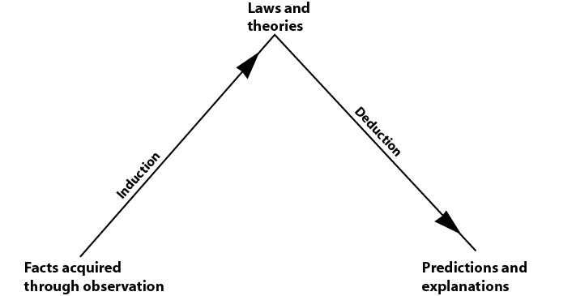

图 2

Figure 2

请考虑以下论证：

Consider the following argument:

1. 相当纯净的水在 0°C 左右结冰（如果给予足够的时间）。

1. Fairly pure water freezes at about 0°C (if given sufficient time).

2. 我的汽车散热器里装的是相当纯净的水。

2. My car radiator contains fairly pure water.

3. 如果温度远低于 0°C，我的汽车散热器中的水就会结冰（如果时间足够长的话）。

3. If the temperature falls well below 0°C, the water in my car radiator will freeze (if given sufficient time).

这里我们举了一个有效的逻辑论证示例，该论证可以从前提1所包含的科学知识推导出预测3。如果1和2为真，那么3必然为真。然而，1、2或3的真假并非通过此推论或其他任何推论来确立。对于归纳主义者而言，科学真理的来源是经验而非逻辑。根据这种观点，1可以通过直接观察各种水结冰的实例来确定。一旦通过观察和归纳证实了1和2，那么就可以从中推导出预测3。

Here we have an example of a valid logical argument to deduce the prediction 3 from the scientific knowledge contained in premise 1. If 1 and 2 are true, 3 must be true. However, the truth of 1, 2 or 3 is not established by this or any other deduction. For the inductivist the source of scientific truth is experience not logic. On this view, 1 will be ascertained by direct observation of various instances of freezing water. Once 1 and 2 have been established by observation and induction, then the prediction 3 can be deduced from them.

不那么简单的例子会更复杂，但观察、归纳和演绎所起的作用本质上仍然相同。最后，我将探讨归纳法如何解释物理科学对彩虹的解释。

Less trivial examples will be more complicated, but the roles played by observation, induction and deduction remain essentially the same. As a final example, I will consider the inductivist account of how physical science is able to explain the rainbow.

前例中的简单前提1在此被一系列支配光行为的定律所取代，即光的反射定律和折射定律，以及关于折射量与光颜色之间关系的论断。这些普遍定律需要通过归纳法从经验中推导出来。大量的实验室实验，例如让光线从镜面和水面反射，测量光线从空气到水、从水到空气等各种路径的折射角，并在各种不同的条件下进行实验，直到满足所有被认为能够从实验结果中归纳推导出光学定律的必要条件为止。

The simple premise 1 of the previous example is here replaced by a number of laws governing the behaviour of light, namely, the laws of reflection and refraction of light and assertions about the dependence of the amount of refraction on the colour of the light. These general laws are to be derived from experience by induction. A large number of laboratory experiments are performed, reflecting rays of light from mirrors and water surfaces, measuring angles of refraction for rays of light passing from air to water, water to air and so on, under a wide variety of circumstances, until whatever conditions are presumed to be necessary to warrant the inductive derivation of the laws of optics from the experimental results are satisfied.

我们前一个例子中的前提2也将被替换为一组更复杂的陈述。这些陈述将包括这样的断言：太阳相对于地球上的观察者位于天空中的某个特定位置，以及雨滴正从相对于观察者位于某个特定区域的云层中落下。这类描述所研究装置的陈述集合将被称为初始条件。实验装置的描述就是典型的初始条件。

Premise 2 of our previous example will also be replaced by a more complex array of statements. These will include assertions to the effect that the sun is situated in some specified position in the sky relative to an observer on earth, and that raindrops are falling from a cloud situated in some specified region relative to the observer. Sets of statements like these, which describe the set-up under investigation, will be referred to as initial conditions. Descriptions of experimental set-ups will be typical initial conditions.

根据光学定律和初始条件，现在可以进行推导，从而解释观察者可见的彩虹的形成。这些推导不再像之前的例子那样显而易见，而是需要数学和文字论证。推导过程大致如下。假设雨滴近似球形，那么光线穿过雨滴的路径大致如图3所示。对于一束来自太阳的白光，当其入射到雨滴的a点时，根据折射定律，红光将沿ab传播，蓝光将沿ab₁传播。反射定律要求ab沿bc反射，ab₁沿b₁c₁反射。c点和c₁点的折射同样由折射定律决定，因此观察者在观察雨滴时会看到白光中的红光和蓝光成分分离（以及光谱中的所有其他颜色）。对于天空中任何一滴雨滴，只要它与太阳的连线与雨滴到观察者的连线之间的夹角为D ，观察者就能看到同样的颜色分离效果。几何学原理表明，只要雨云足够大，观察者就能看到一道彩色弧线。

Given the laws of optics and the initial conditions, it is now possible to perform deductions yielding an explanation of the formation of a rainbow visible to the observer. These deductions will no longer be as self-evident as in our previous examples, and will involve mathematical as well as verbal arguments. The derivation will run roughly as follows. If we assume a raindrop to be roughly spherical, then the path of a ray of light through a raindrop will be roughly as depicted in Figure 3. For a ray of white light from the sun incident on a raindrop at a, the red light will travel along ab and the blue light along ab1 according to the law of refraction. The law of reflection requires that ab be reflected along bc and ab1 along b1c1. Refraction at c and c1 will again be determined by the law of refraction, so that an observer viewing the raindrop will see the red and blue components of the white light separated (and also all the other colours of the spectrum). The same separation of colours will be visible to our observer for any raindrop that is situated in a region of the sky such that the line joining the raindrop to the sun makes an angle D with the line joining the raindrop to the observer. Geometrical considerations yield the conclusion that a coloured arc will be visible to the observer provided the rain cloud is sufficiently extended.

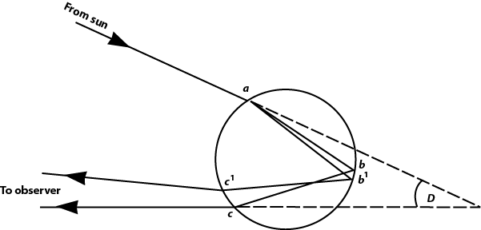

图 3

Figure 3

我在这里只是对彩虹的解释做了简要概述，但这足以说明其中涉及的推理的一般形式。假设光学定律是正确的（对于非专业归纳主义者来说，这可以通过归纳观察来证明），并且假设初始条件描述正确，那么彩虹的解释就必然成立。所有科学解释和预测的一般形式可以概括如下：

I have only sketched an explanation of the rainbow here, but it should suffice to illustrate the general form of the reasoning involved. Given that the laws of optics are true (and for the unqualified inductivist this can be established from observation by induction), and given that the initial conditions are correctly described, then the explanation of the rainbow necessarily follows. The general form of all scientific explanations and predictions can be summarised thus:

1. 定律和理论

1. Laws and theories

2. 初始条件

2. Initial conditions

3. 预测和解释

3. Predictions and explanations

这是图 2 右侧所示的步骤。

This is the step depicted on the right-hand side of Figure 2.

基本的归纳主义科学理论确实具有一定的吸引力。它的吸引力在于，它似乎以一种形式化的方式捕捉到了人们对科学知识特殊属性的一些普遍直觉，即科学知识的客观性、可靠性和实用性。在本节中，我们已经讨论了归纳主义对科学实用性的解释，因为它有助于预测和解释。

The basic inductivist account of science does have some immediate appeal. Its attraction lies in the fact that it does seem to capture in a formal way some of the commonly held intuitions about the special characteristics of scientific knowledge, namely, its objectivity, its reliability and its usefulness. We have discussed the inductivist account of the usefulness of science insofar as it can facilitate predictions and explanations already in this section.

归纳主义者对科学客观性的理解源于观察、归纳和演绎本身所被视为的客观程度。可观察的事实被认为是通过不带偏见地运用感官而确立的，这种方式不容许主观意见的介入。就归纳和演绎推理而言，它们的有效性取决于它们是否符合公开制定的有效性标准，因此，再次强调，个人意见没有立足之地。推论要么符合客观标准，要么不符合。

The objectivity of science as construed by the inductivist derives from the extent to which observation, induction and deduction are themselves seen as objective. Observable facts are understood to be established by an unprejudiced use of the senses in a way that leaves no room for subjective opinion to intrude. As far as inductive and deductive reasoning are concerned, these are adequate to the extent that they conform to publicly formulated criteria of adequacy, so, once again, there is no room for personal opinion. Inferences either conform to the objective standards or they don’t.

科学的可靠性源于归纳主义者关于观察以及归纳推理和演绎推理的主张。根据纯粹的归纳主义者的观点，构成科学事实基础的观察陈述可以通过仔细运用感官直接可靠地确立。此外，只要满足充分归纳概括的条件，这种可靠性也会传递到从这些事实归纳推导出的规律和理论。这由归纳原则保证，而归纳原则被认为是科学的基础。

The reliability of science follows from the inductivist’s claims about observation and both inductive and deductive reasoning. According to the unqualified inductivist, observation statements that form the factual basis for science can be securely established directly by careful use of the senses. Further, this security will be transmitted to the laws and theories inductively derived from those facts provided the conditions for adequate inductive generalisations are met. This is guaranteed by the principle of induction which is presumed to form the basis of science.

尽管归纳主义立场看似很有吸引力，但我们已经看到，它充其量需要进行严格的限定，最坏的情况是，它完全不适用。我们已经看到，足以用于科学的事实绝非唾手可得，而是需要通过实践构建，在某些重要意义上依赖于它们所预设的知识（图2的示意图忽略了这一复杂性），并且这些事实本身也需要改进和更新。更严重的是，我们一直无法对归纳法给出精确的定义，从而区分基于事实的合理概括和仓促或草率的概括。考虑到自然界不断带来惊喜的能力（例如过冷液体可以逆流而上），这无疑是一项艰巨的任务。

Attractive as it may have appeared, we have seen that the inductivist position is, at best, in need of severe qualification and, at worst, thoroughly inadequate. We have seen that facts adequate for science are by no means straightforwardly given but have to be practically constructed, are in some important senses dependent on the knowledge that they presuppose, a complication overlooked in the schematisation in Figure 2, and are subject to improvement and replacement. More seriously, we have been unable to give a precise specification of induction in a way that will help distinguish a justifiable generalisation from the facts from a hasty or rash one, a formidable task given nature’s capacity to surprise, epitomised in the discovery that supercooled liquids can flow uphill.

第十二章我们将探讨一些近期试图挽救归纳主义科学理论困境的尝试。同时，在接下来的两章中，我们将转向一位哲学家，他试图通过提出一种不涉及归纳的科学观来规避归纳法的问题。

In chapter 12 we will discuss some recent attempts to rescue the inductivist account of science from its difficulties. Meanwhile, we will turn in the next two chapters to a philosopher who attempts to sidestep problems with induction by putting forward a view of science that does not involve induction.

延伸阅读

Further reading

休谟归纳问题的历史渊源可追溯至休谟的《人性论》（1939，第三部分）。另一部经典论述见于罗素（1912，第六章）。斯托夫（1973）对休谟论证的后果进行了全面而深入的技术性考察。波普尔声称已解决了归纳问题，相关论述见于波普尔（1979，第一章）。亨佩尔（1966）和萨尔蒙（1966）对归纳推理的阐述较为易懂，而格莱穆尔（1980）则提供了更为详尽的论述。拉卡托斯（1968）的论文集也值得一提，其中收录了拉卡托斯本人撰写的一篇颇具启发性的论文，探讨了构建归纳逻辑的各种尝试。穆斯格雷夫（1993）对该问题进行了优秀的历史回顾。

The historical source of Hume’s problem of induction is Hume’s Treatise on Human Nature (1939, Part 3). Another classic discussion of the problem is Russell (1912, chapter 6). A thorough, technical investigation of the consequences of Hume’s argument is Stove (1973). Karl Popper’s claim to have solved the problem of induction is in Popper (1979, chapter 1). Reasonably accessible accounts of inductive reasoning can be found in Hempel (1966) and Salmon (1966), and a more detailed treatment is found in Glymour (1980). See also Lakatos (1968) for a collection of essays, including a provocative survey by Lakatos himself, of attempts to construct an inductive logic. Musgrave (1993) is a good historical survey of the problem.

第五章

CHAPTER 5

引入证伪主义

Introducing falsificationism

介绍

Introduction

Karl Popper was the most forceful advocate of an alternative to inductivism that I will refer to as ‘falsificationism’. Popper was educated in Vienna in the 1920s, at a time when logical positivism was being articulated by a group of philosophers who became known as the Vienna Circle. One of the most famous of these was Rudolph Carnap, and the clash and debate between his supporters and those of Popper was to be a feature of philosophy of science up until the 1960s. Popper himself tells the story of how he became disenchanted with the idea that science is special because it can be derived from the facts, the more facts the better. He became suspicious of the way in which he saw Freudians and Marxists supporting their theories by interpreting a wide range of instances, of human behaviour or historical change respectively, in terms of their theory and claiming them to be supported on this account. It seemed to Popper that these theories could never go wrong because they were sufficiently flexible to accommodate any instances of human behaviour or historical change as compatible with their theory. Consequently, although giving the appearance of being powerful theories confirmed by a wide range of facts, they could in fact explain nothing because they could rule out nothing. Popper compared this with a famous test of Einstein’s theory of general relativity carried out by Eddington in 1919. Einstein’s theory had the implication that rays of light should bend as they pass close to massive objects such as the sun. As a consequence, a star situated beyond the sun should appear displaced from the direction in which it would be observed in the absence of this bending. Eddington sought for this displacement by sighting the star at a time when the light from the sun was blocked out by an eclipse. It transpired that the displacement was observed and Einstein’s theory was borne out. But Popper makes the point that it might not have been. By making a specific, testable prediction the general theory of relativity was at risk. It ruled out observations that clashed with that prediction. Popper drew the moral that genuine scientific theories, by making definite predictions, rule out a range of observable states of affairs in a way that he considered Freudian and Marxist theory failed to do. He arrived at his key idea that scientific theories are falsifiable.

证伪主义者坦然承认，观察受理论指导并以其为前提。他们也乐于放弃任何暗示理论可以根据观察证据被证实为真或可能为真的论断。理论被视为人类智力自由创造的推测性、试探性的猜想或推测，旨在克服先前理论遇到的问题，从而对世界或宇宙的某些方面做出充分的解释。一旦提出，推测性理论就必须通过观察和实验进行严格而无情的检验。经不起观察和实验检验的理论必须被摒弃，并由新的推测性猜想取而代之。科学的进步是通过反复试验、提出猜想和反驳来实现的。只有最合适的理论才能生存下来。虽然我们永远无法真正断言某个理论是正确的，但我们可以乐观地说，它是目前最好的理论；它优于以往任何理论。对于证伪主义者来说，归纳法的特征和正当性方面不存在任何问题，因为在他们看来，科学不涉及归纳法。

Falsificationists freely admit that observation is guided by and presupposes theory. They are also happy to abandon any claim implying that theories can be established as true or probably true in the light of observational evidence. Theories are construed as speculative and tentative conjectures or guesses freely created by the human intellect in an attempt to overcome problems encountered by previous theories to give an adequate account of some aspects of the world or universe. Once proposed, speculative theories are to be rigorously and ruthlessly tested by observation and experiment. Theories that fail to stand up to observational and experimental tests must be eliminated and replaced by further speculative conjectures. Science progresses by trial and error, by conjectures and refutations. Only the fittest theories survive. Although it can never be legitimately said of a theory that it is true, it can hopefully be said that it is the best available; that it is better than anything that has come before. No problems about the charactisation and justification of induction arises for the falsificationists because, according to them, science does not involve induction.

本文对证伪主义的简要概述内容将在接下来的两章中进行补充。

The content of this condensed summary of falsificationism will be filled out in the next two chapters.

支持证伪主义的一个逻辑论点

A logical point in favour of falsificationism

根据证伪主义，某些理论可以通过诉诸观察和实验结果来证明其错误。这里有一个简单而合乎逻辑的论点似乎支持证伪主义者的观点。我在第四章已经指出，即使我们假设能够以某种方式获得真实的观察陈述，也永远不可能仅凭此进行逻辑演绎来得出普遍规律和理论。然而，我们可以从个别的观察陈述出发，进行逻辑演绎，从而得出普遍规律和理论的错误结论。例如，如果我们得到这样的陈述：“在时间t ，在地点x观察到一只不是黑色的渡鸦”，那么由此逻辑地可以得出“所有渡鸦都是黑色的”是错误的。也就是说，论证如下：

According to falsificationism, some theories can be shown to be false by an appeal to the results of observation and experiment. There is a simple, logical point that seems to support the falsificationist here. I have already indicated in chapter 4 that, even if we assume that true observational statements are available to us in some way, it is never possible to arrive at universal laws and theories by logical deductions on that basis alone. However, it is possible to perform logical deductions starting from singular observation statements as premises, to arrive at the falsity of universal laws and theories by logical deduction. For example, if we are given the statement, ‘A raven which was not black was observed at place x at time t’, then it logically follows from this that ‘All ravens are black’ is false. That is, the argument:

前提——一只不是黑色的渡鸦在时间t位于地点x。

Premise – A raven, which was not black, was at place x at time t.

结论——并非所有的渡鸦都是黑色的。

Conclusion – Not all ravens are black.

这是一个逻辑上有效的推论。如果前提成立而结论不成立，则会产生矛盾。再举一两个例子有助于说明这个看似简单的逻辑要点。如果通过观察某个实验证明，一个十公斤的物体和一个一公斤的物体在自由落体运动中下落的速度大致相同，那么就可以得出结论：物体下落的速度与其重量成正比的说法是错误的。如果能够毫无疑问地证明，一束光线经过太阳附近时会发生偏转，那么就不能断言光必然沿直线传播。

is a logically valid deduction. If the premise is asserted and the conclusion denied, a contradiction is involved. One or two more examples will help illustrate this fairly trivial logical point. If it can be established by observation in some test experiment that a ten-kilogram weight and a one-kilogram weight in free fall move downwards at roughly the same speed, then it can be concluded that the claim that bodies fall at speeds proportional to their weight is false. If it can be demonstrated beyond doubt that a ray of light passing close to the sun is deflected in a curved path, then it is not the case that light necessarily travels in straight lines.

普遍命题的虚假性可以从适当的个别命题推导出来。证伪主义者充分利用了这一逻辑要点。

The falsity of universal statements can be deduced from suitable singular statements. The falsificationist exploits this logical point to the full.

可证伪性作为理论的标准

Falsifiability as a criterion for theories

证伪主义者将科学视为一系列假设的集合，这些假设被初步提出，旨在准确描述或解释世界或宇宙某些方面的运行规律。然而，并非任何假设都能胜任。任何假设或假设体系若要被赋予科学定律或理论的地位，都必须满足一个基本条件：可证伪性。在进一步探讨之前，有必要明确证伪主义者对“可证伪性”一词的用法。